# The Computer Music Tutorial.Roads2023.2e.p1

[figure not shown]

柯蒂斯路

Curtis Roads

**电脑音乐教程**

**The Computer Music Tutorial**

**第二版**

**SECOND EDITION**

麻省理工学院出版社

The MIT Press

马萨诸塞州剑桥

Cambridge, Massachusetts

英国伦敦

London, England

© 2023 麻省理工学院

© 2023 Massachusetts Institute of Technology

保留所有权利。未经出版商书面许可，不得以任何电子或机械方式（包括影印、录制或信息存储和检索）复制本书的任何部分。

All rights reserved. No part of this book may be reproduced in any form by any electronic or mechanical means (including photocopying, recording, or information storage and retrieval) without permission in writing from the publisher.

麻省理工学院出版社谨此感谢为本书草稿提供意见的匿名同行评审专家。学术专家的慷慨贡献对于我们出版物的权威性和质量至关重要。我们衷心感谢这些未署名读者的贡献。

The MIT Press would like to thank the anonymous peer reviewers who provided comments on drafts of this book. The generous work of academic experts is essential for establishing the authority and quality of our publications. We acknowledge with gratitude the contributions of these otherwise uncredited readers.

美国国会图书馆出版编目数据

Library of Congress Cataloging-in-Publication Data

姓名：Roads，Curtis，作家。

Names: Roads, Curtis, author.

标题：计算机音乐教程/柯蒂斯·罗兹 (Curtis Roads)。

Title: The computer music tutorial / Curtis Roads.

描述：第二版。| 马萨诸塞州剑桥：麻省理工学院出版社，2023 年。| 包括参考书目和索引。

Description: Second edition. | Cambridge, Massachusetts : The MIT Press, 2023. | Includes bibliographical references and index.

标识符：LCCN 2022003353（打印）| LCCN 2022003354（电子书）| ISBN 9780262044912（精装本）| ISBN 9780262361545 (epub) | ISBN 9780262361538 (pdf)

Identifiers: LCCN 2022003353 (print) | LCCN 2022003354 (ebook) | ISBN 9780262044912 (hardcover) | ISBN 9780262361545 (epub) | ISBN 9780262361538 (pdf)

主题：LCSH：计算机音乐——教学与学习。| 计算机声音处理。| 软件合成器。| 计算机作曲（音乐）

Subjects: LCSH: Computer music—Instruction and study. | Computer sound processing. | Software synthesizers. | Computer composition (Music)

分类：LCC MT56 .R6 2023（印刷版）| LCC MT56（电子书）| DDC 780.285—dc23

Classification: LCC MT56 .R6 2023 (print) | LCC MT56 (ebook) | DDC 780.285—dc23

LC 记录可在[https:// lccn .loc .gov /2022003353上查看](https://lccn.loc.gov/2022003353)

LC record available at https://lccn.loc.gov/2022003353

LC 电子书记录可在[https:// lccn .loc .gov /2022003354获取](https://lccn.loc.gov/2022003354)

LC ebook record available at https://lccn.loc.gov/2022003354

出版物由以下机构资助

publication supported by a grant from

大纽黑文社区基金会

The Community Foundation for Greater New Haven

**作为城市避风港项目**的一部分

as part of the **Urban Haven Project**

# **前言：新音乐与科学**

# **Foreword: New Music and Science**

随着计算机和数字设备的使用，音乐创作和制作过程与社会科技资源的交织程度比以往任何时候都更加紧密。通过广泛应用计算机来生成和处理声音，以及从微观形式到宏观形式的音乐创作，作曲家们出于创作的需要，在科学思想领域和音乐思想领域之间建立了牢固的相互依存关系。科学技术不仅丰富了当代音乐，反之亦然：在某些情况下，具有特殊音乐重要性的问题也会直接暗示或引发具有科学技术重要性的问题。音乐和科学各有其动机，它们相互依存，并由此建立了一种独特的互利关系。

With the use of computers and digital devices, the processes of music composition and its production have become intertwined with the scientific and technical resources of society to a greater extent than ever before. Through extensive application of computers in the generation and processing of sound and the composition of music from levels of the microformal to the macroformal, composers, from creative necessity, have provoked a robust interdependence between domains of scientific and musical thought. Not only have science and technology enriched contemporary music, but the converse is also true: problems of particular musical importance in some cases suggest or pose directly problems of scientific and technological importance, as well. Each having its own motivations, music and science depend on one another and in so doing define a unique relationship to their mutual benefit.

技术在音乐中的运用并非新鲜事；然而，随着计算机系统的快速发展，其应用已达到新的高度。现代计算机系统涵盖的概念远远超出了物理机器本身固有的概念。计算的显著属性之一是可编程性，因此也需要编程语言。高级编程语言代表了几个世纪以来关于思维的思考，是计算机应用于不同学科的手段。

The use of technology in music is not new; however, it has reached a new level of pertinence with the rapid development of computer systems. Modern computer systems encompass concepts that extend far beyond those that are intrinsic to the physical machines themselves. One of the distinctive attributes of computing is programmability and hence programming languages. High-level programming languages, representing centuries of thought about thinking, are the means by which computers become accessible to diverse disciplines.

编程涉及心理过程和对细节的严格关注，与作曲并无二致。因此，作曲家是第一批真正运用计算机的艺术家也就不足为奇了。将一些基本的科学知识和概念融入音乐意识，并在看似与音乐无关的领域获得能力，有着令人信服的理由。有两个理由尤其令人信服：(1) 计算机声音合成的通用性；(2) 编程在音乐结构和作曲过程中的强大功能。

Programming involves mental processes and rigorous attention to detail not unlike those involved in composition. Thus, it is not surprising that composers were the first artists to make substantive use of computers. There were compelling reasons to integrate some essential scientific knowledge and concepts into the musical consciousness and to gain competence in areas which are seemingly foreign to music. Two reasons were (and are) particularly compelling: (1) the generality of sound synthesis by computer, and (2) the power of programming in relation to the musical structure and the process of composition.

## **声音合成**

## **Sound Synthesis**

虽然传统乐器确实构成了丰富的声音空间，但作曲家们的想象力已经几十年没有尝试过通过对自然界中发现的声音进行内插和外推来创造声音，而这些声音是声学或模拟电子乐器无法实现的。由计算机控制的扬声器是现存最通用的合成媒介。任何可以通过扬声器发出的声音，从最简单的到最复杂的，都可以用这种媒介合成。计算机合成的这种通用性意味着一个异常庞大的声音空间，这对作曲家来说有着明显的吸引力。原因是计算机声音合成是连接想象和听觉的桥梁。

Although the traditional musical instruments constitute a rich sound space indeed, it has been many decades since composers’ imaginations have conjured up sounds based on the interpolation and extrapolation of those found in nature but that are not realizable with acoustical or analog electronic instruments. A loudspeaker controlled by a computer is the most general synthesis medium in existence. Any sound, from the simplest to the most complex, that can be produced through a loudspeaker can be synthesized with this medium. This generality of computer synthesis implies an extraordinarily larger sound space, which has an obvious attraction to composers. The reason is that computer sound synthesis is the bridge between that which can be imagined and that which can be heard.

尽管媒介对声音制作的限制已经消除，但作曲家要想充分发挥其潜力，仍然需要克服巨大的障碍。这个障碍就是知识的缺乏——作曲家需要能够有效地指导计算机进行合成过程的知识。在某种程度上，这些技术知识与计算机相关；这很容易获得。但它主要与声音的物理描述和感知关联有关。奇怪的是，所需的知识大多并不存在于人们最期望找到它的科学研究领域，即物理声学和心理生物学；这些学科往往在作曲家最终最关心的细节层面上提供不精确的数据，甚至没有数据。过去，人们试图复制自然声音，并利用科学数据和结论来获取有关声音的一般信息。音乐家和音乐家科学家很快指出，大多数结论和数据都是不够的。要合成出在听觉复杂度上接近最简单的自然声音的声音，需要详细了解声音各个组成部分随时间的变化。

With the elimination of constraints imposed by the medium on sound production, there nonetheless remains an enormous barrier that the composer must overcome in order to make use of this potential. That barrier is the lack of knowledge—the knowledge required for the composer to be able to effectively instruct the computer in the synthesis process. To some extent this technical knowledge relates to computers; this is rather easily acquired. But it mostly has to do with the physical description and perceptual correlates of sound. Curiously, the knowledge required does not exist, for the most part, in those areas of scientific inquiry where one would most expect to find it, that is, physical acoustics and psychobiology; these disciplines tend to provide either inexact or no data at those levels of detail with which a composer is ultimately most concerned. In the past, scientific data and conclusions were used in attempts to replicate natural sounds as a way of gaining information about sound in general. Musicians and musician-scientists were quick to point out that most of the conclusions and data were insufficient. The synthesis of sounds that approach in aural complexity the simplest natural sound demands detailed knowledge about the temporal evolution of the various components of the sound.

然而，物理学、心理学、计算机科学和数学提供了强大的工具和概念。当这些概念与音乐知识和听觉感知相结合时，音乐家、科学家和技术人员能够携手合作，创造出新的概念，并在细节层面上对声音进行物理和心理物理描述，帮助作曲家满足听觉和想象力的严格要求。

Physics, psychology, computer science, and mathematics have, however, provided powerful tools and concepts. When these concepts are integrated with musical knowledge and aural sensitivity, they allow musicians, scientists, and technicians, working together, to carve out new concepts and physical and psychophysical descriptions of sound at levels of detail that are of use to the composer in meeting the exacting requirements of the ear and imagination.

正如本书所示，已经出现了一些成果：人们对音色有了更深入的理解，作曲家的声音调色板也更加丰富新的高效合成技术已经被发现和开发，这些技术基于对声音感知属性而非物理属性的建模；强大的程序已经开发出来，用于编辑和混合合成和/或数字录制的声音；感知融合实验已经引发了声源识别和听觉图像方面新颖且具有音乐意义的研究；最后，专用计算机合成器正在设计和构建中。这些实时性能系统融合了许多知识和技术的进步。

As this book shows, some results have emerged: there is a much deeper understanding of timbre, and composers have a much richer sound palette with which to work; new efficient synthesis techniques have been discovered and developed that are based on modeling the perceptual attributes of sound rather than the physical attributes; powerful programs have been developed for the purposes of editing and mixing synthesized and/or digitally recorded sound; experiments in perceptual fusion have led to novel and musically useful research in sound source identification and auditory images; and finally, special-purpose computer-synthesizers are being designed and built. These real-time performance systems incorporate many advances in knowledge and technique.

## **编程与创作**

## **Programming and Composition**

由于设计计算机编程语言的基本假设之一是通用性，任何高级语言的实际应用范围都非常广泛，显然也包括音乐。人们用各种各样的编程语言编写了各种音乐程序。其中最有用、作曲家积累最多经验的是用于合成和处理声音的程序，以及将一段音乐的音乐规范转化为合成程序所需的物理规范的程序。

Because one of the fundamental assumptions in designing a computer programming language is generality, the range of practical applications of any given high-level language is enormous and obviously includes music. Programs have been written in a variety of programming languages for various musical purposes. Those that have been most useful and with which composers have gained the most experience are programs for the synthesis and processing of sound and programs that translate musical specifications of a piece of music into physical specifications required by the synthesis program.

掌握一定的编程能力对作曲家来说意义非凡，因为它是全面理解计算机系统的关键。尽管系统由极其复杂的程序组成，并且使用非专业人士难以掌握的技术编写而成，但编程能力能够使作曲家理解系统的整体工作原理，并达到有效使用系统所需的程度。编程能力还赋予作曲家在最需要独立性的计算层面——合成——上一定的独立性。与传统管弦乐编曲类似，在音色和微发音方面，音调的合成选择通常具有高度的主观性。作曲家能够自由地修改合成算法，从而大大增强了这一过程的效率。

The gaining of some competence at programming can be rewarding to a composer because it is the key to a general understanding of computer systems. Although systems are composed of programs of great complexity and written using techniques not easily learned by nonspecialists, programming ability enables the composer to understand the overall workings of a system to the extent required for its effective use. Programming ability also gives the composer a certain independence at those levels of computing in which independence is most desirable: synthesis. Similar to the case in traditional orchestration, the choices made in the synthesis of tones, having to do with timbre and microarticulation, are often highly subjective. The process is greatly enhanced by the ability of the composer to alter synthesis algorithms freely.

音乐结构的编程是编程能力能够提供的另一个机会。只要作曲过程能够以或多或少精确的方式表述出来，它们就可以以程序的形式实现。例如，基于某种迭代过程的音乐结构，或许可以通过编程的方式得到恰当的实现。

The programming of musical structure is another opportunity that programming competence can provide. To the extent that compositional processes can be formulated in a more or less precise manner, they may be implemented in the form of a program. A musical structure that is based upon some iterative process, for example, might be appropriately realized by means of programming.

但是，编程能力的影响并不那么明显，这种影响来自于编写者与编程语言概念的接触。而程序所要执行的功能可能会影响程序语言的选择也会影响程序功能的构思。更广义地说，编程概念可以暗示一些在编程环境之外的人可能无法想到的功能。这在音乐创作中至关重要，因为将编程概念融入音乐想象可以拓展想象力本身的边界。也就是说，语言不仅仅是一个可以用来完成某些预设任务或功能的工具；它也是一个与想象力互动的广泛的结构基础。虽然计算机声音合成涉及源自自然声音分析的物理和心理物理概念，但当与更高层次的音乐结构编程相结合时，其含义远远超出了音色。与传统乐器作曲中乐器振动模式关系在很大程度上不受作曲影响的情况不同，计算机合成允许创作音乐的微观结构。

But there is a less tangible effect of programming competence that results from the contact of the composer with the concepts of a programming language. Whereas the function that a program is to perform can influence the choice of language in which the program is written, it is also true that a programming language can influence the conception of a program’s function. In a more general sense, programming concepts can suggest functions that might not occur to one outside of the context of programming. This is of signal importance in music composition, because the integration of programming concepts into the musical imagination can extend the boundaries of the imagination itself. That is, the language is not simply a tool with which some preconceived task or function can be accomplished; it is an extensive basis of structure with which the imagination can interact, as well. Although computer synthesis of sound involves physical and psychophysical concepts derived from the analysis of natural sounds, when joined with higher-level programming of musical structure the implications extend far beyond timbre. Unlike the condition that exists in composition for traditional instruments under which the relation of vibrational modes of an instrument is largely beyond compositional influence, computer synthesis allows for the composition of music’s microstructure.

因此，在计算的语境下，音乐的微观结构并非必然具有预先确定的形式，即与特定乐器的特定演奏方式相关联。相反，它可以像作品的其他方面一样，受制于相同的思维过程，并由作曲家自由地在想象中决定。

In the context of computing, then, the microstructure of music is not necessarily of predetermined form, that is, associated with a specific articulation of a particular instrument. Rather, it can be subjected to the same thought processes and be as freely determined in the imagination of the composer as every other aspect of the work.

约翰·乔宁

John Chowning

# **第二版前言**

# **Preface to the Second Edition**

这是*《计算机音乐教程》第二版。1979*年，当我们第一次向麻省理工学院出版社提交*《计算机音乐教程》*的书籍提案时，我是*《计算机音乐杂志》*的编辑。之前的三位编辑和我一起参与了这项提案。John Snell 是一位音乐硬件工程师，Curtis Abbott 和 John M. Strawn 是数字信号处理专家。当时我的研究兴趣围绕算法作曲和颗粒合成。我们的总体计划是根据每位作者的兴趣和专业知识来划分主题。然而，这个项目的进展比预期的要慢，到 1983 年，我的合伙人由于更好的机会而退出了。我面临着学习我不熟悉的研究领域。经过一段时间的全职工作后，我于 1993 年在巴黎完成了手稿。

Here is *The Computer Music Tutorial, Second Edition.* When we first submitted a book proposal for *The Computer Music Tutorial* to the MIT Press in 1979, I was editor of *Computer Music Journal*. Three previous editors joined me in this proposal. John Snell was a music hardware engineer, and Curtis Abbott and John M. Strawn were digital signal processing mavens. My research interests at the time revolved around algorithmic composition and granular synthesis. Our general plan had been to divide up the subject matter according to each author’s interests and expertise. However, the project went slower than expected, and by 1983, my partners had dropped out due to better opportunities. I was faced with learning about areas of research that were unfamiliar to me. After a sustained period during which I was also working full time, I finished the manuscript in Paris in 1993.

这本书的制作过程漫长，直到1996年才出版。我原计划出版三卷本，但麻省理工学院出版社却偏向于单卷。书的大小和重量虽然不影响销量，但确实是一个实际问题。书的出版范围体现了我对广度的坚持。我认为，重要的是要涵盖该领域的多个方向，而不是像某些人和机构所青睐的那样，只局限于少数几个方向。

The production process was long, and the book did not appear until 1996. I planned the original as a three-volume set; however, The MIT Press favored a single volume. The size and weight of the book was a practical problem, although it did not deter sales. The scope reflected my insistence on breadth. I felt it important to represent many directions of the field and not just a select few, as favored by certain people and institutions.

我一直对电子音乐和计算机音乐的传承很感兴趣，所以第一版的一大主线就是该领域的历史。这种历史研究本身就是一项重大的探索，贯穿了本书的始终。

I have always been interested in the legacy of electronic and computer music, so a strong thread of the first edition was the history of the field. This historical scholarship was a major endeavor in itself and runs throughout the text.

后来，在杜诺出版的法文版中，我的同事让·德·雷德莱（Jean de Reydellet）建议将本书分成多个短章节，使其更具逻辑性（《道路》1998）。我们在第二版和第三版法文版中也采用了这种组织方式（《道路》2007年、2016年）。本书也采用了类似的组织方式。

Later, for the French edition published by Dunod, my colleague Jean de Reydellet suggested a more logical organization into many short chapters (Roads 1998). We used this organization in the second and third French editions (Roads 2007, 2016). I have adopted a similar organization here.

许多章节可以独立阅读。然而，在某些情况下，先阅读其他章节会有所帮助。相关章节会提及这一点。

Many chapters can be read independently of one another. However, in certain cases it is helpful to read one before another. This is mentioned in the relevant chapters.

## **发布背景**

## **Publishing Context**

在本修订版中，读者将发现新增章节以及基于最新研究的大量更新。在某些情况下，有必要根据原版出版以来发生的所有事件重新构建讨论。

In this revised edition, the reader will find new chapters and also extensive updates based on recent research. In certain cases, it was necessary to reframe the discussion in the light of all that has transpired since the original edition was published.

电子音乐和计算机音乐正在迅速发展。该领域正乘着科技创新的浪潮。更快的处理器和网络、更优质的显示器以及更智能的控制器都已崭露头角。音频设备的改进推动了该领域的发展。这些都为软件创新奠定了硬件基础。如今，成千上万的公司竞相为音乐家提供产品。

Electronic and computer music is developing rapidly. The field rides waves of technological innovation. Faster processors and networks, better displays, and clever controllers have all made their mark. Improvements in audio equipment advance the field. These create a hardware foundation for innovations in software. Today, thousands of companies compete to deliver products to musicians.

然而，许多基本原理并未改变。几十年前的复古设备和精心保存的软件，在今天听起来依然美妙绝伦。支配数字信号处理的物理定律是永恒不变的。许多新产品是对古老原理的巧妙改造，并披上了全新的界面。然而，界面的力量不容小觑。新颖的设计可以彻底改变工作方式。数字音频工作站 (DAW) 及其用于编辑和混音的图形时间线界面就是这样一项创新。模块的图形化跳线是另一种创新（例如 Max），实时频谱显示的集成也是如此。模块化 Eurorack 格式激发了合成和控制领域的巨大创造力浪潮。在每一个案例中，一个新的举措都迅速传播并改变了整个领域。

Many fundamentals, however, have not changed. Vintage gear and carefully preserved software from decades past can sound wonderful today. The laws of physics that govern digital signal processing are immutable. Many new products are clever reworkings of ancient principles dressed up in fresh interfaces. Yet the power of an interface is not to be underestimated. A novel design can completely transform the method of working. The digital audio workstation (DAW) with its graphical time line interface for editing and mixing was one such innovation. Graphical patching of modules was another (e.g., Max), as was the integration of real-time spectral displays. The modular Eurorack format inspired a giant wave of creativity in synthesis and control. In each of these cases, a novel step quickly propagated and changed the field.

*《计算机音乐教程》*出版时，是为数不多的几本专门讨论该主题的书籍之一。此后，更多的书籍相继出版。如果我们仅查看麻省理工学院出版社自1996年以来出版的书籍目录，并将其范围缩小到计算机音乐技术书籍，我们会发现一系列扩展了本书所介绍子主题的文本：《*互动音乐创作》、《Microsound》、《音频编程手册》、《CSound手册》、《超级对撞机手册》、《声音设计》、《声波交互设计》、《虚拟音乐》、《音乐认知与计算机化声音》、《音乐创造力的计算机模型》、《Musimathics 1和2》、《超越MIDI》、《音乐查询》、《音乐与概率》*以及*《音乐网络》。*此外，还有数十本来自不同出版商的书籍。

When it was published, *The Computer Music Tutorial* was one of only a handful of books devoted to the subject. Many more books have since been published. If we look solely at the catalog of MIT Press books published since 1996 and narrow it to technical books on computer music, we see a range of texts that expand on subtopics introduced in this volume: *Composing Interactive Music, Microsound, The Audio Programming Book, The Csound Book, The SuperCollider Book, Designing Sound, Sonic Interaction Design, Virtual Music, Music Cognition and Computerized Sound, Computer Models of Musical Creativity, Musimathics 1 and 2, Beyond MIDI, Music Query, Music and Probability,* and *Musical Networks.* Dozens of other books are available from different publishers.

互联网深刻地改变了出版业。如果你知道该寻找什么，互联网就是一个非凡的资源。本书的目标之一就是培养这种好奇心。本书提供了约2000条参考文献，佐证了这些描述。

Publishing has been profoundly transformed by the internet. The internet is an extraordinary resource if you know what to look for. A goal of this text is to foster this curiosity. Some 2,000 references support the descriptions.

## **第二版有哪些新内容？**

## **What Is New in the Second Edition?**

首先，本版包含了一些修正。其次，在广泛查阅文献后，内容进行了彻底更新和重写，使其更加清晰易懂。这包括数百幅新图表和数百个新参考文献。

To begin, this edition incorporates corrections. Second, after an extensive review of the literature, the content has been thoroughly updated and rewritten for greater clarity. This includes hundreds of new figures and hundreds of new references.

新章节包括虚拟模拟、脉冲星合成、连接合成、原子分解频谱分析、开放声音控制、频谱编辑器、仪器和补丁编辑器以及机器学习附录。

New chapters include virtual analog, pulsar synthesis, concatenative synthesis, spectrum analysis by atomic decomposition, Open Sound Control, spectrum editors, instrument and patch editors, and an appendix on machine learning.

新的部分涵盖 MIDI 2.0、钢琴模型、单边带调制、波形折叠、动态卷积、沉浸式声音（VBAP、环境立体声和波场合成）、侧链控制和自适应效果、基于机器学习的加法合成、多通道声音的传输格式、滤波器组和声码器、分形插值合成、扫描合成、数字音频工作站和音频中间件、实时编码和实时符号以及远程音乐。

New sections cover MIDI 2.0, piano models, single-sideband modulation, wavefolding, dynamic convolution, immersive sound (VBAP, ambisonics, and wave field synthesis), sidechain control and adaptive effects, additive synthesis based on machine learning, transmission formats for multichannel sound, filter banks and vocoders, fractal interpolation synthesis, scanned synthesis, digital audio workstations and audio middleware, live coding and live notation, and telematic music.

## **删除或省略的主题**

## **Topics Deleted or Omitted**

原版有一章介绍计算机编程，将其作为一般主题。虽然初衷是好的，但编程很难用一章来概括。许多巨著都深入细致地介绍了编程。当我考虑专门用一章来介绍音频编程时，同样的考虑也发挥了作用。现在有很多书籍专门关注这个主题。例如，*《音频编程手册》*（Boulanger 和 Lazzarini 2011）包含超过 3000 页的文本和数千行代码，包括 Csound、cmusic 和 Music V 的代码清单。每种音频语言都有各自的参考文本。其中包括*《Csound 手册》*（Boulanger 2000）、*《SuperCollider 手册》*（Wilson、Cottle 和 Collins 2011）、*《音乐家和数字艺术家的编程：使用 ChucK 创作音乐》*（Kapur 等人 2015）、*《电子音乐和声音设计，第 1 卷和第 2 卷*》（Max）（Cipriani 和 Giri 2010a、b）、*《电子音乐的理论与技巧》*（PureData）（Puckette 2007）、《*为 Max/MSP 和 Pd 设计音频对象》*（Lyon 2012）、*《Hack Audio》*（MATLAB）（Tarr 2019）和*《Nyquist 参考手册》*（Dannenberg 2018）等。Faust 和 AudioKit 等语言均有在线文档。有一些实用的入门教材，例如*《Linux 声音编程》*（Newmarch 2017）、*《用 C++ 设计音频效果插件》*（Pirkle 2019）和*《用 C++ 设计软件合成器插件》 （Pirkle 2015）。另请参阅**《生成声音与组织时间：用 gen 思考*》（Wakefield 和Taylor 2022）。音频开发者大会是另一个资源，YouTube 上的音频程序员视频频道也是如此。

The original edition had an introductory chapter on computer programming as a general topic. Although it was well-intended, programming is hard to summarize in a chapter. Many tomes cover programming in depth and detail. Identical considerations came into play when I considered a chapter specifically on audio programming. By now many books focus specifically on this topic. For example, *The Audio Programming Book* (Boulanger and Lazzarini 2011) contains over 3,000 pages of text and thousands of lines of code, including code listings for Csound, cmusic, and Music V. Each audio language has its own reference text. Among these are *The Csound Book* (Boulanger 2000), *The SuperCollider Book* (Wilson, Cottle, and Collins 2011), *Programming for Musicians and Digital Artists: Creating Music with ChucK* (Kapur et al. 2015), *Electronic Music and Sound Design, Volumes 1 and 2* (Max) (Cipriani and Giri 2010a, b), *The Theory and Technique of Electronic Music* (PureData) (Puckette 2007), *Designing Audio Objects for Max/MSP and Pd* (Lyon 2012), *Hack Audio* (MATLAB) (Tarr 2019), and *Nyquist Reference Manual* (Dannenberg 2018), among others. Languages such as Faust and AudioKit are documented online. Practical how-to texts such as *Linux Sound Programming* (Newmarch 2017), *Designing Audio Effects Plugins in C++* (Pirkle 2019) and *Designing Software Synthesizer Plugins in C++* (Pirkle 2015) are available. See also *Generating Sound & Organizing Time: Thinking with gen*~ (Wakefield and Taylor 2022). The Audio Developer Conference is another resource, as is the Audio Programmer video channel on YouTube.

因此，我们在第 8 章中对音频编程的介绍仅仅是指向一个大领域的指针。

Thus our presentation of audio programming in chapter 8 is merely a pointer to a large domain.

原版附录中介绍了心理声学，而心理声学并非计算机音乐所特有的主题。其他教材对这一领域进行了更全面的论述（Loy 2006；Howard 和 Angus 2017；Bader 2018）。

The original edition had an appendix on psychoacoustics, a topic that is not specific to computer music. Other texts offer a more comprehensive treatment of this area (Loy 2006; Howard and Angus 2017; Bader 2018).

关于傅里叶分析数学原理的旧附录已经删除，但我将基本信息合并到了第 37 章“傅里叶方法的频谱分析”中。对于那些想要更详细论述的人，Loy (2007) 用一百多页的篇幅讨论了同一主题；Smith (2011) 也提供了近六百页的篇幅。

The old appendix on the mathematics of Fourier analysis is gone, but I merged the essential information into chapter 37, “Spectrum Analysis by Fourier Methods.” For those who want a more extended treatment, Loy (2007) devotes over one hundred pages to the same subject; Smith (2011) offers nearly six hundred pages.

我遗憾地删除了过时的章节“数字信号处理器内部结构”，尤其是历史部分。20世纪七八十年代*数字信号处理*(DSP) 硬件的先驱们，例如 Sydney Alonso、Harold Alles、Peter Samson 和 Giuseppe Di Giugno，都是合成器工程领域的英雄。幸运的是，许多这样的故事在其他地方都有讲述。Joel Chadabe (1997) 讲述了 Synclavier 和其他几个先驱系统的传奇故事。Mark Vail (2000a, b) 回顾了模拟和数字合成的早期发展。Bj ø rn 和 Meyer (2018) 采访了几位模块化合成器开发者。Loy (2013a, b) 从历史角度讲述了 Samson Box 的故事。Giordano (2020) 记录了 Di Giugno 丰富多彩的职业生涯。

I excised the dated chapter “Internals of Digital Signal Processors” with regret, especially the historical section. The pioneers of *digital signal processing* (DSP) hardware in the 1970s and 1980s, such as Sydney Alonso, Harold Alles, Peter Samson, and Giuseppe Di Giugno, were heroes of synthesizer engineering. Fortunately, many of these stories are told elsewhere. Joel Chadabe (1997) tells the saga of the Synclavier and several other pioneering systems. Mark Vail (2000a, b) recounts the early days of analog and digital synthesis. Bjørn and Meyer (2018) interview several modular synthesizer developers. Loy (2013a, b) tells the story of the Samson Box from an historical perspective. Giordano (2020) documents the colorful career of Di Giugno.

如今数字音频硬件的状况截然不同。DSP 芯片广泛应用于音频效果硬件、Yamaha、Roland 等公司的合成器、Eurorack 数字模块以及 Kyma/Pacarana 和 Universal Audio Apollo 接口等独特产品中。然而，如今大多数音频软件运行在标准微处理器上，缺乏 DSP 硬件支持。因此，DSP 架构本身似乎不像 20 世纪 90 年代那样成为本书的核心内容，当时许多个人电脑都配备了专用的 DSP 电路板进行音频处理。

The situation of digital audio hardware today is quite different. DSP chips can be found in audio effects hardware, synthesizers from Yamaha, Roland, and other companies, digital Eurorack modules, and unique products such as the Kyma/Pacarana and the Universal Audio Apollo interfaces. However, most audio software today runs on standard microprocessors without DSP hardware support. Thus the topic of DSP architecture per se did not seem as central to this book as it did in the 1990s, when many personal computers had a dedicated DSP circuit board for audio processing.

讽刺的是，如今的音频计算面临着挑战，因为*中央处理器*(CPU) 的时钟速度早在几年前就停滞不前了 (Asanov í c et al. 2006)。短期解决方案是在 CPU 芯片上添加更多内核，但这对实时音频处理并无益处，因为多核架构并非理想之选 (Thall 2019)。有人预测，即使*图形编程单元*(GPU) 和*张量处理单元*(TPU) 也正在为音频领域部署，音频 DSP 芯片也可能会卷土重来 (Storer 2018; Anderson 2020)。然而，如果这些芯片不能成为标准，其影响力也将有限。时间会证明一切。

Ironically, present-day audio computing faces a challenge, as *central processing unit* (CPU) clock speeds stalled years ago (Asanovíc et al. 2006). The short-term solution, adding more cores to the CPU chip, does not benefit real-time audio processing, which is not ideally suited to multicore architectures (Thall 2019). As a solution, some have predicted that audio DSP chips could make a comeback even as *graphical programming units* (GPUs) and *tensor processing units* (TPUs) are also being deployed for audio (Storer 2018; Anderson 2020). However, if these chips do not become standard, their impact will be limited. Time will tell.

我一度觉得应该写一章关于*音乐信息检索*（MIR）这个广泛领域的综述。幸运的是，有一本教科书叫*《音乐处理基础》*（Müller ， 2015）一书以教程形式涵盖了这一主题。Müller的著作描述了基于分析的应用的具体方法，本书第五部分对此进行了讨论。这些方法包括乐谱跟踪、音乐结构解析、和弦识别、节奏和节拍追踪、基于内容的音频检索、和声-打击乐分离以及旋律追踪。相关网站提供了 Python 示例代码（[https://www.audiolabs-erlangen.de/news/articles/FMP），Lerch（2012](https://www.audiolabs-erlangen.de/news/articles/FMP) [）](https://www.audiolabs-erlangen.de/news/articles/FMP)也涵盖了相关主题。另请参阅 Polotti 和 Rocchesso（2008）的著作[。](https://www.audiolabs-erlangen.de/news/articles/FMP)

At one point I thought it would be useful to have a survey chapter on the broad area of *music information retrieval* (MIR). Fortunately, a textbook called *Fundamentals of Music Processing* (Müller 2015) appeared, which covers this topic in a tutorial manner. Müller’s book describes specific methods for analysis-based applications, discussed in part V of this book. These include score following, parsing music structure, chord recognition, tempo and beat tracking, content-based audio retrieval, harmonic-percussive separation, and melody tracking. An associated website provides example code in Python (https://www.audiolabs-erlangen.de/news/articles/FMP), and Lerch (2012) covers related subjects. Also refer to Polotti and Rocchesso (2008).

本书的某些章节提到了机械自动化，但无法全面探讨音乐机器人这一主题。机械自动化有着悠久的历史，可以追溯到18世纪雅克·德·沃康松（Jacques de Vaucanson）制造的*机器人*（Sousa 1906；Leichtentritt 1934；Ord-Hume 1973、1984；Buchner 1978；Kapur 2005）。虽然有些音乐机器人只不过是机械音序器（例如自动钢琴），但也有一些能够通过机器聆听与人互动。一些专门的会议和书籍，例如Solis和Ng（2011）撰写的书籍，完全专注于这一实验领域。

Certain chapters of the book mention mechanical automation, but a full-bore treatment of the topic of musical robots was not possible. Mechanical automation has a deep history dating to the age of eighteenth-century *androids* built by Jacques de Vaucanson (Sousa 1906; Leichtentritt 1934; Ord-Hume 1973, 1984; Buchner 1978; Kapur 2005). Although some musical robots are little more than mechanical sequencers (such as player pianos), others are capable of human interaction by means of machine listening. Specialized conferences and books such as those by Solis and Ng (2011) focus entirely on this area of experimentation.

在原版中，我并没有特别关注作曲。本书亦是如此。作曲是一个需要单独平台来探讨的话题，为此，我在我的著作*《微声音》*（Roads 2001a）中，以及*《电子音乐创作：一种新的美学》*（Roads 2015）中，都专门探讨了作曲。

In the original edition, I did not specifically focus on composition. Neither do I here. It is a topic that demands its own platform, and to this end I have devoted a part of my book *Microsound* (Roads 2001a) and all of *Composing Electronic Music: A New Aesthetic* (Roads 2015) to this end.

## **目标读者**

## **Intended Audience**

*《计算机音乐教程（第二版）》*的目标读者与原版相同：既包括音乐学生，也包括寻求计算机音乐方向的工程师和科学家。*“方向”*一词至关重要，标题中的*“教程”一词也同样重要。*

The intended audience of *The Computer Music Tutorial, Second Edition* is the same as the original: music students, but also engineers and scientists seeking orientation to computer music. The word *orientation* is key, as is the word *tutorial* in the title.

本书五十二章讨论的许多主题都可以扩展成一本书的长度。但本书的目标恰恰相反：筛选研究文献，梳理最基本的事实，并构建清晰简洁的技术叙述，使新手也能理解。本教程并非旨在为计算机音乐算法的高级开发人员提供全面的资源。我们的目标是介绍该领域，解释其动机，将主题置于背景中，并为进一步的研究提供参考。

Many of the topics discussed in the fifty-two chapters herein could be expanded into book-length treatises. The goal of this book was the opposite: to sift through the research literature, sort out the most fundamental facts, and craft a clear and concise technical narrative that would be understandable by a novice. This tutorial is not intended as a comprehensive resource for advanced developers of computer music algorithms. We aim to introduce the field, explain its motivations, put topics into context, and provide references for further study.

二十五年多来，我一直将*《计算机音乐教程》*作为我为期一年的电子音乐和计算机音乐入门课程的教材。从这段经历来看，我可以证明这本书的节奏和水平非常适合入门课程。

For more than twenty-five years I have used *The Computer Music Tutorial* in my year-long introductory course on electronic and computer music. Judging from this experience, I can testify that the pace and the level of this book are well matched to an introductory course.

## **通用与特定**

## **Generic versus Specific**

在本书的第一版中，我谨慎地使解释具有通用性，不与特定的硬件和软件挂钩，因为这些硬件和软件可能会过时。现在，这个领域更加稳定。因此，在修订版中，我仍然保持理论的通用性，但我决定引用更多产品作为示例，以使描述更加具体。其中许多产品已经存在了二十多年。当然，尽管某些产品被作为示例提及，但本文并非旨在进行产品概述。

In the first edition of the book I was careful to make the explanations generic and not tied to specific hardware and software, which can become obsolete. The field is more stable now. Thus in this revised edition, I still keep the theory generic, but I decided to cite more products as examples in order to make the descriptions more concrete. Many of these products have been around for more than two decades. Of course, although certain products are mentioned as examples, this text is not meant to be a product survey.

## **多样性**

## **Diversity**

一位审稿人提出了计算机音乐多样性这个棘手的问题。正如玛丽·西蒙尼 (Mary Simoni) 1995 年关于电子和计算机音乐中性别问题的调查所指出的那样，这一直是该领域的一个长期关注点。这些担忧在 Xamb ó (2018) 和 Sofer (2022) 等近期研究中也得到了呼应。其他代表性不足的群体也面临类似的问题。*《计算机音乐教程》第二版*主要侧重于技术研究。它反映了学术文献，而学术文献在历史上的多样性程度并不如人们所希望的那样。因此，我已明确尽可能提及并引用了多元化的贡献者。

One of the reviewers of the manuscript brought up the thorny issue of diversity in computer music. This has long been a concern in the field, as pointed by Mary Simoni’s 1995 survey of gender issues in electronic and computer music. These concerns echo in more recent studies such as Xambó (2018) and Sofer (2022). Similar issues can be raised concerning other underrepresented groups. *The Computer Music Tutorial, Second Edition* is focused primarily on technical research. It reflects the scholarly literature, which historically has not been as diverse as one would hope. Thus I have made an explicit effort to mention and cite diverse contributors when possible.

# **致谢**

# **Acknowledgments**

*《计算机音乐教程》*是在我开始在加州大学圣巴巴拉分校任教之前出版的。我要感谢加州大学圣巴巴拉分校电子艺术技术研究中心（CREATE）的同事们。我也非常感谢加州大学圣巴巴拉分校媒体艺术与技术（MAT）研究生项目和音乐系同事们的支持。

*The Computer Music Tutorial* was published immediately before I started teaching at the University of California, Santa Barbara. I would like to thank my UCSB colleagues at the Center for Research in Electronic Art Technology (CREATE). I also greatly appreciate the support from my colleagues in the Media Arts and Technology (MAT) Graduate Program and the Department of Music at UCSB.

对于这一版，我以前的学生兼同事，Bob L.T. Sturm 教授（瑞典皇家理工学院，斯德哥尔摩）欣然同意协助修订。具体来说，他修订了几个章节，并添加了两个新章节。

For this edition, my former student and research colleague, Professor Bob L. T. Sturm (KTH Royal Institute of Technology, Stockholm) kindly agreed to assist with revisions. Specifically, he revised several chapters and contributed two new chapters.

我还要感谢我以前的 CREATE 同事 Mathew J. Wright 博士（斯坦福大学音乐和声学计算机研究中心）在第 52 章“开放声音控制”上所做的合作。

I would also like to thank my former CREATE colleague Dr. Mathew J. Wright (Center for Computer Research in Music and Acoustics, Stanford) for his collaboration on chapter 52, “Open Sound Control.”

本章审阅者包括 Aaron Anderson、Clarence Barlow、Stefan Bilbao、Thom Blum、Ludger Bümmer 、 Nick Collins、Jean de Reydellet、Rodney Duplessis、Kramer Elwell、Stewart Engart、Tom Erbe、Yuan-Yi Fan、Susan Frykberg、Stefanie Ku、JoAnn Kuchera-Morin、Elizabeth Hambleton、Michael Hetrick、Francisco Iovino、Christopher Jette、Garry Kling、Lawrence Kolasa、Ryan McGee、João Pedro Oliveira、Brian O'Reilly、Robert Owens、Chris Ozley、Brandon Rolle、David Romblom、Giorgio Sancristoforo、Ron Sedgwick、Atau Tanaka、Bruce Wiggins、Michael Winter 和 Karl Yerkes。Tim Wood 博士编写了脚本来核实引文和参考文献。感谢 Federico Llach 对第 45 章中 Max 示例提供的咨询。

Chapter reviewers included Aaron Anderson, Clarence Barlow, Stefan Bilbao, Thom Blum, Ludger Brümmer, Nick Collins, Jean de Reydellet, Rodney Duplessis, Kramer Elwell, Stewart Engart, Tom Erbe, Yuan-Yi Fan, Susan Frykberg, Stefanie Ku, JoAnn Kuchera-Morin, Elizabeth Hambleton, Michael Hetrick, Francisco Iovino, Christopher Jette, Garry Kling, Lawrence Kolasa, Ryan McGee, João Pedro Oliveira, Brian O’Reilly, Robert Owens, Chris Ozley, Brandon Rolle, David Romblom, Giorgio Sancristoforo, Ron Sedgwick, Atau Tanaka, Bruce Wiggins, Michael Winter, and Karl Yerkes. Dr. Tim Wood wrote scripts to verify the citations and references. Thanks to Federico Llach for his consultation on the Max example in chapter 45.

本书包含由 Keiji Hirata、Takafumi Hikichi、James McCartney 和 Graham Hadfield 提供的对原版的更正。

This book includes corrections to the original edition kindly supplied by Keiji Hirata, Takafumi Hikichi, James McCartney, and Graham Hadfield.

我感谢东京大学的 Keiji Hirata 教授组织了 2001 年的日文版。与 Hirata 教授一起的还有翻译 Tatsuya Aoyagi、Naotoshi Osaka、Masataka Goto、Takefumi Hikichi、Saburo Hirano、Yasuo Horiuti 和 Toshiaki Matsushima。

I am grateful to Professor Keiji Hirata of the University of Tokyo for organizing the Japanese edition, which appeared in 2001. Alongside Professor Hirata were translators Tatsuya Aoyagi, Naotoshi Osaka, Masataka Goto, Takefumi Hikichi, Saburo Hirano, Yasuo Horiuti, and Toshiaki Matsushima.

我感谢加州大学圣塔芭芭拉分校媒体艺术与技术兼职教授、北京中央音乐学院教授肯·菲尔兹博士组织编写了2011年出版的中文版。我感谢中文版的译者常伟、陈阳、程一兵、胡泽、黄志鹏、姜浩、李思欣、李月玲、齐刚、杨仁英、张瑞博（Mungo）以及校对者金萍、李思欣和齐刚。

I thank Dr. Ken Fields, Adjunct Professor in Media Arts and Technology at UCSB and Professor at the Central Conservatory of Music in Beijing for organizing the Chinese edition, which appeared in 2011. I thank the translators of the Chinese edition, Chang Wei, Chen Yang, Cheng Yibing, Hu Ze, Huang Zhipeng, Jiang Hao, Li Sixin, Li Yueling, Qi Gang, Yang Renying, Zhang Ruibo (Mungo), and the proofreaders, Jin Ping, Li Sixin, and Qi Gang.

最后，我要感谢麻省理工学院出版社和威斯特彻斯特出版服务公司的团队对本书的出版所提供的帮助。

Finally, I would like to thank the teams at MIT Press and Westchester Publishing Services for their assistance with the production of this book.

# **原版序言（1996年）**

# **Preface to the Original Edition (1996)**

音乐不断变化：新形式层出不穷，新的诠释为旧有流派注入了新鲜血液。音乐文化的浪潮交织交织，散发出新的风格共鸣。演奏和作曲的技巧也随着这些浪潮蜿蜒流淌。音乐创作的不断革新与音乐技术的持续演进息息相关。每种音乐都有其对应的乐器家族，因此，即使仅限于原声乐器，我们今天也有数百种乐器可供选择。

Music changes: new forms appear in infinite variety, and reinterpretations infuse freshness into old genres. Waves of musical cultures overlap, diffusing new stylistic resonances. Techniques for playing and composing music meander with these waves. Bound with the incessant redevelopment in music making is an ongoing evolution in music technology. For every music there is a family of instruments, so that today we have hundreds of instruments to choose from, even if we restrict ourselves to the acoustic ones.

二十世纪，电子技术将乐器设计的潮流变成了沸腾的激流。电气化将吉他、贝斯、钢琴、风琴和鼓（机器）变成了工业社会的民间乐器。模拟合成器扩展了音乐的音色库，并引发了新一轮的声音素材实验。然而，模拟合成器受限于可编程性、精度、内存和智能化的不足。凭借这些能力，数字计算机提供了一套更丰富的工具来操控音色。它能够以复杂的方式聆听、分析和响应音乐手势。它让音乐家能够根据逻辑规则编辑音乐或作曲，并将结果以乐谱的形式打印出来。它可以进行交互式教学，并用声音和图像演示音乐的各个方面。新的音乐应用不断从计算机音乐研究中衍生出来。

In the twentieth century, electronics turned the stream of instrument design into a boiling rapids. Electrification transformed the guitar, bass, piano, organ, and drum (machine) into the folk instruments of industrial society. Analog synthesizers expanded the musical sound palette and launched a round of experimentation with sound materials. But analog synthesizers were limited by a lack of programmability, precision, memory, and intelligence. By virtue of these capabilities, the digital computer provides an expanded set of brushes and implements for manipulating sound color. It can listen, analyze, and respond to musical gestures in sophisticated ways. It lets musicians edit music or compose according to logical rules and print the results in music notation. It can teach interactively and demonstrate all aspects of music with sound and images. New musical applications continue to spin out of computer music research.

随着音乐的不断变革，音乐家们面临着理解音乐媒介可能性并跟上新发展的挑战。*《计算机音乐教程》*满足了人们对一本涵盖计算机音乐理论与实践基础知识的标准化、综合性教材的需求。作为参考书《*计算机音乐基础》*（与John M. Strawn合编，麻省理工学院出版社，1985年）和*《音乐机器*》 （麻省理工学院出版社，1989年）的补充，本书提供了深入探索计算机音乐领域所需的基本背景知识。虽然《*计算机音乐基础》*和*《音乐机器》*是选集，但本书包含了所有面向教学目的的新内容。

In the wake of ongoing change, musicians confront the challenge of understanding the possibilities of the medium and keeping up with new developments. *The Computer Music Tutorial* addresses the need for a standard and comprehensive text of basic information on the theory and practice of computer music. As a complement to the reference volumes *Foundations of Computer Music,* (edited with John M. Strawn, MIT Press, 1985) and *The Music Machine* (MIT Press, 1989), this book provides the essential background necessary for advanced exploration of the computer music field. While *Foundations of Computer Music* and *The Music Machine* are anthologies, this textbook contains all new material directed toward teaching purposes.

## **目标读者**

## **Intended Audience**

本书的目标读者不仅是音乐学生，也包括寻求计算机音乐方向的工程师和科学家。本书的许多章节都打开了技术“黑匣子”，揭示了软件和硬件机制的内部工作原理。为什么技术信息与音乐家息息相关？我们的目标不是将音乐家变成工程师，而是让他们更好地了解音乐技术，并成为更熟练的音乐技术使用者。技术上天真的音乐家有时对这种快速发展的媒介的可能性抱有过于狭隘的概念；他们可能会将过去时代的概念限制带入一个不再有这些限制的领域。由于缺乏基本信息，他们可能会浪费时间涉猎，不知道如何将直觉转化为实际成果。因此，本书的一个目标是让许多最终将建立和管理家庭或机构计算机音乐工作室的音乐家获得独立感。

The intended audience for this book is not only music students but also engineers and scientists seeking an orientation to computer music. Many sections of this volume open technical “black boxes,” revealing the inner workings of software and hardware mechanisms. Why is technical information relevant to the musician? Our goal is not to turn musicians into engineers but to make them better informed and more skillful users of music technology. Technically naive musicians sometimes have unduly narrow concepts of the possibilities of this rapidly evolving medium; they may import conceptual limitations of bygone epochs into a domain where such restrictions no longer apply. For want of basic information, they may waste time dabbling, not knowing how to translate intuitions into practical results. Thus one aim of this book is to impart a sense of independence to the many musicians who will eventually set up and manage a home or institutional computer music studio.

对于一些音乐家来说，本文的描述可以作为专业技术研究的入门。少数人会通过新的技术进步推动该领域的发展。任何关注该领域发展的人都不会对此感到惊讶。历史一次又一次地证明，音乐技术领域的一些最重大的进步都是由精通技术的音乐家构想出来的。

For some musicians, the descriptions herein will serve as an introduction to specialized technical study. A few will push the field forward with new technical advances. This should not surprise anyone who has followed the evolution of this field. History shows time and again that some of the most significant advances in music technology have been conceived by technically informed musicians.

## **跨学科精神**

## **Interdisciplinary Spirit**

计算机音乐的知识基础涵盖作曲、声学、心理声学、物理学、信号处理、合成、演奏、计算机科学和电气工程等学科。因此，全面的计算机音乐教学法必须体现跨学科精神。本书以音乐应用为切入点，阐述技术概念，并在技术流程的讨论中穿插对其音乐意义的评论。

The knowledge base of computer music draws from composition, acoustics, psychoacoustics, physics, signal processing, synthesis, performance, computer science, and electrical engineering. Thus, a well-rounded pedagogy in computer music must reflect an interdisciplinary spirit. In this book, musical applications motivate the presentation of technical concepts, and the discussion of technical procedures is interspersed with commentary on their musical significance.

## **遗产**

## **Heritage**

我们工作的目标之一是传达对计算机音乐传承的认识。概述和背景部分将当前情况置于历史背景中。大量的文献参考资料为进一步研究提供了参考资料，并突出了这些概念背后的先驱人物。

One goal of our work has been to convey an awareness of the heritage of computer music. Overview and background sections place the current picture into historical context. Myriad references to the literature point to sources for further study and also highlight the pioneers behind the concepts.

## **概念和术语**

## **Concepts and Terms**

每个音乐设备和软件包都使用不同的协议集——术语、记谱系统、命令语法、按钮布局等等。这些不同的协议建立在本卷讲解的基本概念之上。鉴于众多的不兼容性和不断变化的技术环境，一本书讲解基本概念似乎比详细阐述特定语言、软件应用程序或合成器的特性更为合适。因此，本书的目的并非教读者如何操作特定的设备或软件包——这是每个系统随附文档的目标。但它将使这类学习变得更加轻松。

Every music device and software package uses a different set of protocols—terminology, notation system, command syntax, button layout, and so on. These differing protocols are built on the fundamental concepts explained in this volume. Given the myriad incompatibilities and the constantly changing technical environment, it seems more appropriate for a book to teach fundamental concepts than to spell out the idiosyncrasies of a specific language, software application, or synthesizer. Hence, this volume is not intended to teach the reader how to operate a specific device or software package—that is the goal of the documentation supplied with each system. But it will make this kind of learning much easier.

## **本书在教学中的应用**

## **Use of This Book in Teaching**

*《计算机音乐教程》*是一本通用教材，旨在全面客观地呈现该领域的现状。本书旨在作为核心教材，并易于适应各种教学情境。理想情况下，本书应作为一本与工作室环境相结合的读物，让学生有充足的时间尝试其中的各种理念。每个工作室都偏爱特定的工具（例如计算机、软件、合成器等），因此，这些工具的使用手册以及基于工作室的实践指导应该能够完善整个教学体系。

*The Computer Music Tutorial* has been written as a general textbook, aimed at presenting a balanced view the field in its current state. It is designed to serve as a core text and should be easily adaptable to a variety of teaching situations. In the ideal situation, this book should be assigned as a reader in conjunction with a studio environment where students have ample time to try out the various ideas within. Every studio favors particular tools (such as computers, software, synthesizers, etc.), so the manuals for those tools, along with studio-based practical instruction, should round out the educational equation.

## **作品**

## **Composition**

尽管本书涵盖范围广泛，但作曲艺术不可能浓缩成一个整体。相反，读者会发现书中大量引用作曲家和音乐实践的案例，并与技术讨论交织在一起。第18章和第19章介绍了算法作曲背后的技术原理，但这仅仅是一个庞大（实际上是开放的）学科的一个方面，并不一定代表整个计算机音乐作曲。

Notwithstanding the broad scope of this book, it was impossible to compress the art of composition into a single part. Instead, readers will find many citations to composers and musical practices interwoven with technical discussions. Chapters 18 and 19 present the technical principles behind algorithmic composition, but this is only one facet of a vast—indeed open-ended—discipline, and is not necessarily meant to typify computer music composition as a whole.

我们在其他出版物中也调查过作曲实践。*《作曲家与计算机》关注的是几位音乐家（Roads 1985a）。在我担任**《计算机音乐杂志》*编辑期间（1978-1989），我们发表了许多作曲评论以及对作曲家的采访和文章。其中包括一场“作曲研讨会”，其中有十四位作曲家参与。参与的作曲家（Roads 1986b），以及一期关于作曲的特刊，5(4) 1981。其中一些文章可以在一本广为流传的教材*《音乐机器*》（麻省理工学院出版社，1989）中找到。1987年第11(1)期专题介绍了计算机音乐作曲中的微音调。许多其他期刊和书籍也包含关于电子音乐和计算机音乐作曲问题的丰富文章。

We have surveyed composition practices in other publications. *Composers and the Computer* focuses on several musicians (Roads1985a). During my tenure as the editor of *Computer Music Journal* (1978–1989), we published many reviews of compositions as well as interviews with and articles by composers. These include a “Symposium on composition,” with fourteen composers participating (Roads 1986b), and a special issue on composition, 5(4) 1981. Some of these articles are available in a widely available text, *The Music Machine* (MIT Press 1989). Issue 11(1) 1987 featured microtonality in computer music composition. Many other periodicals and books contain informative articles on compositional issues in electronic and computer music.

## **参考文献和索引**

## **References and Index**

在涵盖众多主题的教程中，提供进一步学习的参考资料至关重要。本书包含大量引文，并在书后汇编了超过 1,400 条的参考文献列表。为了进一步服务读者，我们投入了大量时间，确保名称和主题索引的全面性。

In a tutorial volume that covers many topics, it is essential to supply pointers for further study. This book contains extensive citations and a reference list of more than 1,400 entries compiled at the back of the volume. As a further service to readers, we have invested much time to ensure that both the name and subject indexes are comprehensive.

## **数学和编码风格**

## **Mathematics and Coding Style**

由于本*教程*主要面向音乐爱好者，我们选择以非正式的风格呈现技术理念。本书尽可能少地使用数学符号，并保持代码示例简洁。当需要使用数学符号时，我们会明确说明运算符、优先关系和分组，以提高可读性。这一点很重要，因为传统数学符号的惯用语有时乍一看晦涩难懂，或者作为算法描述不够完整。出于同样的原因，本书通常使用长变量名，而不是证明中常用的单字符变量名。除了一些简单的 Lisp 示例外，代码示例均采用类似 Pascal 的伪代码编写。

Since this *Tutorial* is addressed primarily to a musical audience, we chose to present technical ideas in an informal style. The book uses as little mathematical notation as possible. It keeps code examples brief. When mathematical notation is needed, it is presented with operators, precedence relations, and groupings specified explicitly for readability. This is important because the idioms of traditional mathematical notation are sometimes cryptic at first glance or are incomplete as algorithmic descriptions. For the same reasons, the book usually uses long variable names instead of the single-character variables favored in proofs. With the exception of a few simple Lisp examples, code examples are presented in a Pascal-like pseudocode.

## **欢迎指正和评论**

## **Corrections and Comments Invited**

一本涵盖全新领域的巨著难免会存在错误。我们欢迎指正和评论，并始终寻求更多历史信息。请将评论和更正通过电子邮件发送给作者，邮箱地址为 clangtint@gmail.com。

In a large book covering a new field, there will inevitably be errors. We welcome corrections and comments, and we are always seeking further historical information. Please send comments and corrections via email to the author at clangtint@gmail.com.

## **致谢**

## **Acknowledgments**

本书的写作耗时多年。初稿撰写于1980年至1986年，当时我担任麻省理工学院计算机音乐研究助理，并担任麻省理工学院出版社《*计算机音乐期刊》*的编辑。感谢许多朋友在随后的修订过程中给予的帮助。

This book was written over a period of many years. I wrote the first draft from 1980 to 1986, while serving as a research associate in computer music at the Massachusetts Institute of Technology and as editor of *Computer Music Journal* for The MIT Press. I am grateful to many friends for their assistance during the period of revisions that followed.

第四部分（“混频与信号处理”）和第五部分（“声音分析”）的主要内容是在1988年我受Aldo Piccialli教授的邀请，在那不勒斯费德里科二世大学物理系担任客座教授期间添加的。我非常感谢Piccialli教授对信号处理理论的详尽评论和慷慨建议。

Major sections of part IV (“Mixing and Signal Processing”) and part V (“Sound Analysis”) were added during a 1988 stay as visiting professor in the Department of Physics at the Università di Napoli Federico II, thanks to an invitation by Professor Aldo Piccialli. I am deeply grateful to Professor Piccialli for his detailed comments and generous counsel on the theory of signal processing.

感谢伊万·切列普宁教授（Ivan Tcherepnin），来自哈佛大学音乐系作曲专业的学生对我的第三部分（“声音合成”）提出了宝贵的反馈。我曾于1989年在哈佛大学任教。感谢康拉德·卡明斯教授和加里·尼尔森教授给予我1990年在欧柏林音乐学院任教的机会，在那里我以讲座的形式讲解了本书的大部分内容，这为写作提供了一些思路。

Valuable feedback on part III (“Sound Synthesis”) came from composition students in the Department of Music at Harvard University, where I taught in 1989, thanks to Professor Ivan Tcherepnin. I thank Professors Conrad Cummings and Gary Nelson for the opportunity to teach at the Oberlin Conservatory of Music in 1990, where I presented much of the book in lecture form, which led to clarifications in the writing.

1991年，我利用闲暇时间在东京国立音乐学院计算机音乐与音乐技术中心创作了第六部分（“音乐家的界面”），这要感谢该中心主任Cornelia Colyer、国立音乐学院院长Bin Ebisawa以及日本文化部创作的委托。本书的最终修改是在巴黎进行的。1993年和1994年，我分别在Les Ateliers UPIC（感谢Gerard Pape和Iannis Xenakis）和巴黎第八大学音乐系（感谢Horacio Vaggione教授）开设了基于本书的首批课程。

During spare moments I worked on part VI (“The Musician’s Interface”) in Tokyo at the Center for Computer Music and Music Technology, Kunitachi College of Music, in 1991, thanks to the center’s director Cornelia Colyer, Kunitachi chairman Bin Ebisawa, and a commission for a composition from the Japan Ministry of Culture. Final refinements to the book were carried out in Paris. I presented the first courses based on the completed text in 1993 and 1994 at Les Ateliers UPIC, thanks to Gerard Pape and Iannis Xenakis, and the Music Department of the University of Paris 8, thanks to Professor Horacio Vaggione.

*我在《计算机音乐杂志》*的前编辑同事约翰·M·斯特劳恩（John M. Strawn ）多年来为这个项目做出了巨大贡献。在斯坦福大学攻读博士学位期间，他为第一部分（“数字音频”）做出了巨大贡献。后来，他以他一贯的严谨态度审阅了大部分章节的草稿。在这项漫长的科研过程中，约翰通过电子邮件咨询了无数细节。我非常感谢他分享他广博的音乐和技术知识以及敏锐的见解。

John M. Strawn, formerly my editorial colleague at *Computer Music Journal,* contributed substantially to this project for several years. In between his duties as a doctoral student at Stanford University, he contributed much to part I (“Digital Audio”). Later, he reviewed drafts of most chapters with characteristic thoroughness. Throughout this marathon effort, John consulted on myriad details via electronic mail. I am grateful to him for sharing his wide musical and technical knowledge and sharp wit.

许多好心人提供了信息、文献、照片，或阅读了章节草稿，给予了我很大的帮助。我由衷感谢这些慷慨的人士，他们为本书提出了无数的建议、批评和贡献：Jean-Marie Adrien、Jim Aiken、Clarence Barlow、François Bayle、James Beauchamp、Paul Berg、Nicola Bernardini、Peter Beyls、Jack比斯韦尔、汤姆·布卢姆、理查德·布朗格、大卫·布里斯托、威廉·巴克斯顿、温迪·卡洛斯、勒内·考斯、泽维尔·查伯特、约翰·乔宁、科妮莉亚·科尔耶、K·康克林、康拉德·卡明斯、詹姆斯·达肖、菲利普·德帕尔、马克·多尔森、乔瓦尼·德·波利、格哈德·埃克尔、威廉·埃尔德里奇、詹保罗·伊万杰利斯塔、艾什法曼-法尔迈安、阿德里安·弗里德、克里斯托弗·弗莱、盖伊·加内特、约翰·W·戈登、菲利普·格林斯潘、库尔特·赫贝尔、亨克扬·霍宁、戈特弗里德·迈克尔·科尼格、保罗·兰斯基、奥托·拉斯克、大卫·列文、D·加雷斯·洛伊、马克斯·V·马修斯、斯蒂芬·麦克亚当斯、丹尼斯·米勒、迭戈·明恰基、伯纳德·蒙-雷诺、罗伯特·穆格、FR·摩尔、詹姆斯·A·摩尔、彼得·奈、罗伯特·J.欧文斯、艾伦·皮弗斯、阿尔多·皮恰利、史蒂芬·波普、爱德华·普林、米勒·帕克特、托马斯·雷亚、让-克洛德·里塞特、克雷格·路兹、泽维尔·罗代特、约瑟夫·罗斯斯坦、威廉·肖特施塔特、玛丽-埃莱·内·塞拉、约翰·斯内尔、约翰·斯托纳、莫顿·苏波尼克、玛莎·斯维佐夫、凯伦·田中、斯坦·坦佩拉尔斯、丹尼尔特鲁吉、艾尔内·萨诺斯、巴里·特鲁克斯、阿尔维斯·维多林、迪恩·瓦尔拉夫、大卫·韦克斯曼、埃尔林·沃尔德和伊安尼斯·泽纳基斯。

Many kind individuals helped by supplying information, documentation, and photographs or by reading chapter drafts. I am profoundly indebted to these generous people for their myriad suggestions, criticisms, and contributions to this book: Jean-Marie Adrien, Jim Aiken, Clarence Barlow, François Bayle, James Beauchamp, Paul Berg, Nicola Bernardini, Peter Beyls, Jack Biswell, Thom Blum, Richard Boulanger, David Bristow, William Buxton, Wendy Carlos, René Caussé, Xavier Chabot, John Chowning, Cornelia Colyer, K. Conklin, Conrad Cummings, James Dashow, Philippe Depalle, Mark Dolson, Giovanni De Poli, Gerhard Eckel, William Eldridge, Gianpaolo Evangelista, Ayshe Farman-Farmaian, Adrian Freed, Christopher Fry, Guy Garnett, John W. Gordon, Philip Greenspun, Kurt Hebel, Henkjan Honing, Gottfried Michael Koenig, Paul Lansky, Otto Laske, David Lewin, D. Gareth Loy, Max V. Mathews, Stephen McAdams, Dennis Miller, Diego Minciacchi, Bernard Mont-Reynaud, Robert Moog, F. R. Moore, James A. Moorer, Peter Nye, Robert J. Owens, Alan Peevers, Aldo Piccialli, Stephen Pope, Edward L. Poulin, Miller Puckette, Thomas Rhea, Jean-Claude Risset, Craig Roads, Xavier Rodet, Joseph Rothstein, William Schottstaedt, Marie-Hélène Serra, John Snell, John Stautner, Morton Subotnick, Martha Swetzoff, Karen Tanaka, Stan Tempelaars, Daniel Teruggi, Irène Thanos, Barry Truax, Alvise Vidolin, Dean Wallraff, David Waxman, Erling Wold, and Iannis Xenakis.

我还要感谢麻省理工学院出版社期刊部的全体员工—— *《计算机音乐期刊》的出版经理珍妮特·费舍尔。*如果没有他们过去十四年的支持，这项工作几乎不可能完成。

I would also like to express my thanks to the staff of The MIT Press Journals—Janet Fisher, manager—publishers of *Computer Music Journal.* This work would have been nigh impossible without their backing over the past fourteen years.

我将永远感谢麻省理工学院出版社社长弗兰克·厄班诺夫斯基 (Frank Urbanowski) 和执行编辑特里·埃林 (Terry Ehling) 对这个项目给予的极其耐心和善意的支持。

I will always be grateful to Frank Urbanowski, director of The MIT Press, and executive editor Terry Ehling for their extraordinarily patient and kind support of this project.

我还要感谢桑德拉·明基宁 (Sandra Minkkinen) 和麻省理工学院出版社的制作人员的精心编辑和制作工作。

I am also indebted to Sandra Minkkinen and the production staff of The MIT Press for their fine editing and production labors.

谨以此书献给我的母亲玛乔丽·罗兹 (Marjorie Roads)。

This book is dedicated to my mother, Marjorie Roads.

# **我的数字音频**

# **I Digital Audio**

# *1 数字音频的历史*

# *1 History of Digital Audio*

**模拟音频录音的历史**

**History of Analog Audio Recording**

**实验性数字音频录音**

**Experimental Digital Audio Recording**

**面向公众的数字声音**

**Digital Sound for the Public**

**数字音频光盘**

**Digital Audio Discs**

**可下载的音频文件格式**

**Downloadable Audio File Formats**

**音乐家的数字声音**

**Digital Sound for Musicians**

**数字多轨录音的起源**

**Origins of Digital Multitrack Recording**

**录音艺术**

**The Art of Recording**

本章对数字音频录制和播放的历史和技术进行了基本介绍。

This chapter presents a basic introduction to the history and technology of digital audio recording and playback.

## **模拟音频录音的历史**

## **History of Analog Audio Recording**

Sound recording has a rich history, beginning with Léon Scott’s phonautograph of 1857, which could record a sound waveform but not play it back. Thomas Edison’s experiments in the 1870s combined sound recording with playback on wax cylinders. Emile Berliner’s gramophone (1887) recorded on rotating discs, the precursor to the long-play (LP) vinyl discs still being made (Read and Welch 1976). Early audio recording was a mechanical process (figure 1.1). Air vibrations caused a membrane to vibrate, and these vibrations were traced in a soft medium such as a rotating wax cylinder by a stylus attached to the membrane.

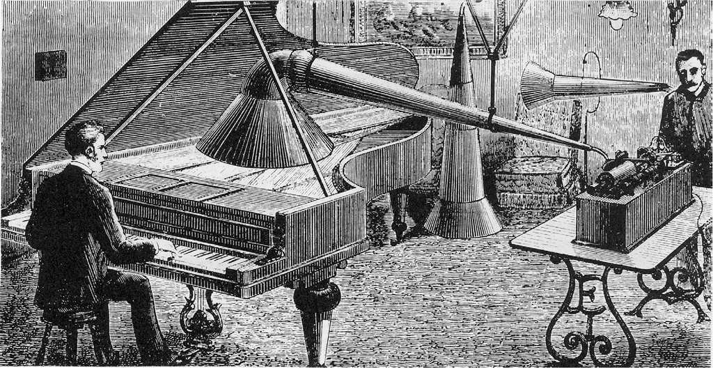

**图 1.1** 1900 年以前的机械录音会议。钢琴上方的大锥体拾取的声音振动被转换成切割针刺穿旋转蜡筒的振动。

**Figure 1.1** Mechanical recording session before 1900. Sound vibrations picked up by the large cone over the piano were transduced into vibrations of a cutting stylus piercing a rotating wax cylinder.

尽管1906年三极管的发明开启了电子时代，但电子录音直到1924年才得以实用（Keller 1981）。图1.2展示了20世纪20年代常见的一种号角式扬声器。

Although the invention of the triode vacuum tube in 1906 launched the era of electronics, electronically produced recordings did not become practical until 1924 (Keller 1981). Figure 1.2 depicts one of the horn-loaded loudspeakers that were common in the 1920s.

[figure not shown]

**图 1.2** Amplion 扬声器，1925 年广告宣传。

**Figure 1.2** Amplion loudspeaker, as advertised in 1925.

胶片上的光学录音技术首次演示于1922年（Ristow 1993）。20世纪30年代，德国开发了用涂有磁粉的磁带录音技术（图1.3），但直到二战后才传播到世界各地。德国磁录音机比以前的线带和钢带录音机有了很大的进步，因为以前的线带和钢带录音机需要硬焊接或焊接才能进行接合。

Optical sound recording on film was first demonstrated in 1922 (Ristow 1993). Sound recording on tape coated with powdered magnetized material was developed in the 1930s in Germany (figure 1.3) but did not reach the rest of the world until after World War II. The German magnetophon tape recorders were a great advance over previous wire and steel band recorders, which required hard soldering or welding to make a splice.

[figure not shown]

**图 1.3** *AEG 公司于 1935 年制造的便携式磁带*录音机原型。（图片由 BASF Aktiengesellschaft 提供。）

**Figure 1.3** Prototype of a portable *magnetophon* tape recorder from 1935, made by AEG. (Photograph courtesy of BASF Aktiengesellschaft.)

磁声机及其后继者都是*模拟*录音机，之所以这样称呼，是因为磁带上编码的波形与麦克风拾取的原始声波波形非常相似*。*如果我们能够看到磁带上的磁化粒子，它们就会形成类似于声波的图案。模拟录音因其特殊的音质仍然受到一些人的青睐。然而，模拟录音面临着基本的物理限制。这些限制在从一种模拟介质复制到另一种模拟介质时最为明显——额外的噪声是不可避免的。

The magnetophons and their descendants were *analog* recorders, so called because the waveform encoded on tape is a close *analogy* to the original sound waveform picked up by a microphone. If we could view the magnetized particles on the tape, they would form a pattern resembling the sound waveform. Analog recording is still favored by some for its special quality of sound. However, analog recording faces fundamental physical limits. These limits are most apparent in copying from one analog medium to another—additional noise is inescapable.

有关模拟录音历史的更多信息，请参阅第 26 章混音部分。

For more on the history of analog recording, see chapter 26 on mixing.

## **实验性数字音频录音**

## **Experimental Digital Audio Recording**

数字音频录音的核心概念是*采样*，即将连续的模拟信号（例如来自麦克风的信号）转换为离散的*时间采样*信号（*样本*）。每个样本只不过是一个数字——声音波形的快照（图 1.4）。

The core concept in digital audio recording is *sampling*, that is, converting continuous analog signals (such as those coming from a microphone) into discrete *time-sampled* signals (*samples*). Each sample is nothing more than a number—a snapshot of a sound waveform (figure 1.4).

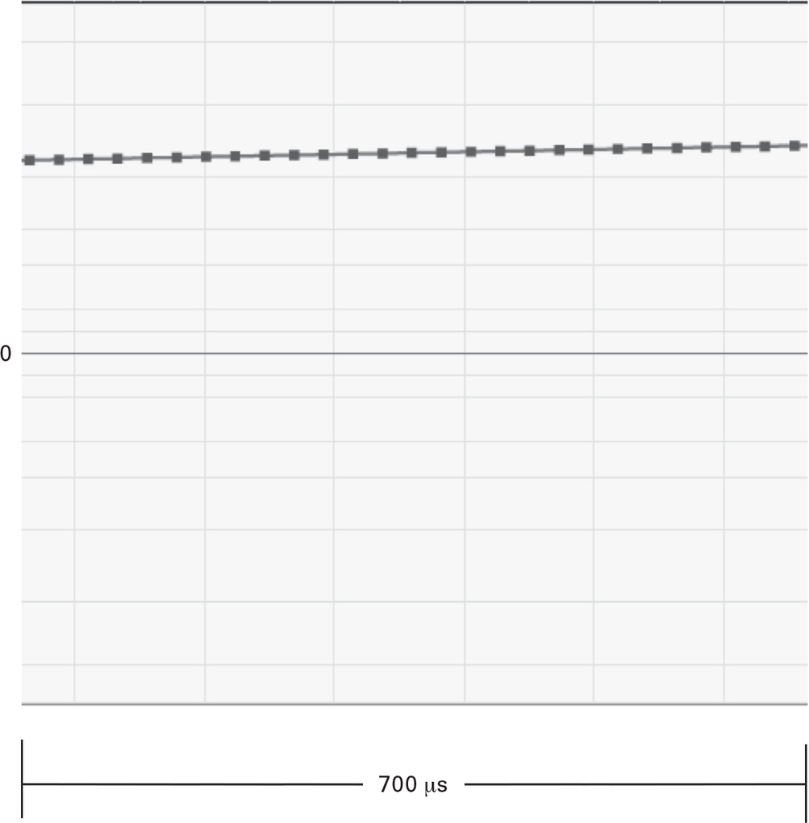

**图 1.4** 放大显示声音编辑器中的各个样本。声音编辑器在样本间画了一条线以增强显示效果。所有样本的振幅均为正值；中间的线表示振幅为 0。显示的时间跨度约为 700 µs（小于千分之一秒）。

**Figure 1.4** Zoomed in to show individual samples as they appear in a sound editor. The sound editor drew a line through them to enhance the display. The samples are all positive in amplitude; the line in the center represents 0 amplitude. The time span shown is about 700 µs (less than a thousandth of a second).

采样的理论基础是*采样定理*，该定理规定了采样率和音频带宽之间的关系。它也被称为*奈奎斯特定理*，以贝尔电话实验室的 Harold Nyquist (Nyquist 1928) 的工作命名，但该定理的另一种形式最早由法国数学家 Augustin Louis Cauchy (1789–1857) 于 1841 年提出。英国研究员 A. Reeves 开发了第一个获得专利的*脉冲编码调制*(PCM) 系统，用于以*幅度二分、时间量化*（数字）形式传输消息（Reeves 1938；Licklider 1950；Black 1953）。即使在今天，数字录音有时也被称为*PCM 录音。**信息论*的发展促进了对数字音频传输的理解（Shannon 1948）。解决模拟信号和数字信号之间转换的难题花费了数十年时间，并且仍在不断改进。第 3 章和第 4 章描述了转换过程。

The theoretical underpinning of sampling is the *sampling theorem*, which specifies the relation between the sampling rate and the audio bandwidth. It is also called the *Nyquist theorem* after the work of Harold Nyquist of Bell Telephone Laboratories (Nyquist 1928), but another form of this theorem was first stated in 1841 by the French mathematician Augustin Louis Cauchy (1789–1857). The British researcher A. Reeves developed the first patented *pulse-code-modulation* (PCM) system for transmission of messages in *amplitude-dichotomized, time-quantized* (digital) form (Reeves 1938; Licklider 1950; Black 1953). Even today, digital recording is sometimes called *PCM recording*. The development of *information theory* contributed to the understanding of digital audio transmission (Shannon 1948). Solving the difficult problems of converting between analog signals and digital signals took decades and is still being improved. Chapters 3 and 4 describe the conversion processes.

原始的发声方法可以追溯到电子计算的早期阶段（Doornbusch 2005），例如将收音机放在计算机旁边，然后运行以音频循环播放的程序来产生旋律。这些实验的音质非常有限。

Primitive methods of generating sounds, such as placing a radio next to a computer and running programs that loop at audio frequencies to create melodies, date to the early days of electronic computing (Doornbusch 2005). These experiments were very limited in their sound quality.

20 世纪 50 年代末，贝尔电话实验室的马克斯·马修斯 (Max Mathews) 和他的团队利用数字计算机生成了第一批基于样本的声音 (David, Mathews, and McDonald 1959)。使用样本来表示波形可以生成任何可能的波形。计算机将样本写入昂贵且笨重的盘式计算机磁带存储驱动器。从数字生成声音是一个单独的过程，即通过 Epsco 公司开发的定制 12 位真空管数*声转换器播放磁带*(Roads 1980)。今天，我们将将数字转换为模拟电压的播放设备称为数模转换器*(* DAC)。相比之下，*模数转换器*(ADC) 将模拟波形编码为数字。

In the late 1950s, Max Mathews and his group at Bell Telephone Laboratories generated the first sample-based sounds from a digital computer (David, Mathews, and McDonald 1959). Using samples to represent waveforms allowed generating any possible waveshape. The samples were written by the computer to expensive and bulky reel-to-reel computer tape storage drives. The production of sound from the numbers was a separate process of playing back the tape through a custom-built 12-bit vacuum tube *digital-to-sound converter* developed the Epsco Corporation (Roads 1980). Today we call a playback device that translates from digital numbers into analog voltages a *digital-to-analog converter* (DAC). By contrast, an *analog-to-digital converter* (ADC) encodes an analog waveform into digital numbers.

实用的数字音频记录介质需要具备鲁棒性，即在发生错误时能够恢复。*错误检测和纠正*方法在 20 世纪 50 年代和 60 年代得到了发展，并广泛应用于通信领域。后来，Sato、Blesser、Stockham 和 Doi 在首批实用的数字音频录音机和播放器中应用了纠错技术。日本广播公司 NHK 演示了第一台专用的单通道数字音频录音机（基于录像带机制）（Nakajima 等人，1983 年）。此后不久，Denon 开发了改进版本（图 1.5），数字音频录音机的市场竞争由此拉开帷幕（Iwamura 等人，1973 年）。

A practical digital audio recording medium needs to be robust, that is, resilient when errors occur. Methods for *error detection and correction* were developed in the 1950s and 1960s and widely used in communications. Later, Sato, Blesser, Stockham, and Doi applied error correction in the first practical digital audio recorders and players. The first dedicated one-channel digital audio recorder (based on a videotape mechanism) was demonstrated by NHK, the Japanese broadcasting company (Nakajima et al. 1983). Soon thereafter, Denon developed an improved version (figure 1.5), and the race began to bring digital audio recorders to market (Iwamura et al. 1973).

[figure not shown]

**图 1.5** 日本哥伦比亚（Denon）于 1973 年制造的数字录音机，基于 1 英寸录像机（右）。

**Figure 1.5** Nippon Columbia (Denon) digital audio recorder made in 1973, based on a 1-inch videotape recorder (right).

1977年，第一款商用录音系统索尼PCM-1问世，旨在将13位数字音频信号编码到索尼录像机上。不到一年，该系统就被16位PCM编码器所取代，例如面向专业录音市场的售价4万美元的索尼PCM-1600（Nakajima等人，1978年）。

By 1977 the first commercial recording system appeared, the Sony PCM-1, designed to encode 13-bit digital audio signals onto Sony videocassette recorders. Within a year this was displaced by 16-bit PCM encoders such as the $40,000 Sony PCM-1600 for the professional recording market (Nakajima et al. 1978).

音频工程协会 (AEDS) 在 20 世纪 80 年代制定了两种标准采样频率：44.1 kHz 和 48 kHz。该标准在获得欧洲广播联盟 (European Broadcast Union) 认可后，被称为 AES/EBU 或 AES3 标准。此后，该标准陆续修订，纳入了更高的采样率，例如 88.2 kHz、96 kHz、176.4 kHz 和 192 kHz 等 (AEDS，2008)。如今，市面上出现了各种高分辨率录音机，包括内置麦克风的手持式*现场录音机。*

The Audio Engineering Society established two standard sampling frequencies in the 1980s: 44.1 and 48 kHz. This became known as the AES/EBU or AES3 standard after it was endorsed by the European Broadcast Union. Since then, the standard has been successively revised to incorporate the higher sampling rates of 88.2, 96, 176.4, and 192 kHz, and so on (Audio Engineering Society 2008). A variety of high-resolution recorders are now available, including hand-held *field recorders* with built-in microphones.

## **面向公众的数字声音**

## **Digital Sound for the Public**

1980年，计算机音频研究尚处于起步阶段，当时消费级录音音乐的标准格式是1948年推出的黑胶长放唱片（LP）。除了少数几张发烧级LP唱片外，唱片公司在20世纪70年代和80年代生产的大多数LP唱片，由于母带处理和制作工艺的不足，音质都不太出色。因此，市场亟需一种改进的格式。

In 1980, computer sound research was still in its infancy, and the standard consumer format for recorded music was the vinyl long-play (LP) record, introduced in 1948. Apart from a small number of audiophile-quality LPs, the majority of LPs manufactured by record companies in the 1970s and 1980s were not of outstanding quality, due to compromised mastering and manufacturing practices. Thus, the market was ripe for an improved format.

### **数字音频光盘**

### **Digital Audio Discs**

数字声音于1982年首次通过*光盘*（CD）格式（一种由激光读取的12厘米光盘）进入大众视野。CD格式由飞利浦和索尼两家公司经过多年研发共同开发。它取得了巨大的商业成功，两年内售出了超过135万台播放机和数千万张光盘（Pohlman 1989a）。CD的成功部分归功于计算机行业将其作为分发软件和存储数据的通用手段——CD-ROM。

Digital sound first reached the general public in 1982 by means of the *compact disc* (CD) format, a 12 cm optical disc read by a laser. The CD format was developed jointly by the Philips and Sony corporations after years of development. It was a tremendous commercial success, selling over 1.35 million players and tens of millions of discs within two years (Pohlman 1989a). Part of the success of the CD can be traced to its adoption by the computer industry as a general means of distributing software and storing data, the CD read-only memory (CD-ROM).

2000年推出的专业DVD音频（DVD-A）和超级音频光盘（SACD）光盘格式提供了更佳的音质，但这两种格式都未能在市场上站稳脚跟。蓝光光盘格式于2002年首次推出，其物理尺寸与CD和DVD相同。蓝光支持高清3D视频、高达128GB的数据容量以及高达八声道的高分辨率数字音频（最高24位/样本，采样率为96kHz）。蓝光作为一种纯音频格式于2013年发布，但并未取得成功。

Introduced in 2000, the specialized DVD-audio (DVD-A) and super audio compact disc (SACD) optical disc formats offered improved sound quality, but neither format gained a foothold in the market. The Blu-ray disc format, first introduced in 2002, is same physical size as the CD and DVD. Blu-ray supports high-definition 3D video, up to 128 gigabytes of data and up to eight channels of high-resolution digital audio (up to 24 bits per sample at a 96 kHz sampling rate). Blu-ray as an audio-only format was announced in 2013 but was not successful.

### **可下载的音频文件格式**

### **Downloadable Audio File Formats**

互联网的兴起促进了可下载音频文件格式的发展。在整个20世纪90年代，大多数互联网用户依赖于基于电话调制解调器的慢速连接，传输速度缓慢。为了应对这些限制，流行的MP3媒体应运而生，其官方名称是MPEG音频层III，这是一个国际标准。MP3使用*有损压缩*算法来大幅减小声音文件的大小（Pohlmann 2005）。为了减少数据量，音频信息在编码阶段会被丢弃。这会导致音频保真度的损失。

The rise of the internet fostered the evolution of downloadable audio file formats. Throughout the 1990s, most internet users relied on slow connections based on telephone modems with sluggish transmission speeds. As a response to these limitations, the popular MP3 medium was developed under the official moniker MPEG Audio Layer III, an international standard. MP3 uses a *lossy compression* algorithm to drastically reduce the size of a sound file (Pohlmann 2005). To reduce the amount of data, audio information is discarded in the encoding phase. This results in a loss of audio fidelity.

相比之下，*无损压缩*可以减少文件的大小，以便于存储和传输，同时允许重建原始文件没错。免费无损音频编解码器 (FLAC) 就是无损压缩格式的一个例子。使用 FLAC 算法压缩的数字音频文件大小可以减少约 50% (Xiph 2015)。

By contrast, *lossless compression* reduces the size of the file for the purpose of storage and transmission while allowing the original file to be reconstructed exactly. The free lossless audio codec (FLAC) is an example of a lossless compression format. Digital audio files compressed by FLAC’s algorithm can be reduced in size by around 50 percent (Xiph 2015).

新的媒体格式不断涌现，部分原因是出于商业动机引入专有系统。有关音频文件格式的更多信息，请参阅第四章。

New media formats are constantly appearing, partly because there are commercial incentives to introduce proprietary systems. See chapter 4 for more on audio file formats.

## **音乐家的数字声音**

## **Digital Sound for Musicians**

1988年左右，连接个人电脑的高品质DAC问世。与此同时，音频文件的标准格式也应运而生，包括Sound Designer II（SDII）、音频交换文件格式（AIFF）和波形音频格式（WAVE）。这些发展预示着计算机音乐新时代的到来。在短时间内，个人电脑的声音合成、录音和处理功能便得到了广泛普及。许多不同的*数字音频工作站*（DAW）涌入音乐市场，包括Pro Tools、Cubase、Digital Performer、Logic等。DAW允许音乐家将音乐录制到连接到个人电脑的硬盘上。这些音乐可以通过电脑屏幕上的时间线显示进行精确编辑，并可从硬盘上播放。

High-quality DACs attached to personal computers came on the scene around 1988. At the same time, standard formats for audio files appeared, including Sound Designer II (SDII), audio interchange file format (AIFF), and waveform audio format (WAVE). These developments heralded a major new era for computer music. In a short period, sound synthesis, recording, and processing by personal computer became widespread. Many different *digital audio workstations* (DAWs) reached the musical marketplace, including Pro Tools, Cubase, Digital Performer, Logic, and others. DAWs let musicians record music onto a hard disk connected to a personal computer. This music could be precisely edited using a timeline display on the computer screen with playback from the hard disk.

## **数字多轨录音的起源**

## **Origins of Digital Multitrack Recording**

*多轨*录音机拥有多个独立的通道或*音轨*，可以在不同时间进行录制。例如，每个音轨可以录制不同的乐器，从而为后期混音提供灵活性。多轨录音机的另一个优势是，它允许音乐家以多层形式构建录音；每个新层都是先前录制层的伴奏。

*Multitrack* recorders have a number of discrete channels or *tracks* that can be recorded at different times. Each track can record, for example, a separate instrument, which allows flexibility when the tracks are later mixed together. Another advantage of multitrack machines is that they let musicians build recordings in several layers; each new layer is an accompaniment to previously recorded layers.

英国广播公司 (BBC) 于 1976 年开发了一台实验性的 10 通道数字磁带录音机。两年后，3M 公司推出了首台商用 32 轨数字录音机（图 1.6）以及一台简易的数字磁带编辑器（Duffy，1982）。第一台基于计算机磁盘的随机存取声音编辑器和混音器由犹他州盐湖城的 Soundstream 公司开发（见图 16.38）。他们的开创性系统允许一次混音多达 8 个存储在计算机磁盘上的音轨或*声音文件（Ingebretsen 和 Stockham，1984）。*

The British Broadcasting Company (BBC) developed an experimental 10-channel digital tape recorder in 1976. Two years later, the 3M company introduced the first commercial 32-track digital recorder (figure 1.6) as well as a rudimentary digital tape editor (Duffy 1982). The first computer disk–based random-access sound editor and mixer was developed by the Soundstream company in Salt Lake City, Utah (see figure 16.38). Their pioneering system allowed mixing of up to eight tracks or *sound files* stored on computer disk at a time (Ingebretsen and Stockham 1984).

[figure not shown]

**图 1.6** 3M 32 轨数字磁带录音机，于 1978 年推出。

**Figure 1.6** 3M 32-track digital tape recorder, introduced in 1978.

早期的数字多轨录音是一项非常昂贵的事业。Studer 数字录音机（图 1.7）在 1991 年的售价为 27 万美元。随后，在短时间内，软件DAW取代了大多数录音棚里的磁带录音机。人们可以在便携式笔记本电脑上进行录音、编辑和混音。

Early digital multitrack recording was a very expensive enterprise. The Studer digital recorder (figure 1.7) sold for $270,000 in 1991. Then within a short time, software DAWs replaced tape recorders in most studios. It became possible to record, edit, and mix on portable laptop computers.

[figure not shown]

**图 1.7** Studer D820-48 DASH 数字多轨录音机，于 1991 年推出，零售价约为 270,000 美元。制作磁带备份需要使用两台机器。

**Figure 1.7** Studer D820-48 DASH digital multitrack recorder, introduced in 1991 with a retail price of about $270,000. To make a backup copy of the tape required the use of two machines.

带有内置麦克风的高质量数字现场录音机开始流行（图 1.8）。

High-quality digital field recorders with built-in microphones became popular (figure 1.8).

[figure not shown]

**图1.8** 索尼PCM-D100现场录音机。

**Figure 1.8** Sony PCM-D100 field recorder.

某种程度上，便携式现场录音机的功能可以通过配备音频接口和高品质立体声麦克风的手机实现。移动设备的缺点是更新换代速度很快，这会影响到与其连接的任何设备。

To some extent, the functionality of portable field recorders can be achieved on mobile phones with accessories for an audio interface and high-quality stereo microphones. The downside of mobile devices is rapid obsolescence, which afflicts anything connected to them.

## **录音艺术**

## **The Art of Recording**

录音艺术需要的不仅仅是合适的设备。认真学习录音的学生可以通过学徒期学到很多东西。许多学校都提供四年制录音工程“音质大师”（Tonmeister）学位。“音质大师”不仅学习音乐，还学习应用物理学。他们学习房间声学（声波的反射、吸收和衍射）、乐器、麦克风类型、麦克风技术以及音频媒体制作方法。

The art of recording requires more than proper equipment. Serious students of recording have much to learn through apprenticeship. A number of schools offer four-year Tonmeister degrees in recording engineering. Tonmeisters study music as well as applied physics. They learn about the acoustics of rooms (reflection, absorption, and diffraction of sound waves) and instruments, microphone types, microphone techniques, and audio media production methods.

# *2 声音信号基础知识*

# *2 Basics of Sound Signals*

**频率和振幅**

**Frequency and Amplitude**

**时域表示**

**Time-Domain Representation**

**频域表示**

**Frequency-Domain Representation**

**阶段**

**Phase**

**阶段的重要性**

**Importance of Phase**

**声音强度**

**Sound Magnitude**

**动态范围**

**Dynamic Range**

本章介绍描述声音信号的基本概念和术语，包括频率、幅度和相位。

This chapter introduces basic concepts and terminology for describing sound signals, including frequency, amplitude, and phase.

## **频率和振幅**

## **Frequency and Amplitude**

声音从声源经空气传播到达听者的耳朵。我们之所以能听到声音，是因为耳内气压发生轻微变化，导致耳膜振动。如果气压按照重复的模式变化，我们就说声音具有*周期性波形。*如果没有可辨别的模式，则称为*噪声。*在这两个极端之间，存在着大量的准周期声音和准噪声。

Sound reaches listeners’ ears after being transmitted through air from a source. We hear sound because the air pressure is changing slightly in our ears, causing the eardrum to vibrate. If the pressure varies according to a repeating pattern, we say that the sound has a *periodic waveform.* If there is no discernible pattern it is called *noise.* In between these two extremes is a vast domain of quasiperiodic and quasinoisy sounds.

周期波形的一次重复称为一个*周期，*波形的*基频*是每秒发生的周期数。在本书的其余部分，我们将根据标准声学术语，用赫兹 (Hz) 代替每秒周期数。（赫兹是赫兹 (hertz) 的缩写，*赫兹**是以**德国*声学家海因里希·赫兹 (Heinrich Hertz) 命名的计量单位。）

One repetition of a periodic waveform is called a *cycle,* and the *fundamental frequency* of the waveform is the number of cycles that occur per second. In the rest of this book we substitute *Hz* for *cycles per second* in accordance with standard acoustical terminology. (Hz is an abbreviation for *hertz*, the unit of measurement named after the German acoustician Heinrich Hertz.)

随着周期的长度（称为*周期）*减小，每秒的频率（以周期为单位）增加，反之亦然。表 2.1显示了频率和周期之间的关系。

As the length of the cycle (called the *period)* decreases, the frequency in cycles per second increases, and vice versa. Table 2.1 shows the relationship between frequency and period.

| **表 2.1** 频率与周期的关系 **Table 2.1** Relationship of frequency to period |  |  |
| --- | --- | --- |
| 频率 Frequency |  | 时期 Period |
| 1赫兹 1 Hz |  | 1秒 1 second (s) |
| 10赫兹 10 Hz |  | 0.1 秒或 100 毫秒 (ms) 0.1 s or 100 milliseconds (ms) |
| 100赫兹 100 Hz |  | 0.01秒或10毫秒 0.01 s or 10 ms |
| 1000赫兹 1000 Hz |  | 0.001秒或1毫秒 0.001 s or 1 ms |
| 10000赫兹 10000 Hz |  | 0.0001 秒或 100 微秒 (µs) 0.0001 s or 100 microseconds (µs) |

另一个描述性术语是*波长*，它是周期之间物理距离的度量。由于声音在20摄氏度时传播速度约为343米/秒，因此1赫兹的波展开的距离约为343米，而20千赫兹的波展开的距离约为0.017米，即约1.7厘米。

Another descriptive term is *wavelength*, which is the measure of the physical distance between periods. Because sound travels at about 343 m/s at 20° Celsius, a wave at 1 Hz unfolds over about 343 m, whereas a wave at 20 kHz unfolds over about 0.017 m or about 1.7 cm.

### **时域表示**

### **Time-Domain Representation**

描述声波波形的一个简单方法是将其绘制成气压与时间的关系图（图 2.1）。这种压力图称为*时域*表示。当曲线靠近图的底部时，气压较低；当曲线靠近图的顶部时，气压较高。图中显示气压有所升高。波形的*振幅*表示气压的变化量；我们可以用从零气压点到给定波形段最高点（或最低点）的垂直距离来测量振幅。

A simple method of depicting sound waveforms is to draw them in the form of a graph of air pressure versus time (figure 2.1). This pressure graph is called a *time-domain* representation. When the curved line is near the bottom of the graph, the air pressure is lower; when the curve is near the top of the graph, the air pressure has increased. The *amplitude* of the waveform is the amount of air pressure change; we can measure amplitude as the vertical distance from the zero pressure point to the highest (or lowest) points of a given waveform segment.

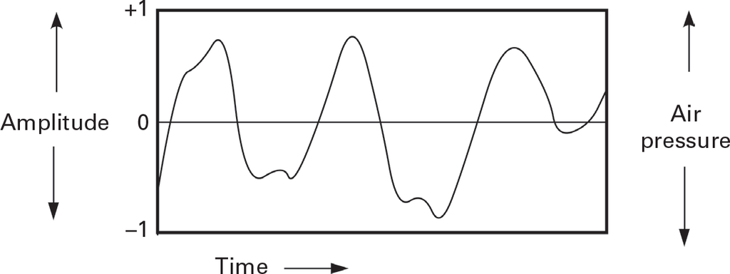

**图 2.1** 信号的时域表示。垂直方向表示气压。曲线越靠近图表顶部，气压越大。低于水平实线，气压越低。以声音形式听到的气压变化可能很快发生；对于音乐声来说，整个图表的持续时间可能不超过千分之一秒（1 毫秒）。

**Figure 2.1** Time-domain representation of a signal. The vertical dimension shows the air pressure. When the curved line is near the top of the graph, the air pressure is greater. Below the solid horizontal line, the air pressure is reduced. Atmospheric pressure variations heard as sound can occur quickly; for musical sounds, this entire graph might last no more than one-thousandth of a second (1 ms).

声学乐器通过发出振动来改变乐器周围的气压，从而产生声音。扬声器则根据电子信号中的电压变化来回振动，从而产生声音。当扬声器从静止位置*向内移动时，气压会降低。当扬声器**向外*移动时，扬声器附近的气压会升高。为了产生可听见的声音，这些向内/向外振动的频率必须介于 20 到 20,000 Hz 之间。

An acoustic instrument creates sound by emitting vibrations that change the air pressure around the instrument. A loudspeaker creates sound by moving back and forth according to voltage changes in an electronic signal. When the loudspeaker moves *in* from its position at rest, then the air pressure decreases. As the loudspeaker moves *out*, the air pressure near the loudspeaker is raised. To create an audible sound, these in/out vibrations must occur at a frequency in the range of about 20 to 20,000 Hz.

### **频域表示**

### **Frequency-Domain Representation**

除了基频之外，波形中还可能存在许多频率。*频域*或*频谱*表示法可以显示声音的频率成分。频谱中的各个频率成分可以称为*谐波*或*分音。*谐波频率是基频的简单整数倍。假设基频或*一次谐波*为 100 Hz，其二次谐波为 200 Hz，三次谐波为 300 Hz，依此类推。更一般地说，任何频率成分都可以称为分音，无论它是否是基频的整数倍。事实上，许多声音并没有特定的基频。

Besides the fundamental frequency, there can be many frequencies present in a waveform. A *frequency-domain* or *spectrum* representation shows the frequency content of a sound. The individual frequency components of the spectrum can be referred to as *harmonics* or *partials.* Harmonic frequencies are simple integer multiples of the fundamental frequency. Assuming a fundamental or *first harmonic* of 100 Hz, its second harmonic is 200 Hz, its third harmonic is 300 Hz, and so on. More generally, any frequency component can be called a partial, whether or not it is an integer multiple of a fundamental. Indeed, many sounds have no particular fundamental frequency.

波形的频率成分可以用多种方式显示。一种标准方法是将每个部分绘制成沿*x*轴的一条线。每条线的高度表示每个频率成分的强度（或振幅）。最纯净的信号是*正弦波*形，之所以这样命名，是因为它可以被计算使用三角公式计算角度的正弦值。纯正弦波仅代表频谱中的一个频率分量或一条线。图 2.2描绘了几种波形的时域和频域表示。请注意，频谱图的横轴上标有*谐波，*因为分析算法假设其输入恰好是周期波形基波的一个周期。对于图 2.2g中的噪声信号，此假设不成立，因此我们将谐波重新标记为*频率分量。*

The frequency content of a waveform can be displayed in many ways. A standard way is to plot each partial as a line along an *x-*axis. The height of each line indicates the strength (or amplitude) of each frequency component. The purest signal is a *sine* waveform, so named because it can be calculated using trigonometric formulae for the sine of an angle. A pure sine wave represents just one frequency component or one line in a spectrum. Figure 2.2 depicts the time-domain and frequency-domain representations of several waveforms. Notice that the spectrum plots are labeled *harmonics* on their horizontal axis because the analysis algorithm assumes that its input is exactly one period of the fundamental of a periodic waveform. In the case of the noise signal in figure 2.2g, this assumption is not valid, so we relabel the partials as *frequency components.*

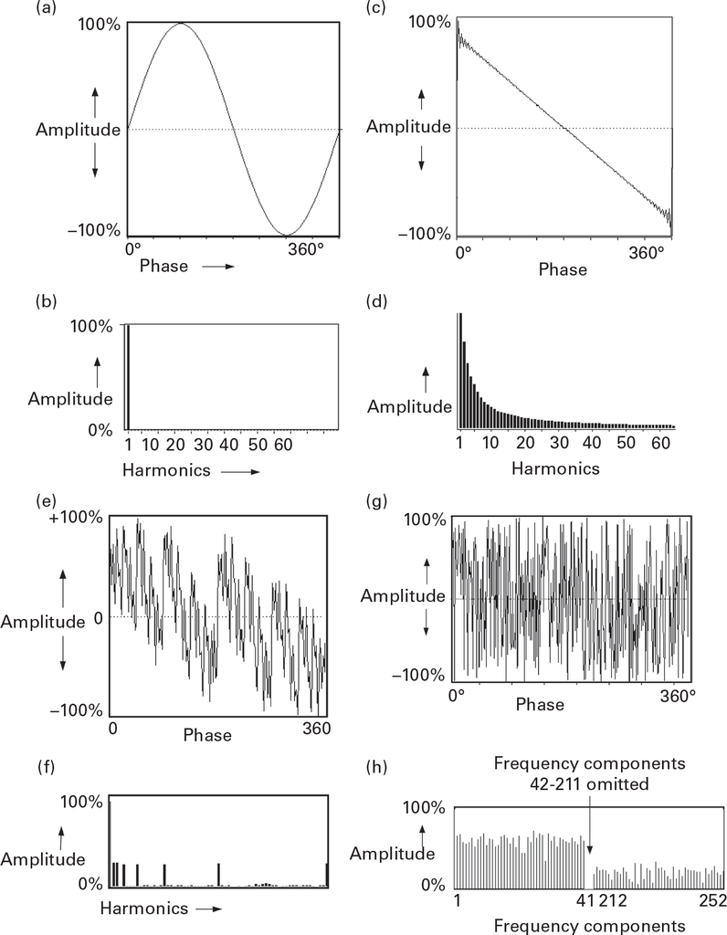

**图 2.2** 四个信号的时域和频域表示。（a）正弦波一个周期的时域视图。（b）正弦波中一个频率分量的频谱。（c）锯齿波一个周期的时域视图。（d）显示锯齿波频率内容呈指数下降的频谱。（e）复杂波形一个周期的时域视图。虽然波形看起来很复杂，但当它一遍又一遍重复时，它的声音实际上很简单——就像薄簧风琴的声音。（f）波形（e）的频谱显示它主要由几个频率组成。（g）随机噪声波形。（h）如果波形不断变化（每个周期都与上一个周期不同），那么我们听到的是噪声。噪声的频率内容非常复杂。在这种情况下，分析提取了 252 个频率。此快照并未显示它们的幅度如何随时间不断变化。

**Figure 2.2** Time-domain and frequency-domain representations of four signals. (a) Time-domain view of one cycle of a sine wave. (b) Spectrum of the one frequency component in a sine wave. (c) Time-domain view of one cycle of a sawtooth waveform. (d) Spectrum showing the exponentially decreasing frequency content of a sawtooth wave. (e) Time-domain view of one cycle of a complex waveform. Although the waveform looks complex, when it is repeated over and over its sound is actually simple—like a thin reed organ sound. (f) The spectrum of waveform (e) shows that it is dominated by a few frequencies. (g) A random noise waveform. (h) If the waveform is constantly changing (each cycle is different from the last cycle), then we hear noise. The frequency content of noise is very complex. In this case the analysis extracted 252 frequencies. This snapshot does not reveal how their amplitudes are constantly changing over time.

正如我们在第 36 至 39 章中讨论的那样，绘制声音频谱的方法有很多种。

As we discuss in chapters 36–39, there are many ways to plot the spectrum of a sound.

## **阶段**

## **Phase**

*周期波形在y*轴（即幅度轴）上的起始点是其*初始相位。*例如，典型的正弦波起始于幅度点 0，并在 0 处完成其周期。如果我们将起始点在水平轴上移动π /2 弧度或 90°，则正弦波在幅度轴上的起始点和结束点均为 1。通常，这被称为*余弦波。*实际上，余弦波相当于*相位偏移*90° 的正弦波（图 2.3）。

The starting point of a periodic waveform on the *y* or amplitude axis is its *initial phase.* For example, a typical sine wave starts at the amplitude point 0 and completes its cycle at 0. If we displace the starting point by π/2 radians or 90° on the horizontal axis then the sinusoidal wave starts and ends at 1 on the amplitude axis. By convention this is called a *cosine wave.* In effect, a cosine is equivalent to a sine wave that is *phase shifted* by 90° (figure 2.3).

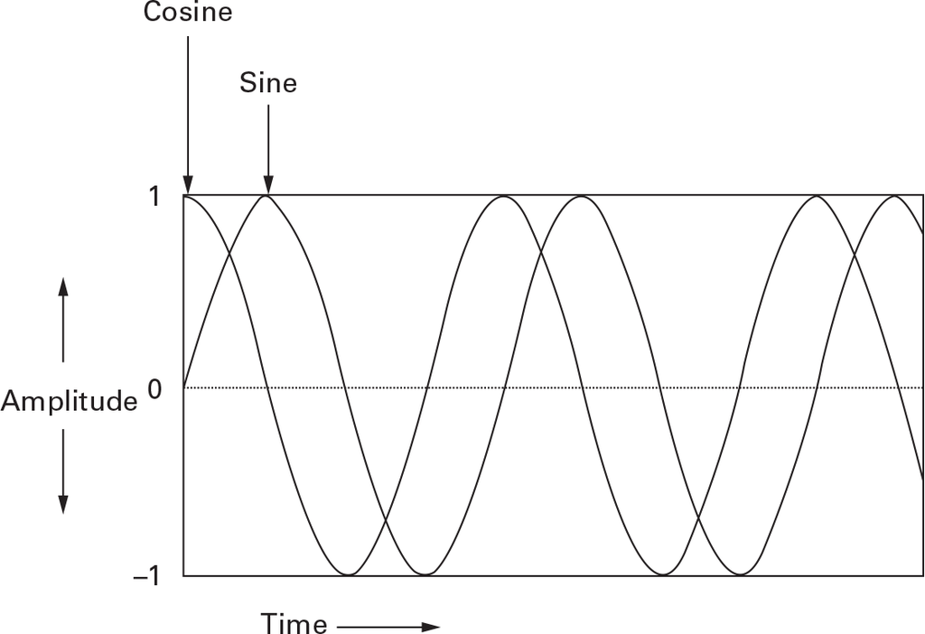

**图 2.3** 正弦波形相当于延迟的余弦波形，因此相移略有增加。

**Figure 2.3** A sine waveform is equivalent to a cosine waveform that has been delayed and hence phase shifted slightly.

当两个信号始于同一点时，我们称它们*同相*或*相位对齐。*这与一个信号相对于另一个信号略有延迟形成对比，在前者中，两个信号的相位不同*。*当信号 A 的相位与信号 B 的相位完全相反时（即，相位相差 180°，即信号 A 中的每个正值在信号 B 中都有对应的负值），我们称 B 相对于 A*极性相反**。*我们也可以说 B 是A 的*反相副本。*图 2.4描绘了两个反相信号相加时的效果：它们相互抵消。

When two signals start at the same point, they are said to be *in phase* or *phase aligned.* This contrasts to a signal that is slightly delayed with respect to another signal, in which the two signals are *out of phase.* When a signal A is the exact opposite phase of another signal B (i.e., it is 180° out of phase, so that for every positive value in signal A there is a corresponding negative value for signal B), we say that B has *reversed polarity* with respect to A*.* We could also say that B is a *phase-inverted* copy of A. Figure 2.4 portrays the effect when two signals in inverse phase relationship sum: they cancel out each other.

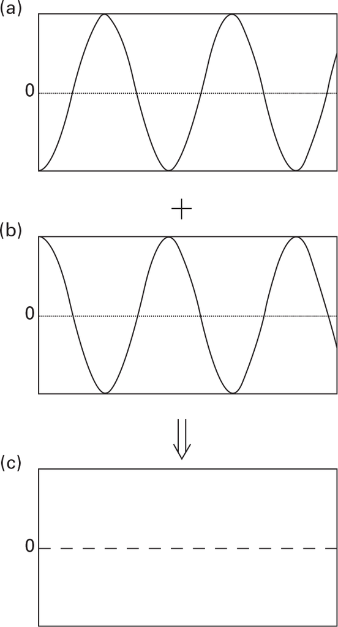

**图 2.4** 相位反转的效果。(b) 是 (a) 的相位反转版本。如果将两个波形相加，(c) 则其和为零。

**Figure 2.4** The effects of phase inversion. (b) is a phase-inverted copy of (a). If the two waveforms are added together, (c) they sum to zero.

### **阶段的重要性**

### **Importance of Phase**

有时人们认为相位对人耳来说无关紧要，因为两个除初始相位外完全相同的信号很难区分。然而，研究表明，在实验室条件下，一些人可以区分绝对相位或*极性*相差 180° 的信号(Greiner and Melton 1991)。有关相位感知的更多信息，请参阅 Laitinen、Disch 和 Pulkki (2013)。

It is sometimes said that phase is insignificant to the human ear, because two signals that are exactly the same except for their initial phase are difficult to distinguish. However, research indicates that 180° differences in absolute phase or *polarity* can be distinguished by some people under laboratory conditions (Greiner and Melton 1991). For more on phase perception, refer to Laitinen, Disch, and Pulkki (2013).

即使排除特殊情况，相位也是一个重要的概念，原因如下。每个滤波器都利用相移来改变信号。滤波器会改变相位通过将输入信号短暂延迟，然后将相移版本与原始信号相结合，从而产生*与频率相关的相位抵消*，从而衰减某些频率，并增强某些频率。*频率相关是指并非所有频率成分都会受到**同等影响。当相移随时间变化时，受影响的频段也会发生变化，从而产生称为**“移相”*或*“镶边”的*扫频音效（参见第30章）。

Even apart from special cases, phase is an important concept for several reasons. Every filter uses phase shifts to alter signals. A filter shifts the phase of a signal by delaying its input for a short time and then combines the phase-shift version with the original signal. This creates *frequency-dependent phase cancelation* to attenuate certain frequencies and *phase reinforcement* to boost certain frequencies. By *frequency-dependent* we mean that not all frequency components are affected equally. When the phase shift is time varying, the affected frequency bands also vary, creating the sweeping sound effect called *phasing* or *flanging* (see chapter 30).

对于基于现有声音分析重新合成声音的系统来说，相位也至关重要。具体来说，这些系统需要知道每个频率成分的起始相位，以便按正确的顺序组合不同的成分（M.-H. Serra 1997；X. Serra 1997）。相位数据对于再现短促、快速变化的*瞬态*声音（例如打击乐音调的起始）尤为重要。

Phase is also important in systems that resynthesize sound on the basis of an analysis of an existing sound. In particular, these systems need to know the starting phase of each frequency component in order to assemble the different components in the right order (M.-H. Serra 1997; X. Serra 1997). Phase data is particularly critical in reproducing short, rapidly changing *transient* sounds, such as the onset of a percussive tone.

最后，人们非常重视音频组件，它们会尽可能减少输入信号的相位偏移，因为频率相关的相移会使音乐信号产生可听见的失真，并干扰扬声器的*成像。*（成像是指一组扬声器产生稳定的*音频图像*的能力，其中每个音频源都位于图像中的特定位置。）不必要的相移称为*相位失真。*打个形象的比喻，相位失真的信号就是*失焦的*。

Finally, much attention has been invested in audio components that shift the phases of their input signals as little as possible, because frequency-dependent phase shifts distort musical signals audibly and interfere with loudspeaker *imaging.* (Imaging is the ability of a set of loudspeakers to create a stable *audio picture* in which each audio source is localized to a specific place within the picture.) Unwanted phase shifting is called *phase distortion.* To make a visual analogy, a phase-distorted signal is *out of focus*.

## **声音强度**

## **Sound Magnitude**

*我们对声级*或声强都有直观的概念*。*即使是小孩子也能理解音量旋钮的作用。*分贝*是量级关系的测量单位，包括电压电平、强度或功率，尤其适用于音频系统。在声学测量中，分贝标度表示一个声级与参考声级的比率*，*其依据是

We all have an intuitive notion of *sound level* or *sound magnitude.* Even a small child understands the function of a volume knob. The *decibel* is a unit of measurement for relationships of magnitude, including voltage levels, intensity, or power, particularly in audio systems. In acoustic measurements, the decibel scale indicates the ratio of one level to a *reference level,* according to the relation

*分贝数* = 10 × log <sub>10</sub> (*声级 / 参考声级*)

*number of decibels* = 10 × log<sub>10</sub> (*level/reference level*)

*参考声级*通常为听觉阈值（10 <sup>−12</sup>瓦/平方米）。分贝的对数基数意味着，如果两个音符同时发出，每个音符的强度为 60 分贝，声级仅增加 3 分贝。强度增加百万倍，也只能增加 60 分贝。

where the *reference level* is usually the threshold of hearing (10<sup>−12</sup> watts per square meter). The logarithmic basis of decibels means that if two notes sound together and each note is 60 dB, the increase in level is just 3 dB. A millionfold increase in intensity results in only a 60 dB boost.

图 2.5显示了分贝刻度和相对于 0 dB 的一些估计声功率级。

Figure 2.5 shows the decibel scale and some estimated acoustic power levels relative to 0 dB.

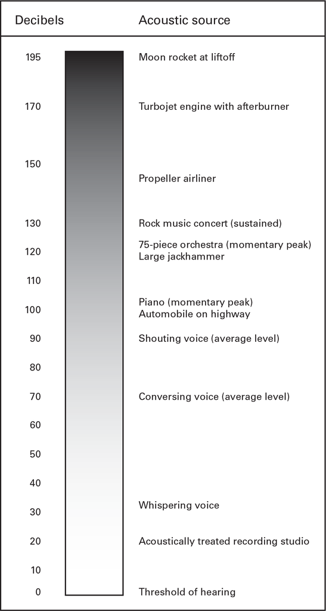

**图 2.5** 各种声源的典型声功率级。所有值均以 0 dB 为基准。

**Figure 2.5** Typical acoustic power levels for various acoustic sources. All values are relative to 0 dB.

第 4 章对声音幅度和分贝进行了更深入的讨论。

Chapter 4 contains a more thorough discussion of sound magnitude and decibels.

## **动态范围**

## **Dynamic Range**

*动态范围*是指系统在不失真的情况下能够处理的最大音量与最小音量之间的比率。数字音频系统的动态范围要求包含两个重要因素：

*Dynamic range* is the ratio between the loudest and the softest sound that can be handled by a system without distortion. Two important facts describe the dynamic range requirements of a digital audio system:

- 人类听觉的范围从大约 0 dB（大致是可以听到的最轻的声音的水平）到大约 125 dB（大致是持续声音的疼痛阈值）。
- The range of human hearing extends from approximately 0 dB, roughly the level at which the softest sound can be heard, to around 125 dB, which is roughly the threshold of pain for sustained sounds.
- 两个声音的振幅水平之间的略小于 1 dB 的差异对应于可以听到的最小振幅差异。
- A difference of somewhat less than one dB between the amplitude levels of two sounds corresponds to the smallest difference in amplitude that can be heard.

在录制音乐时，我们希望重现音乐的全部表现力。因此，捕捉尽可能宽广的动态范围至关重要。例如，在现场管弦乐音乐会中，动态范围可以从寂静无声到超过 110 dB 的齐奏（全场管弦乐）部分。

In recording music, we want to reproduce the full expressive power of the music. Thus it is important to capture the widest possible dynamic range. In a live orchestra concert, for example, the dynamic range can vary from silence to a tutti (full orchestra) section exceeding 110 dB.

每种录音设备（例如麦克风、麦克风前置放大器、混音器或录音机）在失真之前只能处理特定的动态范围。例如，模拟磁带设备的动态范围由模拟录音过程的物理特性决定。对于未配备降噪设备的专业开盘式磁带录音机，1 kHz 音调的动态范围约为 80 dB。相比之下，高质量的数字录音机的动态范围可以达到 120 dB 左右。

Every recording device (such as a microphone, mic preamplifier, mixer, or recorder) can handle only a certain dynamic range before it distorts. For example, the dynamic range of analog tape equipment is dictated by the physics of the analog recording process. That range is around 80 dB for a 1 kHz tone using professional reel-to-reel tape recorders without noise-reduction devices. By contrast, a high-quality digital audio recorder can have a dynamic range of around 120 dB.

第 4 章更详细地介绍了数字音频系统中的动态范围。

Chapter 4 goes into more detail about dynamic range in digital audio systems.

# *3 抽样理论*

# *3 Theory of Sampling*

*柯蒂斯路与约翰·M·斯特劳恩*

*Curtis Roads with John M. Strawn*

**声音的模拟表示**

**Analog Representations of Sound**

**声音的数字化表现**

**Digital Representations for Sound**

**模数转换**

**Analog-to-Digital Conversion**

**二进制数**

**Binary Numbers**

**数模转换**

**Digital-to-Analog Conversion**

**数字音频样本不是 MIDI 数据**

**Digital Audio Samples Are Not MIDI Data**

**采样**

**Sampling**

**模拟信号的重建**

**Reconstruction of the Analog Signal**

**混叠**

**Aliasing**

**抽样定理**

**The Sampling Theorem**

**抗混叠和抗镜像滤波器**

**Antialiasing and Anti-imaging Filters**

**音频接口**

**Audio Interfaces**

**理想采样频率**

**Ideal Sampling Frequency**

**抖动**

**Jitter**

本章首先解释模拟音频系统和数字音频系统的区别。然后，我们将逐步讲解数字音频录制和播放链的基础知识。如需进一步的技术学习，请参阅 Pohlmann (2010)。

This chapter begins by explaining differences between analog and digital audio systems. We then step through the basics of the digital audio recording and playback chain. For further technical study, consult Pohlmann (2010).

## **声音的模拟表示**

## **Analog Representations of Sound**

正如气压会随着声波而变化一样，连接放大器和扬声器的电线中被称为*电压*的电特性也会随之变化。我们无需在此定义电压。就本章而言，我们仅假设可以以与气压变化紧密匹配的方式修改电特性。我们可以说气压和电压是类似的。也就是说，麦克风拾取的气压变化图与播放该声音时扬声器位置变化的图相似。术语*“模拟”*意味着这些特性可以以类似的方式变化。

Just as air pressure varies according to sound waves, so can the electrical property called *voltage* in a wire connecting an amplifier with a loudspeaker. We do not need to define voltage here. For the purposes of this chapter, we simply assume that it is possible to modify an electrical property in a fashion that closely matches changes in air pressure. We can say that air pressure and voltage are analogous to each other. That is, a graph of the air pressure variations picked up by a microphone looks similar to a graph of the variations in the loudspeaker position when that sound is played back. The term *analog* means that these properties can vary in a similar manner.

图 3.1展示了一个模拟音频播放链。音频波形的曲线可以刻在传统唱片的凹槽上。唱片凹槽的壁面记录着唱片中存储的声音的*连续时间*表示。当唱针在凹槽中滑动时，它会以横向运动来回移动。这种横向运动随后转化为电压，经放大后最终到达扬声器。

Figure 3.1 shows an analog audio playback chain. The curve of an audio waveform can be inscribed along the groove of a traditional phonograph record. The walls of the grooves on a phonograph record contain a *continuous-time* representation of the sound stored in the record. As the needle glides through the groove, it moves back and forth in lateral motion. This lateral motion is then changed into voltage, which is amplified and eventually reaches the loudspeaker.

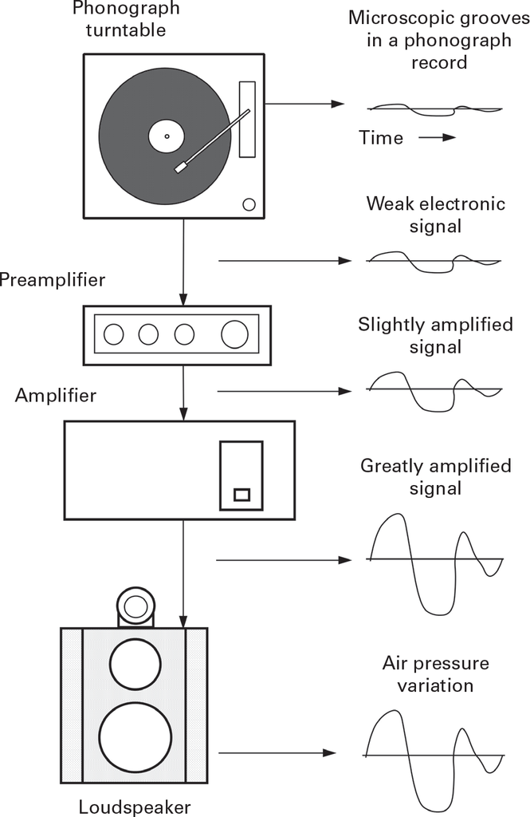

**图 3.1** 模拟音频播放链，从唱片凹槽转换的模拟波形开始，到发送到前置放大器、放大器和扬声器并投射到空中的电压。

**Figure 3.1** The analog audio playback chain, starting from an analog waveform transduced from the grooves of a phonograph record to a voltage sent to a preamplifier, amplifier, and loudspeaker and projected into the air.

模拟录音和声音再现技术已发展到相当高的水平，但它面临着基本的物理限制。具体来说，当将模拟录音复制到另一台模拟录音机上时，复制品的质量永远不如原版。原因是模拟录音过程总会添加噪音。对于用高质量磁带录音机录制的*第一代*或原始录音，这种噪音并不令人反感。但如果我们将第一代磁带复制到另一盘磁带上，然后再复制复制品，噪音就会明显增加。相比之下，数字技术可以创建任意数量的完美（无噪音）原始数字录音的克隆版本，正如我们稍后将要展示的那样。

Analog recording and reproduction of sound has been taken to a high level, but it faces fundamental physical limits. Specifically, when one copies an analog recording onto another analog recorder, the copy is never as good as the original. The reason is that the analog recording process always adds noise. On a *first-generation* or original recording made with a high-quality tape recorder, this noise is not objectionable. But if we copy the first-generation tape onto another tape and then copy the copy, the noise increases noticeably. In contrast, digital technology can create any number of generations of perfect (noise-free) clones of an original digital recording, as we show further on.

## **声音的数字化表现**

## **Digital Representations for Sound**

本节介绍与数字信号相关的最基本概念，包括音频信号转换为二进制数，以及音频数据与 MIDI 数据的比较。

This section introduces the most basic concepts associated with digital signals, including the conversion of audio signals into binary numbers, and comparison of audio data with MIDI data.

### **模数转换**

### **Analog-to-Digital Conversion**

Let us look at the process of digitally recording sound and then playing it back. Rather than the continuous-time signals of the analog world, a digital recorder handles *discrete-time* signals. Figure 3.2 shows a diagram of the digital audio recording and playback process. In this diagram, a microphone transduces air pressure variations into electrical voltage variations, which are then passed through an *antialiasing filter* and then to an *analog-to-digital converter* (ADC). (We discuss the function of the antialiasing filter in a subsequent section.) The ADC samples and converts the voltage variations into a string of *binary numbers* at each uniform period of the sample clock. The binary numbers are then stored in a digital recording medium—a type of memory.

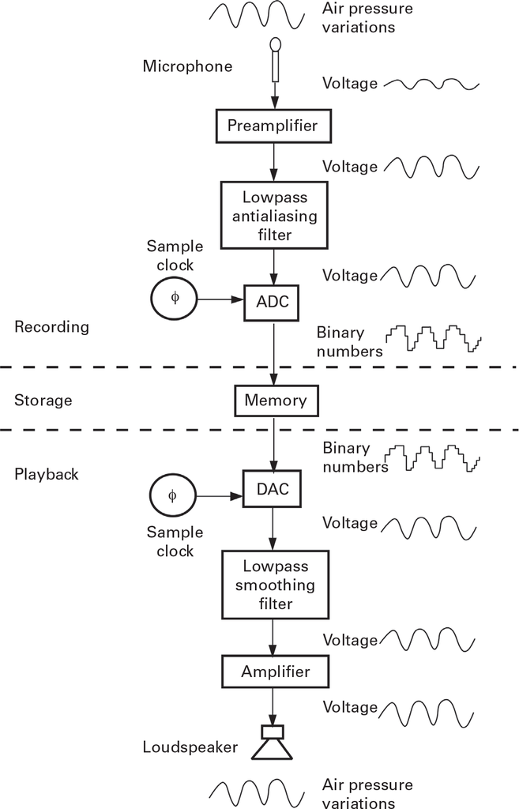

**图 3.2** 数字录音和回放概览。

**Figure 3.2** Overview of digital recording and playback.

### **二进制数**

### **Binary Numbers**

与十进制（或*十进制*）数字（使用 0-9 十个数字）不同，二进制（或*二进制*）数字仅使用两个数字：0 和 1。术语*“位”是**“二进制数字”*的缩写。表 3.1列出了二进制数及其十进制等效值。在许多数字系统中，最左边的位被解释为符号指示符，其中 1 表示正整数，0 表示负整数。（像 8.476 这样的实数十进制数也可以用二进制浮点数表示*，*但我们在此不做解释。）

In contrast to decimal (or *base ten*) numbers, which use the ten digits 0–9, binary (or *base two*) numbers use only two digits: 0 and 1. The term *bit* is an abbreviation of *binary digit*. Table 3.1 lists binary numbers and their decimal equivalents. In many digital systems the leftmost bit is interpreted as a sign indicator, with a 1 indicating a positive integer and a 0 indicating a negative integer. (Real decimal numbers such as 8.476 can also be represented in binary as *floating-point numbers*, but we will not explain this scheme here.)

| **表 3.1** 二进制数及其十进制等价物 **Table 3.1** Binary numbers and their decimal equivalents |  |  |
| --- | --- | --- |
| 二进制 Binary |  | 十进制 Decimal |
| 0 0 |  | 0 0 |
| 1 1 |  | 1 1 |
| 10 10 |  | 2 2 |
| 11 11 |  | 3 3 |
| 100 100 |  | 4 4 |
| 1000 1000 |  | 8 8 |
| 10000 10000 |  | 16 16 |
| 100000 100000 |  | 三十二 32 |
| 1111111111111111 1111111111111111 |  | 65,535 65,535 |

位在记录介质中的物理编码方式取决于该介质的属性。例如，在磁盘上，1 可能由正磁荷表示，而 0 则表示无磁荷。这与模拟磁带记录不同，在模拟磁带记录中，信号表示为连续变化的磁荷。在光盘等光学介质上，二进制数据可能被编码为特定位置反射率的变化。*固态*存储器或*闪存*将位编码为由晶体管构成的存储单元中的电荷。

The way a bit is physically encoded in a recording medium depends on the properties of that medium. On a magnetic disc, for example, a 1 might be represented by a positive magnetic charge, whereas a 0 is indicated by the absence of such a charge. This is different from an analog magnetic tape recording, in which the signal is represented as a continuously varying magnetic charge. On an optical medium such as a compact disc, binary data might be encoded as variations in the reflectance at a particular location. *Solid-state* or *flash memory* encodes a bit as an electrical charge in a memory cell made out of transistors.

### **数模转换**

### **Digital-to-Analog Conversion**

图 3.3描绘了将音频信号 (a) 转换为数字信号 (b) 的结果。当听众想要再次听到声音时，二进制数字会被逐一从数字存储器中读取，并通过数模转换器*( DAC) 进行传输。该设备由采样时钟驱动，将数字流转换为一系列电压电平。之后，该过程与*图 3.2所示的相同；也就是说，一系列电压电平经过低通滤波变成连续时间波形（图 3.3c），然后放大，并传输到扬声器，扬声器的振动会引起气压的变化。瞧——信号再次响起。

Figure 3.3 depicts the result of converting an audio signal (a) into a digital signal (b). When the listener wants to hear the sound again, the binary numbers are read one by one from the digital storage and passed through a *digital-to-analog converter* (DAC). This device, driven by a sample clock, changes the stream of numbers into a series of voltage levels. From there, the process is the same as shown in figure 3.2; that is, the series of voltage levels are lowpass filtered into a continuous-time waveform (figure 3.3c), amplified, and routed to a loudspeaker, whose vibration causes the air pressure to change. Voilà—the signal sounds again.

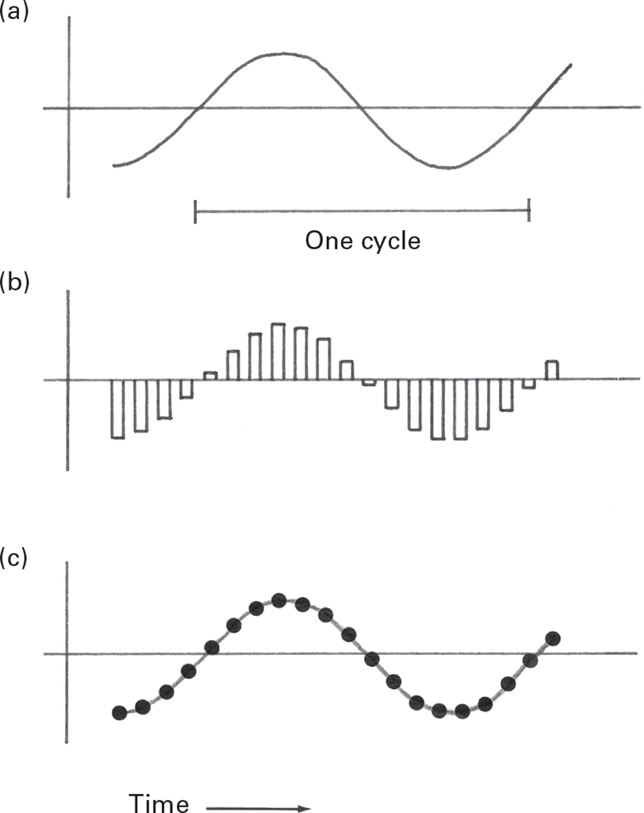

**图 3.3** 信号的模拟和数字表示。(a) 模拟正弦波形。波形下方的水平线表示一个周期或循环。(b) 图 (a) 中正弦波形的采样版本，它可能出现在 ADC 的输出端。每个垂直线代表一个样本。每个样本都以一个数字的形式存储在内存中，该数字代表垂直线的高度。(c) 图 (b) 中波形采样版本的重构。实际上，这些样本通过低通平滑滤波器连接起来，形成最终到达听者耳朵的波形。

**Figure 3.3** Analog and digital representations of a signal. (a) Analog sine waveform. The horizontal bar below the wave indicates one period or cycle. (b) Sampled version of the sine waveform in (a), as it might appear at the output of an ADC. Each vertical bar represents one sample. Each sample is stored in memory as a number that represents the height of the vertical bar. (c) Reconstruction of the sampled version of the waveform in (b). In effect, the samples are connected by the lowpass smoothing filter to form the waveform that eventually reaches the listener’s ear.

总而言之，我们可以将空气中的声音转换成一串二进制数字，并以数字方式存储。这个转换过程的核心组件是ADC。当我们想再次听到声音时，DAC可以将这些数字转换回声音。

In summary, we can change a sound in the air into a string of binary numbers that can be stored digitally. The central component in this conversion process is the ADC. When we want to hear the sound again, a DAC can change those numbers back into sound.

### **数字音频样本不是 MIDI 数据**

### **Digital Audio Samples Are Not MIDI Data**

This section may clear up confusion. The string of numbers generated by the ADC is not related to Musical Instrument Digital Interface (MIDI) data. (For more information on MIDI, see chapter 52.) Digital audio recording samples the sound waveform whereas MIDI recording captures the data played on a controller, such as a keyboard. MIDI note information includes only the start and ending time, pitch (a number), and amplitude at the beginning of the note (a number). If a MIDI note is transmitted back to the synthesizer on which it was originally played, this causes the synthesizer to play the sound as it did originally, similarly to a piano roll recording. If the musician plays four quarter notes at a tempo of sixty beats per minute on a MIDI synthesizer, just sixteen pieces of information capture this four-second sound (four starts, ends, pitches, and amplitudes).

数字音频录音的优势在于，它可以捕捉麦克风能够录制的任何声音，包括人声。相比之下，MIDI 序列录音仅限于录制指示一系列音符事件的开始、结束、音高和振幅的控制信号。

The advantage of a digital audio recording is that it can capture any sound that can be recorded by a microphone, including the human voice. By contrast, MIDI sequence recording is limited to recording control signals that indicate the start, end, pitch, and amplitude of a series of note events.

## **采样**

## **Sampling**

图 3.3b所示的数字信号与图 3.3a所示的原始模拟信号有显著不同。首先，数字信号仅在特定时间点定义。这是因为信号是在特定时间点*采样的。*图 3.3b中的每个竖线代表原始信号的一个*样本*。样本以二进制数存储；图 3.3b中竖线越高，数字越大。

The digital signal shown in figure 3.3b is significantly different from the original analog signal shown in figure 3.3a. First, the digital signal is defined only at certain points in time. This happens because the signal has been *sampled* at certain times. Each vertical bar in figure 3.3b represents one *sample* of the original signal. The samples are stored as binary numbers; the higher the bar in figure 3.3b, the larger the number.

用于表示每个样本的位数称为系统的*量化*。量化决定了系统能够处理的噪声水平和幅度范围。例如，一张光盘的量化位数为16位。也就是说，每个样本都用一个16位的数字表示。量化位数越高，幅度分辨率就越高，从而带来更低的噪声和更大的动态范围。量化位数越少，则效果越差。我们将在第4章更详细地讨论量化时再次讨论这个主题。

The number of bits used to represent each sample is called the *quantization* of the system. Quantization determines both the noise level and the amplitude range that can be handled by the system. For example, a compact disc has a quantization of 16 bits. That is, every sample is represented by a 16-bit number. More bits of quantization mean better amplitude resolution. This translates into lower noise and more dynamic range. Fewer bits result in the opposite. We return to this subject in chapter 4 when we discuss quantization at greater length.

采样率（*采样频率*）以每秒采样数表示。这是数字音频系统的一项重要规格。它通常被称为*采样率*，以赫兹 (Hz) 表示。将 1,000 Hz 简化为 1 kHz，我们说：“CD 录音的采样率为 44.1 kHz”，其中 k*源自*公制术语“*千”*，表示千。

The rate at which samples are taken—the *sampling frequency*—is expressed in terms of samples per second. This is an important specification of digital audio systems. It is often called the *sampling rate* and is expressed in terms of hertz (Hz). Simplifying the measurement 1,000 Hz to 1 kHz, we say, “The sampling rate of a compact disc recording is 44.1 kHz,” where the *k* is derived from the metric term *kilo*, which means thousand.

### **模拟信号的重建**

### **Reconstruction of the Analog Signal**

在数字音频系统中，50 kHz 左右的采样频率很常见，尽管更低和更高的频率也存在。无论如何，每秒 50,000 个数字是一个快速的数字流；这意味着一分钟的立体声有 6,000,000 个样本。

Sampling frequencies around 50 kHz are common in digital audio systems, although both lower and higher frequencies can also be found. In any case, 50,000 numbers per second is a rapid stream of numbers; it means there are 6,000,000 samples for one minute of stereo sound.

图 3.3b中的数字信号没有显示条形之间的值。条形的持续时间非常短，可能只有 0.00002 秒（十万分之二秒）。这意味着，如果原始信号在条形之间发生变化，则直到下一个样本被采集之前，该变化都不会反映在条形的高度上。用专业术语来说，我们说图 3.3b中的信号是在*离散*时间定义的，每个这样的时间都由一个样本（垂直条）表示。

The digital signal in figure 3.3b does not show the value between the bars. The duration of a bar is extremely narrow, perhaps lasting only 0.00002 s (two hundred-thousandths of a second). This means that if the original signal changes between the bars, the change is not reflected in the height of a bar until the next sample is taken. In technical terms, we say that the signal in figure 3.3b is defined at *discrete* times, each such time represented by one sample (vertical bar).

数字音频的神奇之处在于，如果信号*带宽受限，* DAC 和相关硬件就能根据这些样本精确地重建原始信号。如果信号的频率范围有限，我们称其为带宽受限信号。这意味着，在特定条件下，样本之间缺失的信号部分可以被恢复。当数字信号通过包含低通平滑滤波器的 DAC 时，就会发生这种情况。低通平滑滤波器的设计旨在精确重建离散样本之间缺失的信号部分（参见图 3.3c中的虚线）。因此，发送到扬声器的信号看起来和听起来都像原始信号。

Part of the magic of digital audio is that if the signal is *bandlimited,* the DAC and associated hardware can exactly reconstruct the original signal from these samples. We call a signal bandlimited if it has frequencies only within a finite range. This means that, given certain conditions, the missing part of the signal between the samples can be restored. This happens when the numbers are passed through the DAC, which includes the lowpass smoothing filter. The lowpass smoothing filter is designed precisely to re-create the missing part of the signal between the discrete samples (see the dotted line in figure 3.3c). Thus, the signal sent to the loudspeaker looks and sounds like the original signal.

## **混叠**

## **Aliasing**

采样过程并不像看起来那么简单。正如音频放大器会引入失真一样，采样也会对声音产生影响。图 3.4给出了一个例子。使用图 3.4a所示的输入波形，假设在图 3.4b中竖线所示的每个时间点（每个竖线创建一个样本）对该波形进行采样。与之前一样，图 3.4c中得到的样本以数字形式存储在数字存储器中。然而，当我们尝试重建原始波形时，如图 3.4d所示，结果却完全不同。

The process of sampling is not quite as straightforward as it might seem. Just as an audio amplifier can introduce distortion, sampling can play tricks with sound. Figure 3.4 gives an example. Using the input waveform shown in figure 3.4a, suppose that a sample of this waveform is taken at each point in time shown by the vertical bars in figure 3.4b (each vertical bar creates one sample). As before, the resulting samples of figure 3.4c are stored as numbers in digital memory. However, when we attempt to reconstruct the original waveform, as shown in figure 3.4d, the result is something completely different.

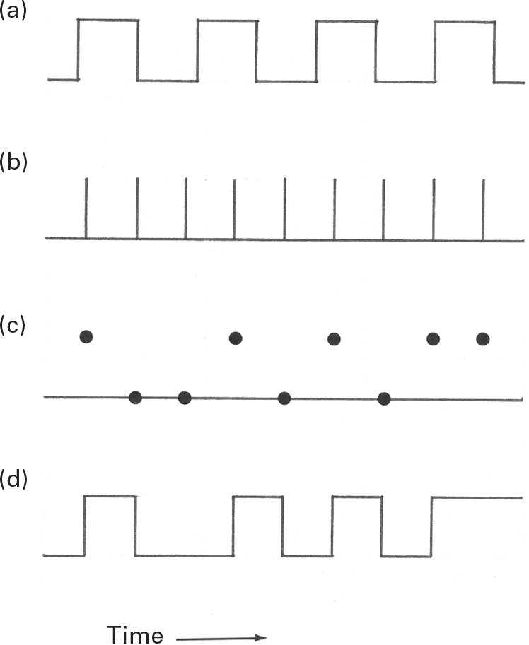

**图 3.4** 采样问题。（a）待记录的波形。（b）采样脉冲；每当发生一个采样脉冲时，就会进行一次采样。（c）采样并存储在内存中的波形。（d）当（c）中的波形发送到 DAC 时，输出可能如下所示（Mathews 1969 年之后）。

**Figure 3.4** Problems in sampling. (a) Waveform to be recorded. (b) The sampling pulses; whenever a sampling pulse occurs, one sample is taken. (c) The waveform as sampled and stored in memory. (d) When the waveform from (c) is sent to the DAC, the output might appear as shown here (after Mathews 1969).

为了更好地理解采样过程中可能出现的问题，我们来看一下，在不改变采样间隔时间长度的情况下，改变原始信号的*波长（一个周期的长度）会发生什么。*图 3.5a显示了周期为 8 个采样的信号，图 3.5d显示了周期为 2 个采样的信号，图 3.5g显示了每 10 个采样包含 11 个周期的波形。

In order to understand better the problems that can occur with sampling, we look at what happens when we change the *wavelength* (the length of one cycle) of the original signal without changing the length of time between samples. Figure 3.5a shows a signal with a cycle eight samples long, figure 3.5d shows a cycle two samples long, and figure 3.5g shows a waveform with eleven cycles per ten samples.

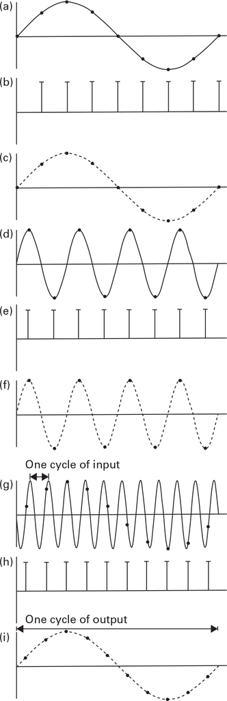

**图 3.5** 混叠效应。在每组三个图表的底部，粗黑点代表样本，虚线表示 DAC 重建的信号。在 (b) 中，正弦波形 (a) 的每个周期被采样八次。使用相同的采样频率，在 (e) 中，(d) 的每个周期仅被采样两次。如果 (e) 中的采样脉冲向右移动，则 (f) 中的输出波形可能会发生相移，尽管输出频率仍然相同。在 (h) 中，(g) 中的十一个周期有十个样本。当 DAC 尝试重建信号时，如 (i) 中的虚线所示，会得到正弦波形，但由于折叠效应，频率已完全改变。请注意 (g) 上方的水平双箭头，它表示输入波形的一个周期，以及 (i) 上方的箭头，它表示输出波形的一个周期。

**Figure 3.5** Aliasing effects. At the bottom of each set of three graphs, the thick black dots represent samples, and the dotted line shows the signal as reconstructed by the DAC. Every cycle of the sine waveform (a) is sampled eight times in (b). Using the same sampling frequency, each cycle of (d) is sampled only twice in (e). If the sampling pulses in (e) were moved to the right, the output waveform in (f) might be phase-shifted, although the frequency of the output would still be the same. In (h), there are ten samples for the eleven cycles in (g). When the DAC tries to reconstruct a signal, as shown by the dashed lines in (i), a sine waveform results, but the frequency has been completely changed due to the foldover effect. Notice the horizontal double arrow above (g), indicating one cycle of the input waveform, and the arrow above (i), indicating one cycle of the output waveform.

同样，当每组样本通过 DAC 和相关硬件时，会重建一个信号（图 3.5c、f和i ）并发送到扬声器。图 3.5c中虚线所示的信号重建得或多或少准确。图 3.5f中的采样结果可能不太令人满意；那里显示了一种可能的重建。但在图 3.5i中，重新合成的波形在一个重要方面与原始波形完全不同。即，重新合成波形的波长（周期长度）与原始波形不同。在现实世界中，这意味着重建信号的音调与原始信号不同。这种失真称为*混叠*。

Again, as each of the sets of samples is passed through the DAC and associated hardware, a signal is reconstructed (figures 3.5c, f, and i) and sent to the loudspeaker. The signal shown by the dotted line in figure 3.5c is reconstructed more or less accurately. The results of the sampling in figure 3.5f are potentially less satisfactory; one possible reconstruction is shown there. But in figure 3.5i, the resynthesized waveform is completely different from the original in one important respect. Namely, the wavelength (length of the cycle) of the resynthesized waveform is different from that of the original. In the real world, this means that the reconstructed signal sounds at a pitch different from that of the original signal. This kind of distortion is called *aliasing*.

发生混叠的频率是可以预测的。为了简化计算，假设采样率为 1,000 Hz。那么图 3.5a中的信号频率为 125 Hz（因为每个周期有 8 个样本，1,000/8 = 125）。图 3.5d中的信号频率为 500 Hz（因为 1,000/2 = 500）。图 3.5g中的输入信号频率为 1,100 Hz。

The frequencies at which this aliasing occurs can be predicted. Suppose, just to keep the numbers simple, that the sampling rate is 1,000 Hz. Then the signal in figure 3.5a has a frequency of 125 Hz (because there are eight samples per cycle, and 1,000/8 = 125). In figure 3.5d, the signal has a frequency of 500 Hz (because 1,000/2 = 500). The frequency of the input signal in figure 3.5g is 1,100 Hz.

注意输出信号的频率是如何不同的。在图 3.5i中，你可以计算出输出波形每个周期的 10 个样本。实际上，输出波形的频率为 1,000/10 = 100 Hz。因此图 3.5g中原始信号的频率在*采样率转换*过程中发生了改变。这对于音乐信号来说是一种不可接受的改变，必须尽可能避免。

Notice how the frequency of the output signal is different. In figure 3.5i you can count ten samples per cycle of the output waveform. In actuality, the output waveform occurs at a frequency of 1,000/10 = 100 Hz. Thus the frequency of the original signal in figure 3.5g has been changed by the *sample rate conversion* process. This represents an unacceptable change to a musical signal that must be avoided if possible.

## **抽样定理**

## **The Sampling Theorem**

从图 3.5可以推导出，只要原始波形每个周期至少有两个样本，我们就可以假设重新合成的波形具有相同的频率。但是，当每个周期的样本少于两个时，原始信号的频率就会丢失。如果原始频率高于采样频率的一半，则

We can generalize from figure 3.5 to say that as long as there are at least two samples per period of the original waveform, we can assume that the resynthesized waveform will have the same frequency. But when there are fewer than two samples per period, the frequency of the original signal is lost. If the original frequency is higher than half the sampling frequency, then

*新频率* = *采样频率* − *原始频率*

*new frequency* = *sampling frequency* − *original frequency*

这个公式在数学上并不完整，但足以满足我们在此的讨论。它的含义如下：假设我们选择了一个固定的采样频率。我们从一个低频信号开始，对其进行采样，并在采样后重新合成信号。随着我们提高输入信号的音高（但仍保持采样频率不变），重新合成信号的音高与输入信号的音高相同，直到达到对应于采样频率一半的音高。随着我们进一步提高输入信号的音高，输出信号的音高开始下降到最低频率！

This formula is not mathematically complete, but it is sufficient for our discussion here. It means the following. Suppose that we have chosen a fixed sampling frequency. We start with a signal at a low frequency, sample it, and resynthesize the signal after sampling. As we raise the pitch of the input signal (but still keep the sampling frequency constant), the pitch of the resynthesized signal is the same as the pitch of the input signal until we reach a pitch that corresponds to one-half the sampling frequency. As we raise the pitch of the input signal even higher, the pitch of the output signal starts to descend to the lowest frequencies!

该过程如图 3.6所示，它说明了为什么混叠有时被称为*折叠。*

The process is depicted in figure 3.6, which shows why aliasing was sometimes called *foldover.*

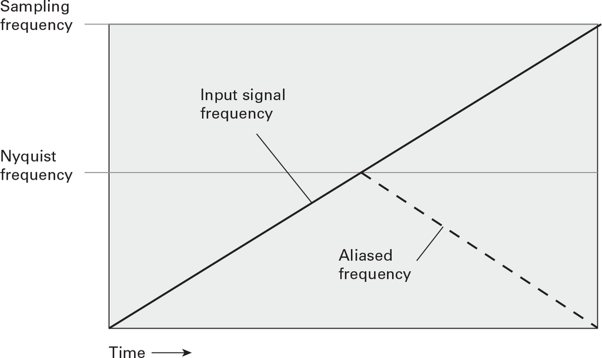

**图 3.6** 当输入频率超过奈奎斯特频率时，记录的信号*会折叠*并向下进行。

**Figure 3.6** When the input frequency exceeds the Nyquist frequency, the recorded signal *folds over* and proceeds downward.

举一个具体的例子，假设我们将 30 kHz 的模拟频率引入到以 48 kHz 采样率工作的 ADC 中。当由 DAC 重建时，它将产生 18 kHz 的音调，因为 48 − 30 = 18。

To give a concrete example, suppose that we introduce an analog frequency at 30 kHz into an ADC operating at a 48 kHz sampling rate. When reconstructed by a DAC, it will produce a tone at 18 kHz, because 48 − 30 = 18.

*采样定理*（或*奈奎斯特定理*）描述了采样率与传输信号带宽之间的关系。该定理由哈罗德·奈奎斯特（Harold Nyquist，1928）表述如下：

The *sampling theorem* (or *Nyquist theorem*) describes the relationship between the sampling rate and the bandwidth of the signal being transmitted. It was expressed by Harold Nyquist (1928) as follows:

> *对于接收信号的任何给定变形，传输频率范围必须与信号传输速度成正比地增加。……结论是频带与速度成正比。*

> *For any given deformation of the received signal, the transmitted frequency range must be increased in direct proportion to the signaling speed.… The conclusion is that the frequency band is directly proportional to the speed.*

采样定理的要点可以精确地表述如下：

The essential point of the sampling theorem can be stated precisely as follows:

> *为了能够从样本中重建连续信号，我们采样的频率必须至少是信号中最高频率的两倍。*

> *In order to be able to reconstruct a continuous signal from its samples, the frequency at which we sample must be at least twice the highest frequency in the signal.*

数字音频系统中能够再现的最高频率（即采样率的一半）称为*奈奎斯特频率。*在数字音乐系统中，奈奎斯特频率通常高于人耳听觉的上限，即 20 kHz 以上。因此，采样频率可以指定为至少两倍，即 40 kHz 以上。例如，在以 44.1 kHz（CD 的采样频率）采样的录音系统中，奈奎斯特频率为 22.05 kHz。

The highest frequency that can be reproduced in a digital audio system (i.e., half the sampling rate) is called the *Nyquist frequency.* In digital musical systems, the Nyquist frequency is usually above the upper range of human hearing, that is, above 20 kHz. Then the sampling frequency can be specified as being at least twice as much, or above 40 kHz. For example, in a recording system that samples at 44.1 kHz (the sampling frequency of compact discs), the Nyquist frequency is 22.05 kHz.

## **抗混叠和抗镜像滤波器**

## **Antialiasing and Anti-imaging Filters**

为了确保数字音响系统正常工作，需要两个重要的滤波器。回想一下图 3.2。其中一个滤波器位于 ADC 之前，以确保输入信号中不会出现高于采样频率一半的频率。只要这个滤波器正常工作，录音过程中就不会出现混叠。从逻辑上讲，这种滤波器被称为*抗混叠滤波器。*

In order to make sure that a digital sound system works properly, two important filters are included. Recall figure 3.2. One filter is placed before the ADC, to make sure that nothing in the input signal occurs at a frequency higher than half the sampling frequency. As long as this filter does the proper work, aliasing should not occur during the recording process. Logically enough, such a filter is called an *antialiasing filter.*

另一个滤波器位于DAC之后。其主要功能是将数字存储的样本转换为平滑、连续的信号表示。实际上，这个*低通抗镜像*或*平滑滤波器*通过连接图中的实心黑点，创建了图3.3c中的虚线。

The other filter is placed after the DAC. Its main function is to change the samples stored digitally into a smooth, continuous representation of the signal. In effect, this *lowpass anti-imaging* or *smoothing filter* creates the dotted line in figure 3.3c by connecting the solid black dots in the figure.

## **音频接口**

## **Audio Interfaces**

计算机和移动设备内置的 ADC 和 DAC 制造成本低廉，性能足以满足日常使用。然而，计算机、平板电脑或手机的标准音频输入和输出不足以实现高质量的音频录制和播放。

The ADCs and DACs built into computers and mobile devices are inexpensive to manufacture. They perform adequately for daily use. However, the standard audio input and output of a computer, tablet, or phone is inadequate for high-quality audio recording and playback.

*音频接口*提供高质量的音频解决方案（图 3.7）。它使用设备支持的协议（例如 USB、Thunderbolt 或以太网）连接到计算机或移动设备。它包含高质量的 DAC 和 ADC 以及麦克风/线路前置放大器。许多音频接口都配有传统的 MIDI 输入/输出连接器。

An *audio interface* provides a high-quality audio solution (figure 3.7). It connects to the computer or mobile device using a protocol that the device supports (such as USB, Thunderbolt, or Ethernet). It includes high-quality DACs and ADCs and microphone/line preamplifiers. Many have traditional MIDI input/output connectors.

[figure not shown]

**图 3.7** RME Fireface UFX +音频接口的前后面板。前面板配有四个麦克风/线路前置放大器和 MIDI 接口。支持 12 个模拟输入和输出。后面板布满了各种接口，包括光纤 MADI 多通道接口。该接口总共可处理 96 个输入和输出，并通过 USB 3 或 Thunderbolt 连接到计算机。

**Figure 3.7** Front and back panel of the RME Fireface UFX+ audio interface. The front panel shows four mic/line preamplifiers and MIDI jacks. Twelve analog inputs and outputs are supported. The rear panel bristles with connectors, including optical MADI multichannel jacks. The interface processes a total of ninety-six inputs and outputs and connects to a computer via USB 3 or Thunderbolt.

音频接口的成本范围从用于家庭录音的廉价设备（< 100 美元）到支持高采样率多通道的专业设备（> 10,000 美元）。

The cost of audio interfaces ranges from inexpensive units (< $100) designed for home recording to professional units (> $10,000) that support multiple channels at high sampling rates.

## **理想采样频率**

## **Ideal Sampling Frequency**

音频工程协会 (Audio Engineering Society) 推荐了一组音频标准采样率，包括 32 kHz、44.1 kHz、48 kHz 和 96 kHz (Audio Engineering Society 2008)。协会还承认，这些基本采样率的倍数仍在使用中，例如 88.2 kHz、176.4 kHz、192 kHz、352.8 kHz、384 kHz，甚至 768 kHz。

The Audio Engineering Society has recommended a set of standard sampling rates for audio, including 32, 44.1, 48, and 96 kHz (Audio Engineering Society 2008). It also recognizes that multiples of these basic rates are in use, such as 88.2. 176.4, 192, 352.8, 384, and even 768 kHz.

对于高品质音乐的录制和重现来说，理想的采样频率是多少？专家们对此意见不一。

What sampling frequency is ideal for high-quality music recording and reproduction? Experts disagree.

观察分辨率的一种方法是观察采样过程对模拟脉冲的影响。图 3.8绘制了这些影响。可以看到，以 48 kHz 的频率录制会使原始模拟瞬态在时间上变得模糊，就像失焦了一样。

One way to view resolution is to see the effect of the sampling process on an analog impulse. Figure 3.8 plots these effects. See how recording at 48 kHz blurs in time the original analog transient, as though it is out of focus.

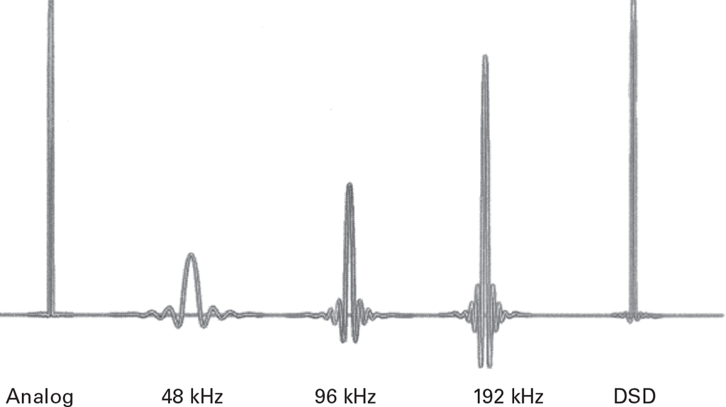

**图 3.8** *模拟脉冲（左*）的脉冲响应（*从左到右*），分别由 48 kHz、96 kHz、192 kHz 和直接数字流 (DSD) 录音系统录制。DSD 将在第 4 章中讨论。

**Figure 3.8** Impulse responses (*left to right*) of an analog impulse (*left*) as recorded by 48 kHz, 96 kHz, 192 kHz, and direct digital stream (DSD) recording systems. DSD is discussed in chapter 4.

有人认为更高采样率的合理性在于，有些人听到的信息（称为*空气声*）在人类听觉极限 20 kHz 左右的区域（Neve 1992）。许多模拟系统可以重现超高频。像 Sanken CO-100K 这样的麦克风可以录制高达 100 kHz 的声音。一些麦克风前置放大器的带宽甚至远远超过 200 kHz。

One justification that has been given for higher sampling rates is that some people hear information (referred to as *air*) in the region around the 20 kHz limit of human hearing (Neve 1992). Many analog systems can reproduce ultrahigh frequencies. Microphones like the Sanken CO-100K can record sounds up to 100 kHz. Some microphone preamplifiers have a bandwidth that extends far beyond 200 kHz.

科学实验从生理和主观角度证实了 22 kHz 以上声音的影响（Oohashi 等人，1991；Oohashi 等人，1993）。然而，Melchior（2019）指出，高分辨率录音的音质提升，即使高频听力不佳的人也能听得懂。她观察到，砖墙式滤波器固有的、低于 50 kHz 的采样率带来的*时间模糊、前回声*和*振铃效应*是造成这些影响的因素，并列举了几种可以缓解这些现象的高分辨率方案。

Scientific experiments confirm the effects of sounds above 22 kHz from both physiological and subjective viewpoints (Oohashi et al. 1991; Oohashi et al. 1993). Melchior (2019), however, points out how the improved quality of high-resolution recordings can be heard by people without extraordinary high-frequency hearing. She observes that the *temporal blur, pre-echo,* and *ringing* inherent in brick-wall filters associated with sampling rates below 50 kHz are contributing factors, and she lists several high-resolution schemes that alleviate these symptoms.

高分辨率的另一个论点是由于存在更多高频空间信息而产生的更集中的空间成像。

Another argument for high resolution is the more focused spatial imaging that accrues due to the presence of more high-frequency spatial information.

在声音合成应用中，44.1 和 48 kHz 标准采样率缺乏*频率余量*是造成严重问题的根源条件。为了避免混叠，它要求合成算法只能生成高于 11.025 kHz（44.1 kHz 采样率）或 12 kHz（48 kHz 采样率）的正弦波。原因是任何非正弦周期波形都可能包含超过奈奎斯特频率的分音。

In sound synthesis applications, the lack of *frequency headroom* in standard sampling rates of 44.1 and 48 kHz is a source of serious problems. It requires that synthesis algorithms generate nothing other than sine waves above 11.025 kHz (44.1 kHz sampling rate) or 12 kHz (48 kHz sampling rate) in order to avoid aliasing. The reason is that any nonsinusoidal periodic waveform can have partials that exceed the Nyquist rate.

在采样和*音高变换*应用中（参见第31章），由于频率余量不足，采样声音在音高向上变换之前需要进行低通滤波，以避免混叠。当以44.1 kHz或48 kHz录制的音调向下变换音高时，它们会变得低沉，并丢失高频内容，因为奈奎斯特频率以上的所有声音都已被抗混叠滤波器消除。在高采样率的录音中，音高向下变换并不一定意味着高频内容的丢失，因为超声波能量会被转置到高频音频范围内。

In sampling and *pitch-shifting* applications (see chapter 31), the lack of frequency headroom requires that sampled sounds be lowpass filtered before they are pitch-shifted upward to avoid aliasing. When tones recorded at 44.1 or 48 kHz are pitch-shifted downward, they become muffled and lose their high-frequency content because everything above the Nyquist frequency has already been eliminated by the antialiasing filter. In a recording made at a high sampling rate, pitch-shifting downward does not necessarily mean a loss of high frequency content, because ultrasonic energy is transposed into the high-frequency audio range.

从音频角度来看，高采样率录音固然可取，但高质量的播放系统才能让这一切努力物有所值。许多人用连接移动设备的低质量耳机听音乐，这浪费了高分辨率录音的宝贵资源。

High sampling rate recordings are preferable from an audio standpoint, but one needs a high-quality playback system to make the effort worthwhile. Many people listen to music on low-quality ear buds connected to mobile devices, where the luxury of high-resolution recordings is wasted.

## **抖动**

## **Jitter**

*抖动*是采样过程中基于时间的误差。如果驱动 ADC 或 DAC 的时钟不稳定，转换将无法在正确的时间进行。抖动的典型听觉效应是信号中出现高频咔嗒声。

*Jitter* is time-based error in sampling. If the clock driving the ADC or DAC is not stable, then the conversions will not happen at the correct times. A typical audible effect of jitter is a high-frequency clicking noise added to the signal.

在家庭录音室中，抖动不太可能成为问题。当多个物理设备互连时，抖动的可能性会增加。抖动可能由多种因素造成：时钟不稳定、线缆/连接器质量差、阻抗不匹配或软件问题。因此，抖动是复杂数字音频系统中的一个实际问题。解决抖动问题的一般方法是依靠一个*主字时钟发生器*设备，该设备通过高质量的线缆和连接器与所有其他设备互连。

In a home studio, jitter is not likely to be an issue. The possibility of jitter increases when multiple physical devices are interconnected. Jitter can be a product of multiple factors: clock instability, poor cable/connector quality, impedance mismatches, or software issues. Thus jitter is a practical issue in complex digital audio systems. The general solution to jitter problems is to rely on a *master wordclock generator* device that is interconnected to all other devices via high-quality cables and connectors.

采样率决定了数字系统测量连续信号的频率。下一章将讨论量化，即数字系统测量信号幅度的精确度。采样和量化这两个过程共同构成了数字音频理论的核心。

The sampling rate determines how often a digital system measures a continuous signal in time. The next chapter presents the topic of quantization, that is, how precisely a digital system measures a signal in amplitude. Taken together, these two processes, sampling and quantization, constitute the core of digital audio theory.

# *4 样本量化、转换和音频格式*

# *4 Sample Quantization, Conversion, and Audio Formats*

**更多关于声音强度的信息**

**More on Sound Magnitude**

**分贝**

**Decibels**

**量化**

**Quantization**

**信噪比和动态范围**

**Signal-to-Noise Ratio and Dynamic Range**

**量化噪声**

**Quantization Noise**

**低级量化噪声和抖动**

**Low-Level Quantization Noise and Dither**

**转换器线性度**

**Converter Linearity**

**过采样转换器**

**Oversampling Converters**

**1位转换器**

**1-Bit Converters**

**噪声整形**

**Noise Shaping**

**数字音频媒体和格式**

**Digital Audio Media and Formats**

**无损与有损文件格式**

**Lossless versus Lossy File Formats**

本章将探讨数字音频录制中声音幅度的概念。之后，我们将探讨动态范围、量化、过采样以及数字音频媒体和格式等技术问题。

This chapter examines the notion of sound magnitude as it pertains to digital audio recording. We then look at the technical issues surrounding dynamic range, quantization, oversampling, and digital audio media and formats.

## **更多关于声音强度的信息**

## **More on Sound Magnitude**

正如第二章所指出的，每个人对声音的强度或大小都有一个直观的概念。科学家们发明了几十个术语来描述声音的强度。其中包括：

As pointed out in chapter 2, everyone has an intuitive notion of sound level or magnitude. Dozens of terms have been devised by scientists to describe the magnitude of a sound. Among many are the following:

- 峰峰值幅度
- Peak-to-peak amplitude
- 均方根幅度
- RMS amplitude
- 获得
- Gain
- 声能
- Sound energy
- 声功率
- Sound power
- 声强
- Sound intensity
- 声压级
- Sound pressure level
- 响度
- Loudness

从科学角度来看，这些术语各不相同。但从常识角度来看，这些术语彼此关联且成比例：一个术语的显著增强对应着所有术语的增强。我们的耳朵对声音的强度有着敏锐的感知，因此这个概念是物理的，可以直接感知的。

From a scientific point of view, these terms are all different. From a common sense point of view, the terms are all correlated and proportional to one another: a significant boost in one corresponds to a boost in all. Our ears are sharply attuned to sound magnitude, so the concept is physical and directly perceivable.

从音乐角度来看，最有用的科学术语是峰峰值和均方根振幅（在声音编辑器中可以看到）、增益（用于增强或衰减声音的标准术语）、声压级（声级计在空气中测量的值）和响度（感知到的幅度）。物理学家使用声能、声功率和声强来描述声级相对于所做功（即振动介质所需的能量）的测量值。

From a musical point of view, the most useful scientific terms are peak-to-peak and RMS amplitude (as seen in a sound editor), gain (a standard term for boosting or attenuating a sound), sound pressure level (what a sound-level meter measures in the air), and loudness (perceived magnitude). Sound energy, power, and intensity are terms used by physicists to describe measures of sound magnitude relative to the amount of work done, that is, how much energy it takes to vibrate a medium.

表 4.1总结了这些术语的正式定义。图 4.1展示了三个最重要的测量指标：峰值、峰峰值和均方根幅度。本节的其余部分将解释分贝这个有用的概念。

Table 4.1 summarizes the formal definitions of these terms. Figure 4.1 illustrates three of the most important measures: peak, peak-to-peak, and RMS amplitude. The rest of this section explains the useful concept of decibels.

[output not shown]

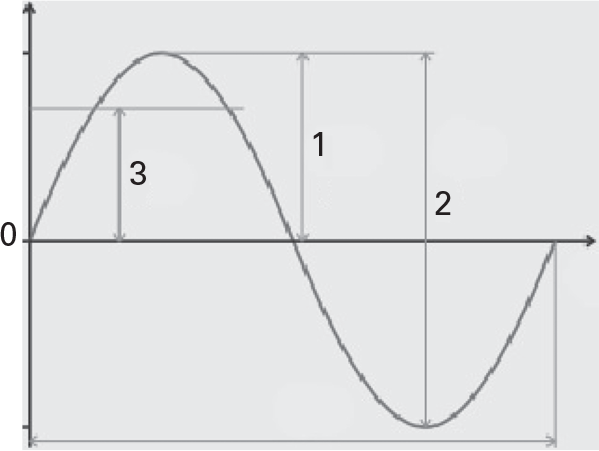

**图 4.1** 幅度测量。（1）峰值幅度。（2）峰峰值幅度。（3）均方根幅度。

**Figure 4.1** Measures of amplitude. (1) Peak amplitude. (2) Peak-to-peak amplitude. (3) RMS amplitude.

### **分贝**

### **Decibels**

耳朵是极其敏感的器官。假设我们坐在扬声器前三米处，扬声器发出1000赫兹的正弦波，我们听起来非常响亮。令人惊讶的是，即使将功率降低一百万倍，音调仍然清晰可闻。在消除所有外部声音的消声室中，功率降低幅度可达十亿倍以上（Backus 1977）。

The ear is an extremely sensitive organ. Suppose that we sit three meters in front of a loudspeaker that is generating a sine tone at 1,000 Hz that we perceive as being very loud. Amazingly, one can reduce the power by a factor of one million and the tone is still audible. In an anechoic chamber where all external sounds are eliminated, the reduction extends to a factor of more than one billion (Backus 1977).

声音传输的是声源振动产生的能量。声能的范围涵盖了从蝴蝶的亚音速振翅到巨大的爆炸等各种声音。耳语声只能产生几十亿分之一瓦的功率。相比之下，一次大型火箭发射可以产生约1000万瓦的功率。

Sound transports energy generated by the vibration of a source. The range of sound energy encompasses everything from the subsonic flutterings of a butterfly to massive explosions. A whisper produces only a few billionths of a watt. By contrast, a large rocket launch generates about 10 million watts of power.

分贝 (dB) 单位通过对数将这些巨大的指数变化压缩到更小的范围内。dB 单位可以应用于无数的物理现象；然而，其定义会根据被测量的现象而变化。音频中的一个标准单位是 dB SPL。它将给定的声压级 (SPL) 与标准参考级进行比较。该比率的对数（以 10 为底）就是分贝级，因此

The decibel (dB) unit compresses these huge exponential variations into a smaller range by means of logarithms. The dB unit can be applied to myriad physical phenomena; however, the definition changes according to the phenomenon being measured. A standard unit in audio is dB SPL. This compares a given sound pressure level (SPL) with a standard reference level. The logarithm (base 10) of this ratio is the level in decibels, hence

声压级（分贝）= 20 log <sub>10</sub> ( *W* / *W* <sub>0</sub> )

SPL in decibels = 20 log<sub>10</sub> (*W*/*W*<sub>0</sub>)

其中*W*是被测信号的实际声压级 (SPL)，*W* <sub>0</sub>是 20 微帕斯卡气压的标准参考水平。这相当于人类能听到的最小声音。

where *W* is the actual SPL of the signal being measured, and *W*<sub>0</sub> is a standard reference level of 20 micropascals of air pressure. This corresponds to the quietest sound that a human being can hear.

用 dB 来描述声级可以实现更宽的范围。表 4.2显示了分贝单位如何将百分比幅度的较大变化压缩为 dB 数的相对较小的变化。

Describing sound levels in terms of dB enables a wide range. Table 4.2 shows how the decibel unit compresses large changes in percentage amplitude into relatively small changes in the number of dB.

| **表 4.2** 振幅百分比与分贝 **Table 4.2** Amplitude as a percentage versus as decibels |  |  |
| --- | --- | --- |
| 100% 100% |  | 0分贝 0 dB |
| 70% 70% |  | − 3 分贝 −3 dB |
| 50% 50% |  | − 6 分贝 −6 dB |
| 25% 25% |  | − 12 分贝 −12 dB |
| 12.5% 12.5% |  | − 18 分贝 −18 dB |
| 6.25% 6.25% |  | −24分贝 −24 dB |
| 3.125% 3.125% |  | −30分贝 −30 dB |
| 1.562% 1.562% |  | −36分贝 −36 dB |
| 0.781% 0.781% |  | −42分贝 −42 dB |
| 0.39% 0.39% |  | − 48 分贝 −48 dB |
| 0.195% 0.195% |  | − 54 分贝 −54 dB |
| 0.097% 0.097% |  | − 60 分贝 −60 dB |
| 0.048% 0.048% |  | − 66 分贝 −66 dB |
| 0.024% 0.024% |  | − 72 分贝 −72 dB |
| 0.012% 0.012% |  | − 78 分贝 −78 dB |
| 0.006% 0.006% |  | − 84 分贝 −84 dB |
| 0.003% 0.003% |  | −90分贝 −90 dB |

当我们远离声源时，其声压级 (SPL) 会随着距离的增加而减小。具体来说，距离每增加一倍，声压级 (SPL) 就会降低约 6 dB，这意味着其振幅会减小 50%。这就是著名的*平方反比定律*：强度与距离的平方成反比。

As we move away from a sound source, its SPL diminishes according to the distance. Specifically, each doubling of distance decreases SPL by about 6 dB, which represents a 50% decrease in its amplitude. This is the famous *inverse square law*: intensity diminishes as the square of the distance.

到目前为止，我们一直在讨论振幅和声压级 (SPL)。另外一对术语*——*音量和*响度——*则比较直观。从技术角度来说，响度是指通过对人类进行心理声学测试测得的主观感知强度，而不是实验室仪器测得的声压级。例如，耳朵对 1,000 Hz 到 4,000 Hz 之间的频率特别敏感。这个范围内的音调听起来比其他频率中同等强度的音调更响亮。因此，响度测量属于心理声学的范畴。为了区分响度级（一种感知特性）和声压级（一种物理特性），使用单位方*（*与*John*押韵）。例如，要使声音听起来同样响亮（60 方），大约 30 Hz 的音调需要比 1,000 Hz 的音调增强 40 dB。

So far we have been talking in terms of amplitude and SPL. Another pair of terms*—volume* and *loudness—*are intuitive. Technically, loudness refers to perceived subjective intensity measured through psychoacoustic tests on human beings and not to sound pressure level measured by laboratory instruments. For example, the ear is especially sensitive to frequencies between 1,000 Hz and 4,000 Hz. Tones in this region sound louder than tones of equal intensity in other frequencies. Thus the measurement of loudness falls into the realm of psychoacoustics. In order to differentiate loudness level (a perceptual characteristic) from sound pressure level (a physical characteristic), the unit *phon* (rhymes with *John*) is used. For example, to sound equally loud (60 phons), a tone at about 30 Hz needs to be boosted 40 dB more than a 1,000 Hz tone.

## **量化**

## **Quantization**

以离散时间间隔采样是数字信号与模拟信号之间的主要区别之一。另一个区别是*量化，*即以离散幅度间隔采样。数字信号并非具有无限的精度。它们只能在一定范围内以一定精度表示，而精度会因所用硬件而异。

Sampling at discrete time intervals constitutes one of the major differences between digital and analog signals. Another difference is *quantization,* which is sampling at discrete amplitude intervals. Digital numbers do not have infinite precision. They can be represented only within a certain range and with a certain accuracy, which varies with the hardware used.

### **信噪比和动态范围**

### **Signal-to-Noise Ratio and Dynamic Range**

量化是数字音频质量的一个重要因素。具体来说，每个样本的位数（也称为*样本宽度*、*位深度*或*量化级别）在计算**信噪比*(SNR)时非常重要。SNR 是衡量系统噪声程度的指标：高 SNR 表示低噪声；低 SNR 表示高噪声。

Quantization is an important factor in digital audio quality. Specifically, the number of bits per sample (also called the *sample width*, *bit depth,* or *quantization level*) is important in calculating the *signal-to-noise ratio* (SNR). SNR is a measure of the noisiness of a system: a high SNR means low noise; a low SNR means high noise.

信噪比 (SNR) 衡量的是音频信号强度与噪声强度的比率。在音频系统中，信噪比 (SNR) 定义为标准工作电平（通常为音量表上的 0）与平均工作电平之间的差值。噪声基底水平，以分贝表示。一般而言，模数转换器中每增加一位，信噪比（SNR）就会增加约6 dB。

SNR measures the ratio of the strength of an audio signal to the strength of noise. In an audio system, the SNR is specified as the difference in level between the standard operating level (usually 0 on a VU meter) and the average level of the noise floor, expressed in decibels. In general, each additional bit in the analog-to-digital converter will contribute about 6 dB to the SNR.

另一个测量指标是数字音响系统的*动态范围*(DR)。简单来说，这是系统所能产生的最强声音和最弱声音之间的分贝差。显然，信噪比 (SNR) 和动态范围 (DR) 是相关的；DR 越高，信噪比 (SNR) 也越高。理论上，这很简单。但如果具体规定如何以及使用什么测量单位来计算信噪比 (SNR) 和动态范围 (DR)，情况就会变得更加复杂。如上所述，信噪比 (SNR) 是 0 VU 标准工作电平与本底噪声之间的差值。动态范围 (DR) 是本底噪声与失真点之间的差值。因此，动态范围 (DR) 取决于测量失真的方法，而人们对失真的定义各不相同。

Another measurement is the *dynamic range* (DR) of a digital sound system. In simple terms, this is the difference in dB between the loudest and softest sounds that the system can produce. Clearly, SNR and DR are correlated; when the DR is high, so is the SNR. In theory, this is straightforward. It becomes more complicated when stipulating exactly how and in what units of measurement SNR and DR are calculated. As mentioned, the SNR is the difference between the standard operating level of 0 VU and the noise floor. The DR is the difference between the noise floor and the point of distortion. Thus the DR depends on a method of measuring distortion, which people define in different ways.

为了我们的目的，数字音频系统动态范围的简单公式是

For our purposes, a simple formula for the dynamic range of a digital audio system is

动态范围（分贝）=位数× 6.11

Dynamic range in decibels = Number of bits × 6.11

6.11 这个数字与理论最大值非常接近（van de Plaasche 1983；van de Plaasche 和 Dijkmans 1983；Hauser 1991）；实际上，6.0 是一个更现实的数字。Mathews (1969) 和 Blesser (1978) 给出了该公式的推导。

The number 6.11 is a close approximation to the theoretical maximum (van de Plaasche 1983; van de Plaasche and Dijkmans 1983; Hauser 1991); in practice, 6.0 is a more realistic figure. A derivation of this formula is given in Mathews (1969) and Blesser (1978).

因此，如果我们使用 8 位系统录制声音，动态范围 (DR) 的上限约为 48 dB。这与低信噪比 (SNR) 相关，并且会产生明显的噪声。但如果我们以 16 位/样本录制，动态范围将提升至最高 96 dB，这是一个重大改进。16 位音频成为了光盘的标准。20 位转换器可提供 120 dB 的潜在动态范围，大致相当于人耳的听觉范围。

Thus, if we record sound with an 8-bit system, then the upper limit on the DR is approximately 48 dB. This is correlated with a low SNR and is audibly noisy. But if we record 16 bits per sample, the dynamic range increases to a maximum of 96 dB—a major improvement. 16-bit audio became the standard of the compact disc. A 20-bit converter offers a potential DR of 120 dB, which corresponds roughly to the range of the human ear.

本讨论假设我们使用*线性PCM*方案，该方案将每个样本存储为一个表示其值的整数。Blesser (1978)、Moorer (1979b) 和 Pohlmann (2010) 已经探讨了其他编码方案的影响。一些编码方案（例如，稍后讨论的MP3）的目标是减少系统存储或传输的总比特数。

This discussion assumes that we are using a *linear PCM* scheme that stores each sample as an integer representing the value of each sample. Blesser (1978), Moorer (1979b), and Pohlmann (2010) have reviewed the implications of other encoding schemes. Some encoding schemes (e.g., MP3, discussed later) have the goal of reducing the total number of bits that the system stores or transmits.

### **量化噪声**

### **Quantization Noise**

样本通常用整数表示。例如，如果输入信号的电压对应于 53 到 54 之间的样本值，那么转换器可能会将其四舍五入并赋值为 53。一般来说，对于每个样本，样本值通常与原始信号值略有不同。数字信号中的这种问题被称为*量化误差*或*量化噪声*（Blesser 1978；Maher 1992；Lipshitz、Wannamaker 和 Vanderkooy 1992；Pohlmann 2010）。

Samples are often represented as integers. If the input signal has a voltage corresponding to a sample value between 53 and 54, for example, then the converter might round it off and assign a value of 53. In general, for each sample taken, the value of the sample usually differs slightly from the value of the original signal. This problem in digital signals is known as *quantization error* or *quantization noise* (Blesser 1978; Maher 1992; Lipshitz, Wannamaker, and Vanderkooy 1992; Pohlmann 2010).

图 4.2显示了可能发生的量化误差类型。当输入信号像交响乐一样复杂时，我们只听误差（如图 4.2底部所示），听起来就像噪音。如果误差很大，那么我们可能会在系统输出端听到类似于模拟磁带的嘶嘶声。

Figure 4.2 shows the kinds of quantization errors that can occur. When the input signal is something complicated like a symphony, and we listen to just the errors, shown at the bottom of figure 4.2, it sounds like noise. If the errors are large, then one might notice something similar to analog tape hiss at the output of a system.

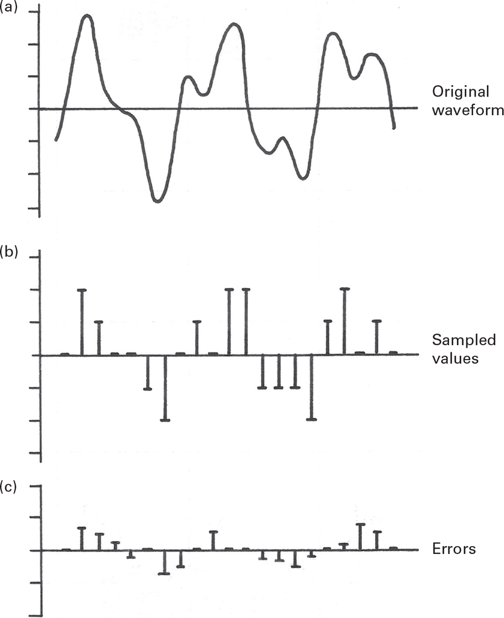

**图 4.2** 量化效应。(a) 模拟波形。(b) (a) 中波形的采样版本。每个样本只能分配特定的值，这些值由左侧的短水平虚线表示。(c) 显示了每个样本与原始信号之间的差异，其中每个条形的高度代表量化误差。

**Figure 4.2** Effects of quantization. (a) Analog waveform. (b) Sampled version of the waveform in (a). Each sample can be assigned only certain values, which are indicated by the short horizontal dashes at the left. The difference between each sample and the original signal is shown in (c), where the height of each bar represents the quantization error.

量化噪声取决于两个因素：输入信号本身，以及信号以数字形式表示的精度。我们可以通过以下例子来解释输入信号对噪声的敏感性：在模拟磁带录音机上，磁带会产生一种轻微的噪声晕，即使在录制的静音时段内也会持续存在。但在数字系统中，当没有录制任何内容（或静音）时，不存在量化噪声。换句话说，如果如果输入信号为静默信号，则该信号由一系列样本表示，每个样本恰好为零。对于这样的信号，图 4.2c中显示的细微差异消失了，这意味着量化噪声消失了。然而，如果输入信号是纯正弦波，则量化误差不是随机函数，而是一种确定性的截断效应，在低电平时可能会听起来很刺耳（Maher 1992；Stuart and Craven 2019）。我们将在抖动部分进一步讨论这一点。

The quantization noise is dependent on two factors: the input signal itself, and the accuracy with which the signal is represented in digital form. We can explain the sensitivity to noise in the input signal by noting that on an analog tape recorder, tape imposes a soft halo of noise that continues even through periods of recorded silence. But in a digital system there is no quantization noise when nothing (or silence) is recorded. In other words, if the input signal is silence, then the signal is represented by a series of samples, each of which is exactly zero. The small differences shown in figure 4.2c disappear for such a signal, which means that the quantization noise disappears. If the input signal is a pure sinusoid, however, then the quantization error is not a random function but a deterministic truncation effect that can be audibly gritty at low levels (Maher 1992; Stuart and Craven 2019). We discuss this further in the section on dithering.

量化噪声的第二个因素是数字表示的精度。在用整数表示每个样本值的线性PCM系统中，量化噪声与用于表示样本的位数直接相关。如前所述，这就是系统的*量化级别。*图4.3展示了不同量化级别的影响，比较了1位和4位量化的分辨率。通常，在线性PCM系统中，用于表示样本的位数越多，量化噪声越小。

The second factor in quantization noise is the accuracy of the digital representation. In a linear PCM system that represents each sample value by an integer, quantization noise is directly tied to the number of bits that are used to represent a sample. As previously noted, this is the *quantization level* of a system. Figure 4.3 illustrates the effects of different quantization levels, comparing the resolution of 1-bit versus 4-bit quantization. In a linear PCM system generally, the more bits used to represent a sample, the less the quantization noise.

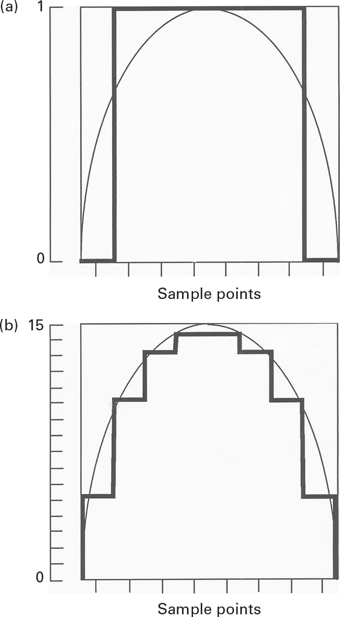

**图 4.3** 比较 4 位量化与 1 位量化的精度。细圆曲线为输入波形。(a) 1 位量化提供两种级别的幅度分辨率。(b) 4 位量化提供十六种不同级别的幅度分辨率。

**Figure 4.3** Comparing the accuracy of 4-bit quantization with that of 1-bit quantization. The thin rounded curve is the input waveform. (a) 1-bit quantization provides two levels of amplitude resolution. (b) 4-bit quantization provides sixteen different levels of amplitude resolution.

Figure 4.4 shows the improvement in sine wave accuracy achieved by adding more bits of resolution, going from 2<sup>4</sup> (sixteen possible values) to 2<sup>8</sup> (256 possible values). Consider the improvement in precision accrued by using a 24-bit sample with 2<sup>24</sup> or more than 16.7 million possible values.

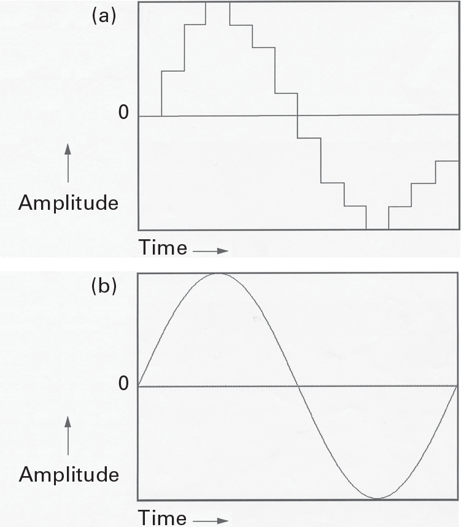

**图 4.4** 量化对正弦波平滑度的影响。（a）具有十个量化级别的正弦波，对应于 4 位系统发出的中等音量音调。（b）8 位系统发出的更平滑的正弦波。

**Figure 4.4** Effect of quantization on sine wave smoothness. (a) Sine wave with ten levels of quantization, corresponding to a moderately loud tone emitted by a 4-bit system. (b) Smoother sinusoid emitted by an 8-bit system.

采样过程可以看作是将波形拟合到时间与幅度的网格中，如图4.5所示。通常，网格越精细，与原始波形的近似度就越高。更具体地说，时间网格（或采样率）越精细，带宽就越大。幅度网格（或量化级别）越精细，动态范围就越大，噪声量就越小。

The process of sampling can be viewed as fitting a waveform to a grid of time versus amplitude, as shown in figure 4.5. In general, the finer the grid, the better the approximation to the original waveform. More specifically, the finer the time grid (or sampling rate), the greater the bandwidth. The finer the amplitude grid (or quantization level), the greater the dynamic range and the smaller the amount of noise.

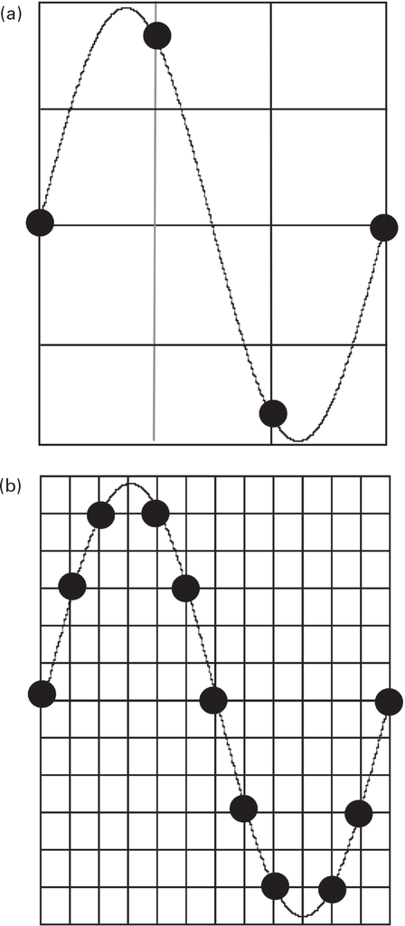

**图 4.5** 采样网格。横轴表示时间，纵轴表示振幅。(a) 低采样率和低量化导致的正弦波形的粗略近似。(b) 提高网格分辨率可以更好地近似波形。网格分辨率越高，波形越接近原始波形。

**Figure 4.5** The sampling grid. The horizontal axis is time. The vertical axis is amplitude. (a) Crude approximation of a sine waveform caused by low sampling rate and low quantization. (b) Increasing grid resolution results in a better approximation to the waveform. Greater increases in grid resolution would closely approximate the original waveform.

### **低级量化噪声和抖动**

### **Low-Level Quantization Noise and Dither**

虽然数字系统在没有输入信号时不会出现噪声，但在非常低（但非零）的信号电平下，量化噪声会呈现出有害的形式。这种粗糙的声音被称为*颗粒噪声*或*调制噪声*，当低电平音调衰减至无声时可以听到。非常低电平的信号只会在最低位触发变化。这些1位变化看起来像一个方波，它富含奇次谐波。以钢琴音调的衰减为例，它会平滑地衰减，高音部分会滚降——直到最低电平，它才会改变特性，变成听起来刺耳的方波。方波的谐波甚至可以超出奈奎斯特频率，从而导致混叠并引入原始信号中没有的新频率成分。如果信号保持在较低的监听电平，这些伪像或许可以忽略，但如果信号在高电平听到，或者被重新调整到更高的电平（这是音频处理中的常见做法），在电子音乐中，这一点变得更加明显。因此，在输入阶段尽可能准确地量化信号非常重要。

Although a digital system exhibits no noise when there is no input signal, at very low (but nonzero) signal levels, quantization noise takes a pernicious form. This gritty sound, called *granulation noise* or *modulation noise*, can be heard when low-level tones decay to silence. A very low-level signal triggers variations only in the lowest bit. These 1-bit variations look like a square wave, which is rich in odd harmonics. Consider the decay of a piano tone, which smoothly attenuates with high partials rolling off—right until the lowest level when it changes character and becomes a harsh-sounding square wave. The harmonics of the square wave can extend even beyond the Nyquist frequency, causing aliasing and introducing new frequency components that were not in the original signal. These artifacts may be possible to ignore if the signal is kept at a low monitoring level, but if the signal is heard at a high level or if it is rescaled to a higher level (a common practice in electronic music), it becomes more obvious. Hence it is important that the signal be quantized as accurately as possible at the input stage.

为了解决低电平量化问题，一些数字录音系统采取了一种看似奇怪的做法。它们在模数转换之前向信号中引入少量不相关的噪声——称为*抖动*（Vanderkooy 和 Lipshitz，1984 年；Lipshitz 等人，1992 年；Stuart 和 Craven，2019 年）。这会导致 ADC 围绕低电平信号进行随机变化，从而平滑方波谐波的有害影响（图 4.6）。抖动会将通常与信号相关的量化误差转化为与信号不相关的宽带噪声。对于像前面提到的钢琴音调这样的渐弱音，其效果就像软着陆一样，音调平滑地淡入基调。低水平随机噪声。添加的噪声量通常在 3 dB 左右，但耳朵可以重建幅度低于抖动信号的音乐音调。

To confront low-level quantization problems, some digital recording systems take a seemingly strange action. They introduce a small amount of uncorrelated noise—called *dither*—to the signal prior to analog-to-digital conversion (Vanderkooy and Lipshitz 1984; Lipshitz et al. 1992; Stuart and Craven 2019). This causes the ADC to make random variations around the low-level signal, which smooths out the pernicious effects of square wave harmonics (figure 4.6). With dither, the quantization error, which is usually signal-dependent, is turned into a wideband noise that is uncorrelated with the signal. For decrescendos like the piano tone mentioned previously, the effect is that of a soft landing as the tone fades smoothly into a bed of low-level random noise. The amount of added noise is usually on the order of 3 dB, but the ear can reconstruct musical tones whose amplitudes fall below that of the dither signal.

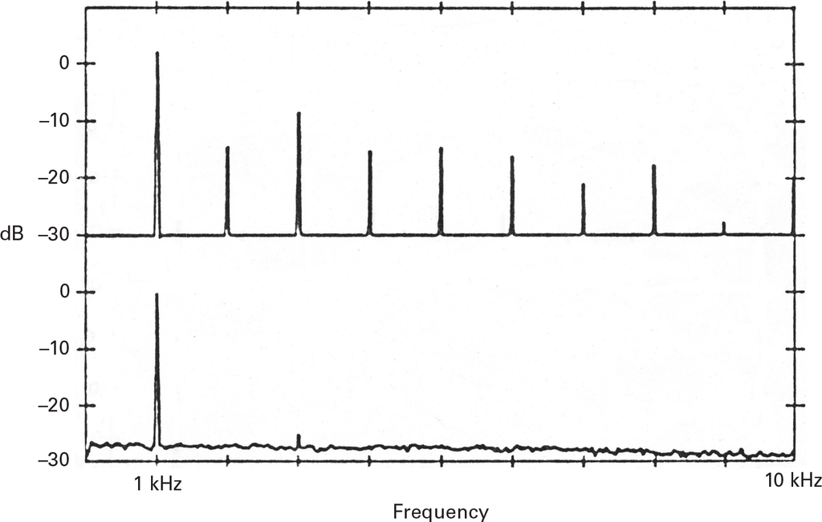

**图 4.6** 抖动减少谐波失真。（*顶部*）原始信号。（*底部*）抖动后信号。

**Figure 4.6** Dither reduces harmonic distortion. (*Top*) Original signal. (*Bottom*) Postdithered signal.

在 16 位量化级别录音时，建议使用抖动。使用 24 位转换器录音时，可能无需添加抖动，因为低位代表极其柔和的信号。但例如，在将信号从 24 位重新量化为 16 位格式时，建议使用抖动以保持信号保真度 (Stuart and Craven 2019)。抖动算法有很多，因此声音编辑器和母带处理插件通常会提供多种选项。

Dithering is recommended in recording at a 16-bit quantization level. Adding dither may not be necessary in recording with a 24-bit converter because the low bit represents an extremely soft signal. But in requantizing signals from a 24-bit to a 16-bit format, for example, dithering is recommended to preserve signal fidelity (Stuart and Craven 2019). Many dithering algorithms exist, so sound editors and mastering plug-ins often provide a variety of options.

### **转换器线性度**

### **Converter Linearity**

音频转换器会导致各种失真（Blesser 1978；McGill 1985；Talambiras 1985；Pohlmann 2010）。其中一个问题是，*n*位转换器不一定能精确到其*n*位输入或输出所隐含的整个动态范围。虽然*n*位转换器的*分辨率是**2n*分之一，但转换器的*线性度*是指模拟和数字输入输出信号在幅度方面的匹配程度。也就是说，有些转换器使用 2n*个*步长，但这些步长并不是线性分布的，这会导致失真。因此，遇到一个 24 位转换器实际上是 19 位线性转换器的情况并不罕见。有关这些问题的讨论，请参阅 Pohlmann (2010)。

Audio converters can cause a variety of distortions (Blesser 1978; McGill 1985; Talambiras 1985; Pohlmann 2010). One such problem is that an *n-*bit converter is not necessarily accurate to the full dynamic range implied by its *n*-bit input or output. Although the *resolution* of an *n-*bit converter is one part in 2*n*, a converter’s *linearity* is the degree to which the analog and digital input and output signals match in terms of their magnitudes. That is, some converters use 2*n* steps, but these steps are not linearly spaced, which causes distortion. Hence it is not unusual to encounter a 24-bit converter, for example, that is actually 19 bits linear. Refer to Pohlmann (2010) for a discussion of these issues.

## **过采样转换器**

## **Oversampling Converters**

在我们描述的数字音频系统中，*多位线性 DAC*一步将二进制样本值转换为模拟电压。也就是说，它们在每个采样周期内转换 16 到 24 位的样本。相应地，多位线性 ADC 执行相反的操作：将模拟电压转换为多位样本。

In the digital audio systems that we have described, *multibit linear DACs* transform a binary sample value into an analog voltage in one step. That is, they convert a sample of 16 to 24 bits at each sample period. Correspondingly, multibit linear ADCs perform the inverse operation: converting an analog voltage into a multibit sample.

相比之下，*过采样转换器*在转换阶段使用的样本比实际存储在记录介质中的样本要多。就我们的目的而言，介绍基本概念就足够了，为那些希望进一步研究该主题的人留下参考。

By contrast, *oversampling converters* use more samples in the conversion stage than are actually stored in the recording medium. For our purposes it is sufficient to present the basic ideas, leaving references for those who wish to investigate the topic further.

过采样是一类用于提高转换器精度的方法。大多数方法依赖于1位过采样（Adams 1990；Hauser 1991；Reiss 2008）。这些方法以较高的采样频率，每次仅转换一位。

Oversampling is a family of methods for increasing the accuracy of converters. Most methods rely on 1-bit oversampling (Adams 1990; Hauser 1991; Reiss 2008). These methods convert just one bit at a time at a high sampling frequency.

### **1位转换器**

### **1-Bit Converters**

1 位过采样转换器的理论可以追溯到 20 世纪 50 年代（Cutler，1960），但这项技术却花了数年时间才融入数字音频系统。1 位过采样转换器构成了一系列不同的根据制造商的不同，这些技术也被称为*sigma-delta*、*delta-sigma*、*噪声整形*、*比特流*、*MASH*或*直接数字流 (DSD)*。在手机和大功率扩声系统中流行的 D 类放大器就采用了这项技术 (Reiss 2008)。

The theory of 1-bit oversampling converters goes back to the 1950s (Cutler 1960), but it took years for this technology to become incorporated into digital audio systems. The 1-bit oversampling converters constitute a family of different techniques that are variously called *sigma-delta*, *delta-sigma*, *noise shaping*, *bitstream*, *MASH*, or *direct stream digital (DSD)*, depending on the manufacturer. Class D amplifiers, popular in mobile phones and high-power sound reinforcement systems, incorporate this technology (Reiss 2008).

它们有一个共同点，即以高采样频率一次采样一位。也就是说，这些转换器不是试图在单个样本中表示整个波形，而是测量连续样本之间的差异。它们只需要测量波形自上次采样以来是发生了正向偏移还是负向偏移，但由于它们测量频率很高，波形没有时间发生较大的偏移，因此每个采样周期 1 位信息就足够了。

They have the common thread that they sample one bit at a time at high sampling frequencies. That is, rather than trying to represent the entire waveform in a single sample, these converters measure differences between successive samples. They need to measure only whether the waveform has made a positive or negative excursion since it was last sampled, but they do this so frequently that the waveform does not have time to make a large excursion, and so 1 bit of information per sample period is sufficient.

1 位转换器利用了信息论的一条基本定律（Shannon 和 Weaver，1949），该定律认为，人们可以用采样宽度换取采样率，同时仍能保持相同的转换分辨率。也就是说，一个以存储采样率 16 倍过采样的 1 位转换器，其性能与一个没有过采样的 16 位转换器相当。它们处理的位数相同。当采样率高得多时，过采样的优势会显现出来，这意味着处理的位数大于输入位数。

1-bit converters take advantage of a fundamental law of information theory (Shannon and Weaver 1949), which says that one can trade off sample width for sample rate and still convert at the same resolution. That is, a 1-bit converter that oversamples at sixteen times the stored sample rate is equivalent to a 16-bit converter with no oversampling. They both process the same number of bits. The benefits of oversampling accrue when the sampling rate is much higher, meaning that the number of bits being processed is greater than the number of input bits.

描述采样系统的一种方法是根据关系确定正在处理的总位数

One way to describe a sampling system is to determine the total number of bits being processed, according to the relation

过采样因子×转换器宽度

Oversampling factor × Width of converter

例如，一个使用 1 位转换器的 128 倍过采样系统每个采样周期处理 128 × 1 位数据。相比之下，传统的 16 位线性转换器只能处理 1 × 16 位数据，即八分之一的数据。理论上，过采样的 1 位转换器的声音应该更清晰。

For example, a 128-times oversampling system that uses a 1-bit converter is processing 128 × 1 bits each sample period. This compares to a traditional 16-bit linear converter that handles 1 × 16 bits, or one-eighth the data. In theory, the oversampling 1-bit converter should be much cleaner sounding.

无论如何，过采样的所有优势都归功于1位转换器，包括数字滤波带来的分辨率和相位线性度的提升。多位转换器技术难以实现的高采样率，用1位转换器更容易实现。2.8224 MHz及更高频率范围的过采样率允许每个样本进行高精度量化（Moorer，1996）。瑞士的Pyramix数字音频工作站支持高分辨率DSD录音。DSD已发展成为面向发烧友的高分辨率下载和流媒体格式，一些转换器支持超过22 MHz的过采样率（Melchior，2019）。

In any case, all the benefits of oversampling accrue to 1-bit converters, including increased resolution and phase linearity due to digital filtering. High sampling rates that are difficult to achieve with the technology of multibit converters are much easier to implement with 1-bit converters. Oversampling rates in the 2.8224 MHz and greater range permit highly accurate quantization per sample (Moorer 1996). The Swiss-based Pyramix digital audio workstation supports high-resolution DSD recording. DSD has evolved into a high-resolution download and streaming format for audiophiles, with some converters supporting oversampling rates in excess of 22 MHz (Melchior 2019).

### **噪声整形**

### **Noise Shaping**

1 位过采样转换器中常用的另一种技术是*噪声整形，*它可以有多种形式（Hauser 1991；Reiss 2008）。基本其原理是，过采样过程中产生的*重新量化误差会被一个高通滤波器（该滤波器与输入信号/声道信号）移至高频范围，要么移至不太明显的频带，要么移至音频带宽之外。该**噪声整形环路*仅将重新量化误差（而非音频信号）发送至高通滤波器。

Another technique commonly used in 1-bit oversampling converters is *noise shaping,* which can take many forms (Hauser 1991; Reiss 2008). The basic idea is that the *requantization error* that occurs in the oversampling process is shifted into a high-frequency range, either to a less noticeable frequency band or out of the audio bandwidth, by a highpass filter in a feedback loop with the input sign/al. This *noise-shaping loop* sends only the requantization error through the highpass filter and not the audio signal.

任何过采样转换器的最后一级都是一个抽取器，它将信号的采样率降低到存储（对于 ADC）或播放（对于 DAC）所需的采样率，并对信号进行低通滤波。对于噪声整形转换器，这还会消除重新量化噪声，从而显著提高信噪比。使用*二阶噪声整形*（因反馈环路中使用二阶高通滤波器而得名）时，1 位转换器的最大信噪比大约相当于每倍频程过采样 15 dB（2.5 位），减去固定的 12.9 dB 损失（Hauser 1991）。通过以 256 倍目标采样率运行 20 位转换器，理论上可以实现 24 位分辨率。实际上，1 位过采样中的许多问题都是由非线性量化器周围的反馈引起的。这些包括极限循环、空闲音、失真、死区、不稳定和其他可怕的现象（Reiss 2008）。

The final stage of any oversampling converter is a decimator that reduces the sampling rate of the signal to that required for storage (for an ADC) or playback (for a DAC) and also lowpass filters the signal. In the case of a noise shaping converter this also removes the requantization noise, resulting in dramatic improvements in signal-to-noise ratio. With *second-order noise shaping* (so called because of the second-order highpass filter used in the feedback loop), the maximum signal-to-noise level of a 1-bit converter is approximately equivalent to 15 dB (2.5 bits) per octave of oversampling, minus a fixed 12.9 dB penalty (Hauser 1991). By running a 20-bit converter at 256 times the target sampling rate, one achieves 24-bit resolution, in theory. In practice, a host of issues in 1-bit oversampling are caused by feedback around a nonlinear quantizer. These include limits cycles, idle tones, distortion, dead zones, instability, and other scary phenomena (Reiss 2008).

*第 9 章介绍了采样率转换*相关问题的基础知识，该问题在*多速率信号处理*的工程文本中进行了讨论（Mitra 2006）。

Chapter 9 presents the basics on the related issue of *sample-rate conversion,* which is discussed in engineering texts in the context of *multirate signal processing* (Mitra 2006).

## **数字音频媒体和格式**

## **Digital Audio Media and Formats**

音频样本可以存储在任何数字介质上，通常是光盘、磁盘、固态硬盘和存储芯片。在给定的存储介质上，数据文件可以以多种*音频文件格式存储。*执行音频数据编码和解码的软件称为*编解码器*（编解码器）。

Audio samples can be stored on any digital medium, typically optical or magnetic disks, solid-state drives, and memory chips. On a given storage medium, data files can be stored in a variety of *audio file formats.* The software that performs the encoding and decoding of the audio data is called a *codec* (coder-decoder).

像 AIFF 或 WAVE 这样的音频文件格式是一种数据结构，它将文件划分为多个子部分，每个部分包含特定类型的数据。例如，一个部分规定了采样率、位分辨率以及文件中存储的数字音频通道数。另一个部分包含原始样本数据。其他部分可以包含指向标记、循环点以及其他类型信息（例如文件名、作者、版权等）的指针。

An audio file format like AIFF or WAVE is a data structure that divides the file into subsections, each of which contains a specific type of data. For example, one section stipulates the sample rate, bit resolution, and how many channels of digital audio are stored in the file. Another section contains the raw sample data. Other sections can contain pointers to markers, loop points, and other kinds of information such as file name, author, copyright, and so on.

新的媒体、编解码器和格式正在不断发展。科学进步推动着这些技术的发展，但新媒体、编解码器或格式的引入往往是由商业策略驱动的。

New media, codecs, and formats are constantly being developed. Scientific advances push these technologies, but just as often the introduction of a new medium, codec, or format is driven by a commercial strategy.

### **无损与有损文件格式**

### **Lossless Versus Lossy File Formats**

常见的文件格式有三种：

Three types of file formats are common:

1. 未压缩

1. Uncompressed

2. 无损压缩

2. Compressed lossless

3. 有损压缩

3. Compressed lossy

*未压缩*格式（例如 AIFF 或 WAV）存储全分辨率 PCM 数字音频波形，不进行任何数据缩减。这包括 16 位和 24 位格式，采样率为 22.05 至 384 kHz。一种特殊的未压缩格式是基于 IEEE 754 标准的 32 位*浮点*(FP)。该格式将音频编码为 24 位尾数，可按 8 位指数缩放，从而产生约 1,500 dB 的有效动态范围。Zoom 和 Sound Devices 等公司生产的现场录音机支持 FP 录音。Audacity、Adobe Audition 和 Reaper 等音频编辑器也支持 FP 格式。

An *uncompressed* format (e.g., AIFF or WAV) stores full resolution PCM digital audio waveforms without any data reduction. This includes 16-bit and 24-bit formats at sample rates from 22.05 to 384 kHz. A special uncompressed format is 32-bit *floating-point* (FP), based on the IEEE 754 standard. This format encodes audio as a 24-bit mantissa that can be scaled by an 8-bit exponent, resulting in an effective dynamic range of about 1,500 dB. FP recording is provided in field recorders made by companies such as Zoom and Sound Devices. Audio editors such as Audacity, Adobe Audition, and Reaper also support the FP format.

无损格式的优势在于，它可以通过*数字输入/输出连接器*（播放和录音系统上的硬件插孔）以及*标准数字音频传输格式*（例如 AES3（双通道）、S/PDIF（双通道）、AES10 或 MADI（56 通道）、以太网 802.1 视听桥接 (AVB)（200 通道）和 Dante（1024 通道））实时地将比特从一个介质传输到另一个介质。Johns（2017）解释了以太网音频格式的普及。

An advantage of lossless formats is that one can transfer the bits from one medium to another in real time through *digital input/output connectors* (hardware jacks on the playback and recording systems) and *standard digital audio transmission formats* such as AES3 (two channels), S/PDIF (two channels), AES10 or MADI (56 channels), Ethernet 802.1 audio visual bridging (AVB) (200 channels), and Dante (1024 channels). Johns (2017) explains the proliferation of Ethernet audio formats.

*压缩无损*格式，例如免费无损音频编解码器 (FLAC) 或 Apple 无损 (ALAC)，利用数据中的冗余信息来更高效地打包数据，且不会丢失数据。然而，文件需要先解压才能播放。解压后，原始波形可以完美地重建。常见的 ZIP 和 RAR 文件格式就是压缩无损格式的例子，但由于它们并未针对音频进行优化，因此文件大小通常可以减少 20%。相比之下，像 FLAC 这样的音频专用格式可以将文件大小减少多达 50%。

A *compressed lossless* format, such as free lossless audio codec (FLAC) or Apple lossless (ALAC), takes advantage of redundancies in the data to pack it more efficiently without losing data. However, the file needs to be unpacked before it can be played. The original waveform can be perfectly reconstructed after it is unpacked. The ubiquitous ZIP and RAR file formats are examples of compressed lossless formats, but because they are not optimized for audio they typically achieve a 20 percent reduction in file size. By contrast, an audio-specific format like FLAC can achieve as much as a 50 percent reduction in file size.

*有损压缩*格式（例如 MP3、Vorbis、高级音频编解码器 (AAC)、ATRAC 或 Windows Media Audio）会分析输入文件，以确定为了满足所需的最小比特率而可以丢弃哪些信息。其目标不仅是减小文件大小，还要尽量缩短下载时间。这些格式的音频质量往往比较平庸。

A *compressed lossy* format, such as MP3, Vorbis, advanced audio codec (AAC), ATRAC, or Windows Media Audio), analyzes the input file to determine what information can be thrown away in order to meet a desired minimum bit rate. The goal is not only small file size but also minimum downloading time. The audio quality of these formats tends to be mediocre.

128 kbit/s 的 MP3 文件比同一首歌曲未压缩的 16 位 44.1 kHz 光盘音轨小约 11 倍。这些格式的编解码器通常允许用户选择数据压缩程度或文件编码时会产生损耗。*“有损”*一词指的是 MP3 在编码音频信号时，为了压缩声音文件的大小，会丢弃那些被认为不太清晰的声音部分。具体来说，MP3 会丢弃那些被相邻频率频谱*掩盖*的频率成分，以及那些被发生在其之前不到 5 毫秒的响亮事件*在时间上掩盖的*音调(Hacker 2000)。

A 128 kbit/s MP3 file is about eleven times smaller than an uncompressed 16-bit 44.1 kHz compact disc track of the same song. The codecs associated with these formats usually let users choose the degree of data reduction or loss when the file is encoded. The term *lossy* refers to the fact that as MP3 encodes audio signals, it discards parts of sound that are deemed less audible in order to compress the size of a sound file. Specifically, MP3 throws away frequency components that are *spectrally masked* by neighboring frequencies, as well as tones that are *temporally masked* by loud events that occur less than about 5 ms before them (Hacker 2000).

基于心理声学因素的音频压缩被称为*感知编码*（Gibson 等人，1998）。有损压缩的量由*比特率*参数控制，对于 MP3 来说，比特率通常在 32 到 320 kbit/s 之间，采样率则在 32 到 48 kHz 之间。比特率直接影响文件大小和音频质量；低比特率意味着音频分辨率较低。一种编码选项是*可变比特率*(VBR)，它对简单段落（例如持续音）使用低比特率，对更复杂的段落（例如瞬态或噪声事件）使用高比特率。

Basing audio compression on psychoacoustic factors is called *perceptual coding* (Gibson, et al. 1998). The amount of lossy compression is controlled by the *bit rate* parameter, which for MP3 typically varies from 32 to 320 kbits/s and the sampling rate (from 32 to 48 kHz). The bit rate has a direct impact on both file size and audio quality; a low bit rate means lower audio resolution. One encoding option is *variable bit rate* (VBR) that uses a low bit rate for simple passages (e.g., sustained tones) and a high bit rate for more complex passages, such as transient or noisy events.

本质上，MP3 编码器将输入信号细分为 32 个频谱带，并测量每个频带随时间变化的能量。然后，通过应用感知编码技术，编码器可以大幅精简分析数据。例如，如果任何给定频带中的内容低于听觉阈值（根据频率而变化），编码器就会丢弃该频带。

In essence, an MP3 encoder subdivides the input signal into thirty-two spectral bands and measures the energy in each of these bands over time. Applying perceptual coding techniques, it then greatly reduces the analyzed data. For example, if the content in any given band falls below a threshold of audition (varying according to frequency), the encoder discards that band.

MP3 的播放本质上是由一个加法合成器完成的。MP3 文件专为大众传播而设计，通常使用廉价的扬声器和耳机播放，而这些设备对音质的要求并不高。有关 MP3 文件中各种音质问题的分析，请参阅 Corbett (2012)。

MP3 playback is performed by what is basically an additive synthesizer. Designed for mass distribution, MP3 files are often played back on cheap loudspeakers and earbuds where high audio quality is not a consideration. For an analysis of the myriad problems of sound quality in MP3 files, read Corbett (2012).

MP3 和 AAC（用于 YouTube 音频）等格式诞生于数据存储成本高昂、网络速度以每秒数百比特为单位的时代。如今，存储成本低廉，网络速度以每秒千兆比特为单位。因此，通过有损格式分发音乐的需求减少了，这让录音工程师们松了一口气（Faulkner 2011）。发烧友市场已基本转向高分辨率无损下载和流媒体格式，例如 FLAC、ALAC 和 DSD（Melchior 2019）。

Formats like MP3 and AAC (used in YouTube audio) were conceived when data storage was expensive and network speeds were measured in hundreds of bits per second. Today storage is cheap and network speeds are measured in gigabits per second. Thus the need for music distribution via lossy formats is diminished, much to the relief of recording engineers (Faulkner 2011). The audiophile market has largely moved to high-resolution lossless download and streaming formats such as FLAC, ALAC, and DSD (Melchior 2019).

# **II 声音合成简介**

# **II Introduction to Sound Synthesis**

# *5 数字声音合成的历史*

# *5 History of Digital Sound Synthesis*

**最早的计算机声音**

**Earliest Computer Sounds**

**贝尔电话实验室的实验**

**Experiments at Bell Telephone Laboratories**

**音乐 I 和音乐 II**

**Music I and Music II**

**音乐 III：模块化单元生成器概念**

**Music III: The Modular Unit Generator Concept**

**音乐** *与* **语言**

**Music** *N* **Languages**

本章介绍了计算机生成声音的丰富历史，并引出了模块化单元生成器的复杂概念。

This chapter ambles through the rich history of computer-generated sound, leading to the sophisticated concept of modular unit generators.

## **最早的计算机声音**

## **Earliest Computer Sounds**

早期的数字计算机没有视觉显示器。为了更好地理解它们的运作，程序员们试图将计算过程声音化。例如，当计算机正常运行时，会产生可听见的无线电干扰。技术人员发现，在计算机附近放置一台收音机来监控其运行情况很有用。当声音停止时，表明计算机已停止运行。程序员们很快发现，无线电干扰的声音与程序的逻辑相关。具体来说，当程序以音频速率执行重复循环时，发出的声音是持续的音调。为了娱乐，他们编写了包含不同长度循环的程序，这些循环与流行歌曲的旋律相对应。

Early digital computers did not have visual displays. In order to better understand their operation, programmers sought to sonify computational processes. For example, when a computer was properly operating, it produced audible radio interference. Technicians found it useful to put a radio near the computer to monitor its operation. When the sound stopped, it indicated that the computer had halted. Programmers soon figured out that the sound of the radio interference correlated with the logic of the program. Specifically, when a program executed a repeating loop at an audio rate, the sound was a sustained pitch. For amusement, they wrote programs containing loops of varying lengths that corresponded to the melodies of popular songs.

有些计算机配有扬声器，可以用作输出设备，用于发出程序中发生特定事件（例如程序终止）的信号。在这些机器上，串行输出总线上的原始 1 位脉冲可以发送到扬声器。周期性脉冲循环，中间穿插着延迟，会产生一种被称为“嘟囔”或“咕囔”的音调。

Some computers had a loudspeaker that could be used as an output device to signal that a particular event had occurred in a program, such as program termination. On these machines, raw 1-bit pulses on the serial output bus could be sent to a speaker. A periodic loop of pulses interspersed with delays produced a pitched tone that was called a “blurt” or “hoot.”

1949年，弗朗西斯·E·“贝蒂”·霍尔伯顿（Frances E. “Betty” Holberton）编写了BINAC计算机程序，使其能够为费城埃克特-莫奇利计算机公司的研发团队播放歌曲《因为他是个快乐的好伙伴》（Irrlichtproject 2015）。1951年，澳大利亚CSIRAC和英国曼彻斯特Mark II计算机都通过这种方法播放了流行乐曲（Doornbusch 2005；Link 2007）。这些努力从未被用作正式研究，也未发表任何科学论文。

In 1949, Frances E. “Betty” Holberton programmed the BINAC computer to play “For He’s a Jolly Good Fellow” to the team who built the machine at the Eckert-Mauchly Computer Corporation in Philadelphia (Irrlichtproject 2015). In 1951, both the Australian CSIRAC and the British Manchester Mark II played popular tunes via this method (Doornbusch 2005; Link 2007). These efforts were never intended as formal research, and no scientific papers were published.

当时，用于声音样本的数模转换器 (DAC) 技术尚不存在。这意味着不可能进行广义的波形合成。

The technology of digital-to-analog converters (DACs) for sound samples did not exist at this time. This meant that there was no possibility for generalized waveform synthesis.

## **贝尔电话实验室的实验**

## **Experiments at Bell Telephone Laboratories**

控制计算机生成波形各个方面最常用的方法是根据贝尔电话实验室通信研究员哈罗德·奈奎斯特（Harold Nyquist）于1928年提出*的采样理论*进行合成。首次利用计算机合成声音样本的实验始于1957年，由默里山贝尔电话实验室的研究人员进行。新泽西州（David、Mathews 和 McDonald 1958 年；Roads 1980 年；Wood 1991 年）。

The most general way to control all aspects of a computer-generated waveform is to synthesize it according to the 1928 *theory of sampling* devised by Harold Nyquist, a communications researcher at Bell Telephone Laboratories. The first experiments in the synthesis of sound samples by computer began in 1957 by researchers at Bell Telephone Laboratories in Murray Hill, New Jersey (David, Mathews, and McDonald 1958; Roads 1980; Wood 1991).

马克斯·V·马修斯（图5.1 ）拥有麻省理工学院电气工程博士学位，曾在贝尔实验室工作，师从JR·皮尔斯。马修斯着手利用计算机创作音乐。他编写了一个程序，让计算机生成一系列二进制数字，代表音乐声波（即样本）的连续振幅（Mathews and Guttman 1959）。在实验中，马修斯和他的同事证明了计算机可以根据任何音高或波形合成声音，包括随时间变化的频率、振幅包络和复音。

With a doctorate in electrical engineering from MIT, Max V. Mathews (figure 5.1) worked at Bell Labs under the direction of J. R. Pierce. Mathews set out to use a computer to produce musical tones. He wrote a program that would make a computer generate a sequence of binary numbers representing successive amplitudes of a musical sound wave (i.e., samples) (Mathews and Guttman 1959). In their experiments, Mathews and his colleagues proved that a computer could synthesize sounds according to any pitch scale or waveform, including time-varying frequency and amplitude envelopes and polyphony.

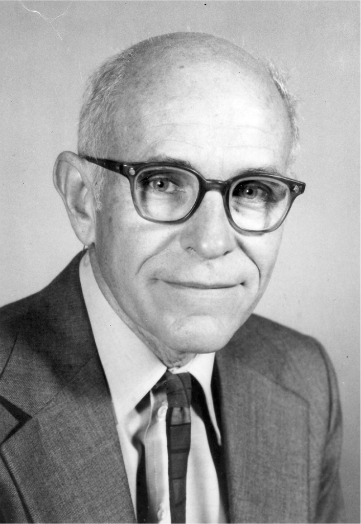

**图 5.1** Max V. Mathews，1981 年。

**Figure 5.1** Max V. Mathews, 1981.

他们的第一个程序是为一台巨型 IBM 704 计算机编写的（图 5.2）。

Their first programs were written for a giant IBM 704 computer (figure 5.2).

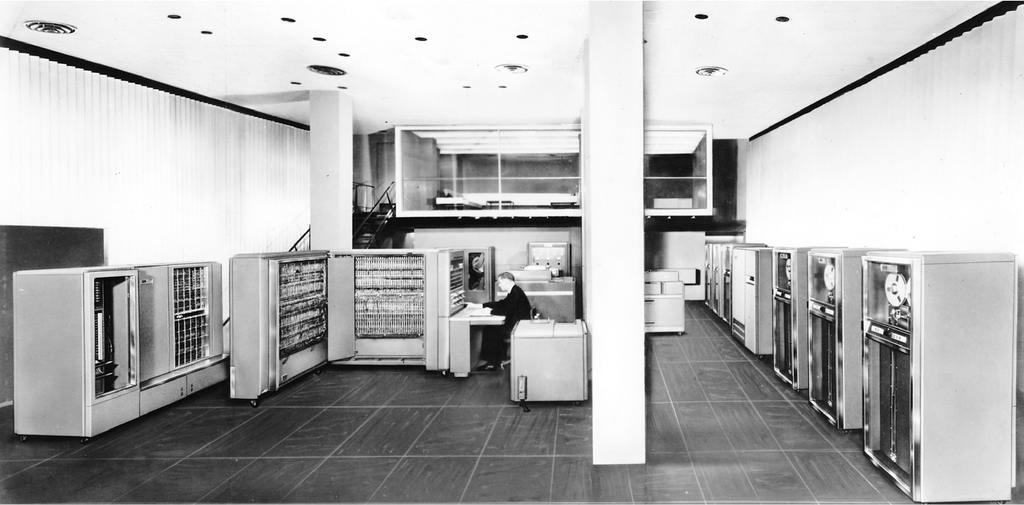

**图 5.2** IBM 704 计算机，1957 年。

**Figure 5.2** IBM 704 computer, 1957.

当时计算机非常稀缺，计算工作不得不在位于曼哈顿麦迪逊大道和57街的IBM全球总部进行。704计算机的使用费按1957年的美元计算为每小时600美元（Johnstone 1994）。该计算机的逻辑电路采用真空管制成（图5.3）。704在当时是一台功能强大的机器，拥有36位字长和内置浮点处理器，可进行快速数值计算。运算。它可以装载高达 32 千字的磁芯存储器，每秒可执行高达 4,000 次乘法运算。声音合成计算耗时数小时。样本被写入数字磁带。12 位真空管 DAC 将样本转换为声音。这款转换器由 Bernard Gordon 设计，是当时世界上唯一能够产生声音的转换器（Roads 1980）。

Computers were so rare at that time that the computation had to be carried out at IBM World Headquarters on Madison Avenue and 57th Street in Manhattan. Use of the 704 computer was billed at $600 per hour in 1957 dollars (Johnstone 1994). The logic circuits of the computer were made using vacuum tubes (figure 5.3) The 704 was a powerful machine for its day, with a 36-bit word length and a built-in floating-point processor for fast numerical operations. It could be loaded with up to 32 kwords of magnetic core memory and execute up to 4,000 multiplications per second. Sound synthesis calculations took hours. The samples were written to a digital magnetic tape. A 12-bit vacuum tube DAC transformed the samples into sound. This converter, designed by Bernard Gordon, was at that time the only one in the world capable of sound production (Roads 1980).

[figure not shown]

**图 5.3** IBM 704 计算机的真空管逻辑模块。

**Figure 5.3** Vacuum tube logic module for the IBM 704 computer.

## **音乐 I 和音乐 II**

## **Music I and Music II**

马修斯开发的“音乐 I”程序生成单一波形：等边三角形。用户只能通过音高和时值来指定音符（Roads 1980）。知觉心理学研究员纽曼·格特曼（Newman Guttman）用“音乐 I”创作了一首单音练习曲，名为*《银阶》（In a Silver Scale）*，创作于1957年5月17日（Guttman 1980）。这是第一首通过数模转换合成的乐曲。格特曼意识到计算机具有精确生成任何频率的潜力，于是将这首乐曲用作实验，对比了两种微音阶：银（1957）描述的等拍半音阶和纯律。

The Music I program developed by Mathews generated a single waveform: an equilateral triangle. A user could specify notes only in terms of pitch and duration (Roads 1980). A perceptual psychology researcher named Newman Guttman made one composition with Music I, a monophonic etude called *In a Silver Scale* written on May 17, 1957 (Guttman 1980). This was the first composition synthesized by the process of digital-to-analog conversion. Recognizing the potential of the computer to generate any frequency precisely, Guttman used the piece as an experiment to contrast two microtonal scales, an equal-beating chromatic scale described by Silver (1957) and just intonation.

马修斯于1958年完成了Music II。它是用汇编语言为IBM 7090计算机编写的，这是一款基于IBM 704改进型计算机。7090的运行速度比老款机器快数倍，因此可以实现更强大的合成算法。Music II提供四种独立的声音，并可在内存中存储十六种波形供选择。贝尔电话实验室的多位研究人员都曾使用过Music II，其中包括马克斯·马修斯、约翰·皮尔斯和纽曼·格特曼。

Mathews completed Music II in 1958. It was written in assembly language for the IBM 7090 computer, an improved computer along the lines of the IBM 704. The 7090 ran several times faster than the older machines. It was thus possible to implement more ambitious synthesis algorithms. Four independent voices of sound were available, with a choice of sixteen waveforms stored in memory. Music II was used by several researchers at Bell Telephone Laboratories, including Max Mathews, John Pierce, and Newman Guttman.

1958年，纽约市举办了一场新*计算机音乐*音乐会，随后由约翰·凯奇主持了一场讨论会。同年晚些时候，格特曼在瑞士格拉韦萨诺赫尔曼·谢尔兴的别墅演奏了他用计算机合成的作品*《音高变奏曲》*，作曲家伊安尼斯·泽纳基斯当时也在场（Guttman 1980）。（我们在第24、25和50章中提到了泽纳基斯。）

A concert of the new *computer music* was organized in 1958 in New York City, followed by a discussion panel moderated by John Cage. Later that year Guttman played his computer-synthesized composition *Pitch Variations* at Hermann Scherchen’s villa in Gravesano, Switzerland, where composer Iannis Xenakis was in the audience (Guttman 1980). (We encounter Xenakis in chapters 24, 25, and 50.)

## **音乐 III：模块化单元生成器概念**

## **Music III: The Modular Unit Generator Concept**

声音合成软件设计中最重要的发展是模块化*单元生成器*(UG) 的概念。UG 是信号处理模块，例如振荡器、滤波器和放大器，可以互连到形成用于生成和处理声音信号的合成*乐器*或*音色*。（在后续章节中，我们将更详细地讨论UG。）

The most important development in the design of sound synthesis software was the concept of modular *unit generators* (UGs). UGs are signal processing modules like oscillators, filters, and amplifiers that can be interconnected to form synthesis *instruments* or *patches* that generate and process sound signals. (In subsequent chapters we discuss UGs in more detail.)

第一个运用模块化单元生成器概念的合成语言是 Music III，由 Mathews 和他的同事 Joan E. Miller 于 1960 年开发。Music III 允许用户基于原始单元 (UG) 设计自己的合成网络。通过将声音信号传入一系列这样的单元生成器，可以相对轻松地实现各种合成算法。Music III 的灵活设计也支持多声部作曲（复音），尽管计算时间会相应增加。

The first synthesis language to make use of the modular unit generator concept was Music III, programmed by Mathews and his colleague Joan E. Miller in 1960. Music III let users design their own synthesis networks out of UGs. By passing the sound signal through a series of such unit generators, a large variety of synthesis algorithms could be implemented relatively easily. The flexible design of Music III also enabled multivoice composition (polyphony), albeit with a corresponding increase in computation time.

贝尔实验室于 1961 年出版了具有历史意义的唱片*《数学之乐》*（图 5.4）。唱片收录了皮尔斯、马修斯、格特曼和戴维·列文利用计算机生成的声音，以及《*伊利亚克组曲》的选段。* *为弦乐四重奏而作*，是莱贾伦·希勒（Lejaren Hiller）的算法作曲（Hiller and Isaacson 1959）。第50章将详细介绍希勒和算法作曲。

Bell Labs published the historic recording *Music From Mathematics* in 1961 (figure 5.4). It featured studies in computer-generated sound by Pierce, Mathews, Guttman, and David Lewin, along with an excerpt of the *Illiac Suite* *for String Quartet*, an algorithmic composition by Lejaren Hiller (Hiller and Isaacson 1959). Chapter 50 has more on Hiller and algorithmic composition.

[figure not shown]

**图 5.4** 贝尔电话实验室于 1961 年出版的*《数学音乐》*黑胶唱片的作者副本封面

**Figure 5.4** Cover of the author’s copy of *Music from Mathematics* vinyl record published by Bell Telephone Laboratories in 1961.

## **音乐** *与* **语言**

## **Music** *N* **Languages**

自 Music III 诞生以来，一系列基于单元生成器概念的软件合成系统已被众多研究人员开发。Music IV 是对 Music III 的重新编码，使用了贝尔实验室开发的一种名为 BEFAP 的新宏汇编语言（Tenney，1963 年，1969 年）。

Since the time of Music III, a family of software synthesis systems—all based on the unit generator concept—have been developed by various researchers. Music IV was a re-coding of Music III in a new macro assembly language developed at Bell Laboratories called BEFAP (Tenney 1963, 1969).

Music V（图 5.5）开发于 1968 年，是 Max Mathews 在软件合成领域（Mathews 1969）的巅峰之作。Music V 几乎完全采用 FORTRAN IV（当时的标准计算机语言）编写，并于 20 世纪 70 年代初出口到世界各地的大学和实验室。对于包括本书作者在内的许多音乐家来说，它打开了通往数字声音合成艺术的大门。

Music V (figure 5.5), developed in 1968, was the culmination of Max Mathews’s efforts in software synthesis (Mathews 1969). Written almost exclusively in FORTRAN IV—a standard computer language at the time—Music V was exported to universities and laboratories around the world in the early 1970s. For many musicians, including the author of this book, it opened a door to the art of digital sound synthesis.

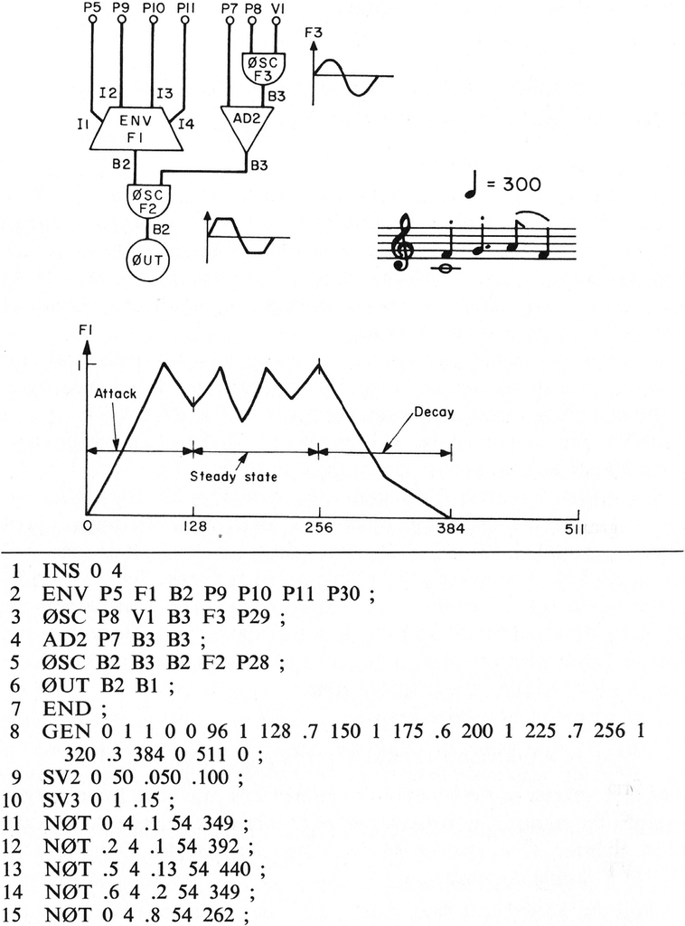

**图 5.5** Music V 合成音色。第 1-7 行定义了乐器，其中包含一个包络发生器。包络 F1 在第 8 行的 GEN 语句中定义。一个低频正弦波振荡器调制另一个振荡器上的颤音（Mathews 1969）。

**Figure 5.5** Music V synthesis patch. Lines 1–7 define the instrument, which features an envelope generator. The envelope F1 is defined in the GEN statement in line 8. A low-frequency sine wave oscillator modulates vibrato on another oscillator (Mathews 1969).

以 Music IV 或 Music V 为蓝本，其他人开发了诸如 Music 4BF、Music 360、Music 7、Music 11、Csound、MUS10、Cmusic、Common Lisp Music、SuperCollider、ChucK、Synthesis ToolKit、Nyquist 和 Max 等合成程序。这些程序通常被统称为“ *Music N 语言”*（参见第 48 章）。

Taking Music IV or Music V as a model, others have developed synthesis programs such as Music 4BF, Music 360, Music 7, Music 11, Csound, MUS10, Cmusic, Common Lisp Music, SuperCollider, ChucK, Synthesis ToolKit, Nyquist, and Max. As a general category these programs are often referred to under the rubric *Music N languages* (see chapter 48).

已故的马克斯·V·马修斯（Max V. Mathews，1926-2011）是模块化单元发生器合成范式的发明者，该范式用于广义波形合成，堪称计算机生成声音之父。基于单元发生器模块化图的合成至今仍是灵活且实验性合成的标准。Music *N*语言为任何愿意学习编程的人提供了这种能力。

As the inventor of the modular unit generator synthesis paradigm for generalized waveform synthesis, the late Max V. Mathews (1926–2011) can rightly be called the father of computer-generated sound. Synthesis based on modular graphs of unit generators remains to this day the standard for flexible and experimental synthesis. Music *N* languages deliver this capability to anyone willing to learn to program.

# *6 波表查找合成*

# *6 Wavetable Lookup Synthesis*

**波表查找合成**

**Wavetable Lookup Synthesis**

**改变波形频率**

**Changing Waveform Frequency**

**数字振荡器算法**

**Algorithm for a Digital Oscillator**

**波表查找噪声和插值振荡器**

**Wavetable Lookup Noise and Interpolating Oscillators**

**波表查找的替代方案**

**Alternatives to Wavetable Lookup**

数字合成器会生成一系列数字，代表任意音频波形的样本。我们可以通过将样本发送到数模转换器 (DAC) 来听到这些合成声音，DAC 会将这些数字转换为连续变化的电压，然后将其放大并发送到扬声器。

Digital synthesis generates a stream of numbers representing the samples of an arbitrary audio waveform. We can hear these synthetic sounds by sending the samples through a digital-to-analog converter (DAC), which converts the numbers to a continuously varying voltage that can be amplified and sent to a loudspeaker.

## **波表查找合成**

## **Wavetable Lookup Synthesis**

一种灵活的波形合成方法是扫描内存中预存的波表。这个过程称为*波表查找合成。波表查找合成是**数字振荡器（*一种基本的声音发生器）的核心操作。

A flexible method of waveform synthesis is to scan a prestored wavetable in memory. This process is called *wavetable lookup synthesis.* Wavetable lookup synthesis is the core operation of a *digital oscillator—*a fundamental sound generator.

现在让我们来看一下查表的过程。假设第一个样本的值由波表中的第一个数字给出（如图 6.1中索引位置 0 所示）。对于这个简单的合成器要生成的每个新样本，都从波表中取出下一个样本。在波表的末尾，只需回到开头并重新开始读取样本即可。这个过程也称为*固定波形合成*，因为波形在声音事件的过程中不会发生变化。

Let us now walk through the process of table lookup. Suppose that the value of the first sample is given by the first number in the wavetable (shown in figure 6.1 at index location 0). For each new sample to be produced by this simple synthesizer, take the next sample from the wavetable. At the end of the wavetable, simply go back to the beginning and start reading out the samples again. The process is also called *fixed-waveform synthesis* because the waveform does not change over the course of a sound event.

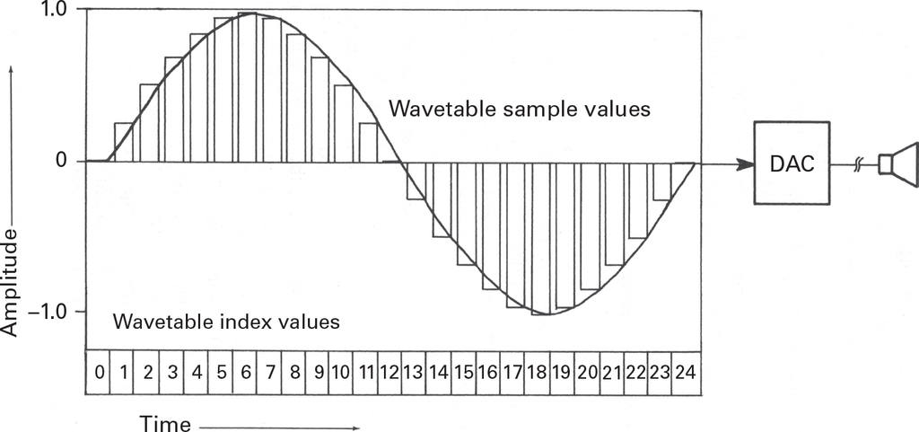

**图 6.1** 波表查找合成的图形描述。下半部分中的列表 0–24 包含编号位置或*表格索引值。*每个索引点的音频样本值存储在内存中。样本在上半部分以矩形框出正弦波的轮廓来表示。例如，Wavetable[0] = 0，Wavetable[6] = 1。为了合成正弦波，计算机查找存储在连续索引位置的样本值，并将它们发送到 DAC，如此反复循环遍历整个表格。

**Figure 6.1** Graphical depiction of wavetable lookup synthesis. The list 0–24 in the lower portion contains numbered locations or *table index values.* An audio sample value is stored in memory for each index point. The samples are depicted as the rectangles outlining a sine wave in the top portion. For example, Wavetable[0] = 0, and Wavetable[6] = 1. To synthesize the sine wave, the computer looks up the sample values stored in successive index locations and sends them to a DAC, looping through the table repetitively.

例如，假设表包含*N* = 1,000 个条目，每个条目都是一个 16 位数字。这些条目的索引从 0 到 999。我们称之为表中当前位置的*phase_index*值，参考波形的相位。为了读取该表，振荡器从表中的第一个条目（*phase_index* = 0）开始，以*增量*移动到表的末尾（*phase_index* = 999）。此时，相位索引绕过终点，回到波表的开头，并重新开始（图 6.2）。

For example, let us assume that the table contains *N* = 1,000 entries, each of which is a 16-bit number. The entries are indexed from 0 to 999. We call the current location in the table the *phase_index* value, with reference to the phase of the waveform. To read through the table the oscillator starts at the first entry in the table (*phase_index* = 0) and moves by an *increment* to the end of the table (*phase_index* = 999). At this point the phase index wraps around the ending point to the beginning of the wavetable and starts again (figure 6.2).

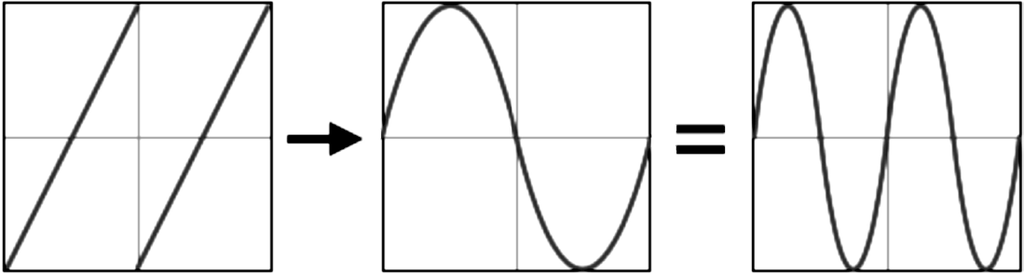

**图 6.2** 相位增量或*相量*（斜坡函数）从 0 变为*N*两次，从而产生两个正弦波周期。

**Figure 6.2** The phase increment or *phasor* (a ramp function) goes from 0 to *N* two times, creating two cycles of the sine wave.

## **改变波形频率**

## **Changing Waveform Frequency**

查表合成产生的声音频率是多少？这取决于波表的长度和采样频率。逻辑上，显而易见的是，如果在一秒钟内读取整个波表（无论其长度如何），结果就是 1 Hz 的波；每秒读取 100 次，就会产生 100 Hz 的音调，依此类推。

What is the frequency of the sound produced by table-lookup synthesis? It depends on the length of the wavetable and the sampling frequency. Logically, it should be obvious that if one reads through the entire wavetable (no matter its length) in one second, the result is a wave at 1 Hz; reading through it 100 times a second makes a tone at 100 Hz, and so on.

现在让我们更具体地讨论波表长度和采样频率。如果采样频率为每秒 50,000 次采样，表中有 1,000 个数字，则结果为 50,000 / 1,000：50 Hz 的低音。同样，如果采样频率为 100,000 Hz，表中有 1,000 个条目，则输出频率为 100 Hz，因为 100,000 / 1,000 = 100。

Let us now be more specific about wavetable length and sampling frequency. If the sampling frequency is 50,000 samples per second and there are 1,000 numbers in the table, the result is 50,000 / 1,000: a low tone at 50 Hz. Likewise, if the sampling frequency is 100,000 Hz and the table contains 1,000 entries, then the output frequency is 100 Hz, because 100,000 / 1,000 = 100.

如何改变输出信号的频率？正如我们刚才所见，一个简单的方法是改变采样频率。但这种策略存在问题，尤其是在处理或混合不同采样率的信号时。更好的解决方案是通过跳过样本（提高音高）或重复样本（降低音高）以不同的速率扫描波表。这些过程实际上是调整波表的大小以产生不同的频率。

How is it possible to change the frequency of the output signal? As we have just seen, one simple way is to change the sampling frequency. But this strategy has problems, particularly when one wants to process or mix signals with different sampling rates. A better solution is to scan the wavetable at different rates by skipping samples (to shift pitch up) or repeating samples (to shift pitch down). These processes, in effect, resize the wavetable in order to generate different frequencies.

例如，如果我们只取偶数个样本，那么遍历表格的速度会加倍。这会将输出信号的音高提高一个八度。如果我们跳过两个样本，音高会进一步提高（准确地说，提高一个八度加五度）。为了降低音高，我们需要重复采样。例如，为了将音高降低一个八度，我们需要播放每个样本两次。

For example, if we take only the even-numbered samples, then we go through the table twice as fast. This raises the pitch of the output signal by an octave. If we skip two samples, then the pitch is raised further (by an octave and a fifth, to be exact). To shift the pitch down we repeat samples. For example, to shift the pitch down an octave, we play each sample twice.

在查表算法中，*相位增量*决定了要跳过或重复的样本数。该增量会被添加到当前相位位置，以便找到下一个读取样本值的位置。在最简单的例子中，如果我们读取表中的每一个样本，则增量为 1。如果我们只读取表中奇数或偶数的样本，则增量为 2。

In the table-lookup algorithm, the *phase increment* determines the number of samples to be skipped or repeated. The increment is added to the current phase location in order to find the next location for reading the value of the sample. In the simplest example, where we read every sample from the table, the increment is 1. If we read only the odd- or even-numbered samples in the table, then the increment is 2.

## **数字振荡器算法**

## **Algorithm for a Digital Oscillator**

我们可以说，振荡器对波表*进行重采样*是为了产生不同的频率。也就是说，它会跳过或重复表中的值，增量是波表中当前相位位置的增量。因此，最基本的振荡器算法可以解释为以下两步程序：

We could say that the oscillator *resamples* the wavetable in order to generate different frequencies. That is, it skips or repeats values in the table by an increment added to the current phase location in the wavetable. Thus the most basic oscillator algorithm can be explained as the following two-step program:

1.*相位索引* = mod L *(前一个相位* + *增量*)

1. *phase_index* = modL *(previous_phase* + *increment*)

2.*输出* = *振幅* × *波表*[*相位索引*]

2. *output* = *amplitude* × *wavetable*[*phase_index*]

算法的第一步包含一个加法和一个模运算（记为 mod L）。模运算将和除以表长度*L*，只保留余数，余数始终小于或等于*L*。第二步包含一个查表和一个乘法。这部分计算量相对较小，但它假设波表已经填充了波形值。

Step 1 of the algorithm contains an addition and a modulo operation (denoted modL). The modulo operation divides the sum by the table length *L* and keeps only the remainder, which is always less than or equal to *L*. Step 2 contains a table lookup and a multiplication. This is relatively little computation, but it assumes that the wavetables are already filled with waveform values.

如果表的长度和采样频率是固定的（通常情况下），那么振荡器发出的声音的频率取决于增量的值。给定频率和增量之间的关系由以下公式给出，该公式是查表合成中最重要的公式：

If the table length and the sampling frequency are fixed, as is usually the case, then the frequency of the sound emitted by the oscillator depends on the value of the increment. The relationship between a given frequency and an increment is given by the following equation, which is the most important equation in table lookup synthesis:

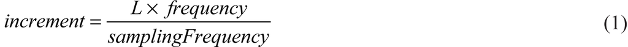

例如，如果表长度*L*为 1,000，采样频率为 40,000，振荡器的指定*频率为 2,000 Hz，则**增量*为 50。

For example, if tablelength *L* is 1,000, the sampling frequency is 40,000, and the specified *frequency* of the oscillator is 2,000 Hz, then the *increment* is 50.

这意味着频率的下列方程：

This implies the following equation for frequency:

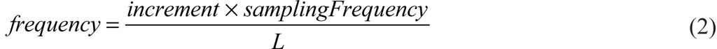

关于数字振荡器的理论就讲到这里。现在我们来谈谈计算的现实。

So much for the theory of digital oscillators. Now we confront the computational realities.

## **波表查找噪声和插值振荡器**

## **Wavetable Lookup Noise and Interpolating Oscillators**

上例中的所有变量都是 1,000 的倍数，因此相位索引增量的值最终会得到一个整数值。然而，对于公式 1 中表长度、频率和采样频率的大多数值，最终的增量值并非整数，而是一个小数点后带有小数部分的实数。然而，我们在波表中查找值的方式是通过其索引来定位，而索引是一个整数。因此，我们需要以某种方式从实值增量中导出一个整数值。

All the variables in the previous example were multiples of 1,000, which led to a neat integer result for the value of the phase index increment. However, for most values of the table length, frequency, and sampling frequency in equation 1, the resulting increment is not an integer but rather a real number with a fractional part after the decimal point. However, the way we look up a value in the wavetable is to locate it by its index, which is an integer. Thus we need to somehow derive an integer value from the real-valued increment.

可以将实数值*截断*为表索引的整数值。这意味着删除小数点右边的数字部分，例如，6.99 被截断后变为 6。

The real value can be *truncated* to yield an integer value for the table index. This means to delete the part of the number to the right of the decimal point, so, for example, 6.99 becomes 6 when it is truncated.

假设我们使用 1.125 的增量。表 6.1比较了计算出的增量和截断后的增量。截断造成的不精确意味着我们得到的波形值接近实际需要的波形值，但并不完全相同。结果会引入少量的波形失真，称为*查表噪声*(Moore 1977; Snell 1977b)。有多种方法可以减少这种噪声。一种方法是使用更大的波表，因为细粒度的表可以减少查找误差。另一种方法是方法是*将增*量值向上或向下舍入到最接近的整数，而不是简单地截断它；在本例中，增量 6.99 变成了 7，比 6 更精确。但最佳性能是通过*插值振荡器实现的。*从计算角度来看，这种方法成本更高，但它能产生非常干净的信号。

Suppose that we use an increment of 1.125. Table 6.1 compares the calculated versus the truncated increments. The imprecision caused by the truncation means that we obtain a waveform value near, but not precisely the same as, the one that we actually need. As a result, small amounts of waveform distortion are introduced, called *table lookup noise* (Moore 1977; Snell 1977b). Various remedies can reduce this noise. A larger wavetable is one prescription, because a fine-grain table reduces lookup error. Another way is to *round* the value of increment up or down to the nearest integer instead of simply truncating it; in this case, an increment of 6.99 becomes 7, which is more accurate than 6. But the best performance is achieved by an *interpolating oscillator.* This is more costly from a computational standpoint, but it generates very clean signals.

| **表 6.1** 阶段索引，表格查找表 **Table 6.1** Phase index, table lookup list |  |  |
| --- | --- | --- |
| 已计算 Calculated |  | 截断 Truncated |
| 1.000 1.000 |  | 1 1 |
| 2.125 2.125 |  | 2 2 |
| 3.250 3.250 |  | 3 3 |
| 4.375 4.375 |  | 4 4 |
| 5.500 5.500 |  | 5 5 |
| 6.625 6.625 |  | 6 6 |
| 7.750 7.750 |  | 7 7 |
| 8.875 8.875 |  | 8 8 |
| 10.000 10.000 |  | 10 10 |
| 11.125 11.125 |  | 11 11 |
| 12.250 12.250 |  | 12 12 |
| 13.375 13.375 |  | 十三 13 |
| 14.500 14.500 |  | 14 14 |
| 15.625 15.625 |  | 15 15 |
| 16.750 16.750 |  | 16 16 |
| 17.875 17.875 |  | 17 17 |
| 19.000 19.000 |  | 19 19 |

插值振荡器会计算，如果能够以增量指定的精确相位引用波表，波表的值将会是多少。换句话说，它会在波表中的各个条目之间进行插值，以找到与指定相位索引增量完全对应的条目（图 6.3）。

An interpolating oscillator calculates what the value of the wavetable would have been, if it were possible to reference the wavetable at the exact phase specified by the increment. In other words, it interpolates between the entries in the wavetable to find the one that exactly corresponds to the specified phase index increment (figure 6.3).

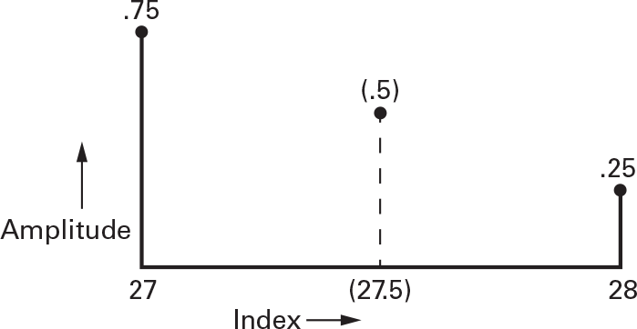

**图 6.3** 插值振荡器的动作。该图显示了波表中两个*x*点，分别位于位置 27 和 28。振荡器相位增量指示该值应为 27.5。插值振荡器使用线性插值算法生成介于 27 和 28 之间的*y值。*

**Figure 6.3** Action of an interpolating oscillator. The graph shows two *x* points in a wavetable, at positions 27 and 28. The oscillator phase increment indicates that the value should be 27.5. The interpolating oscillator generates a *y* value between 27 and 28 using a linear interpolation algorithm.

使用插值振荡器，较小的波表可以产生与较大的非插值振荡器相同的音频质量。试想一下，对于一个插值振荡器使用的1024个条目的波表，正弦波的信噪比达到了极好的109 dB（最坏情况），而使用相同大小波表的非插值振荡器的信噪比仅为糟糕的48 dB（Moore 1977）。这些数据适用于线性插值的情况；使用更复杂的插值方案甚至可以获得更好的结果（Chamberlin 1985；Crochiere 和 Rabiner 1983；Moore 1977；Snell 1977a；Dannenberg 1998）。

With interpolating oscillators, smaller wavetables can yield the same audio quality as a larger noninterpolating oscillator. Consider that for a 1024-entry wavetable used by an interpolating oscillator, the signal-to-noise ratio for a sine wave is an excellent 109 dB (worst case), as compared with the abysmal 48 dB for a noninterpolating oscillator using the same size wavetable (Moore 1977). These figures pertain to the case of linear interpolation; even better results are possible with more elaborate interpolation schemes (Chamberlin 1985; Crochiere and Rabiner 1983; Moore 1977; Snell 1977a; Dannenberg 1998).

## **波表查找的替代方案**

## **Alternatives to Wavetable Lookup**

在某些情况下，数值运算比内存表查找快得多。内存通常比微处理器指令慢。现代微处理器拥有用于正弦和余弦生成、指数、平方根和点积的原生硬件指令。因此，正如 James McCartney (1997) 指出的那样，正弦波、指数正弦波、共振峰振荡器和混沌振荡器等波形可以通过直接求其方程式来更高效地生成。SmithCook (1992) 描述了一种基于数字波导的高效正弦振荡器（另见 Smith 2010）。Laroche (1998) 展示了如何使用谐振滤波器合成时变正弦波，这是一种有效的加法合成策略。

In certain cases, numerical operations are much faster than memory table lookups. Memories tend to be slower than microprocessor instructions. Modern microprocessors have native hardware instructions for sine and cosine generation, exponentials, square roots, and dot products. Thus, as pointed out by James McCartney (1997), waveforms like sine waves, exponentiated sine waves, formant oscillators, and chaotic oscillators can be generated much more efficiently by direct evaluation of their equation. Smith and Cook (1992) described a highly efficient sinusoidal oscillator based on digital waveguides (see also Smith 2010). Laroche (1998) showed how using resonant filters to synthesize time-varying sinusoids could be an efficient strategy for additive synthesis.

我们对固定波形查表合成的介绍到此结束。下一章将展示如何利用包络随时间变化来改变合成的各个方面。

This concludes our introduction to fixed-waveform table-lookup synthesis. The next chapter shows how aspects of synthesis can be varied over time with envelopes.

# *7 时变波形合成*

# *7 Time-Varying Waveform Synthesis*

**信封、单元生成器和补丁**

**Envelopes, Unit Generators, and Patches**

**合成乐器的图形符号**

**Graphic Notation for Synthesis Instruments**

**在补丁中使用信封**

**Using Envelopes in Patches**

上一章展示了如何生成固定频率的正弦波。由于正弦波的最大值不随时间变化，因此信号具有恒定的响度。这对于音乐创作来说并不是很有用，因为它只能控制音高和时长，而无法控制其他声音参数。即使振荡器从其他波表读取数据，它们也会无限重复。获得更有趣声音的关键是*时变*波形，这可以通过在声音事件的持续时间内改变一个或多个合成参数来实现。

The previous chapter showed how to generate a sine wave at a fixed frequency. Because the maximum value of the sine wave does not change in time, the signal has a constant loudness. This is not terribly useful for musical purposes, because it allows control over only pitch and duration and no control over other sound parameters. Even if the oscillator reads from other wavetables, they repeat ad infinitum. The key to more interesting sounds is *time-varying* waveforms, achieved by changing one or more synthesis parameters over the duration of a sound event.

## **信封、单元生成器和补丁**

## **Envelopes, Unit Generators, and Patches**

要创建时变波形，我们需要一个能够由*包络*（时间函数）控制的合成*器。例如，如果声音的振幅随其持续时间变化，则振幅遵循的曲线称为**振幅包络*。设计合成器的一种通用方法是将其想象成一个模块化系统，包含多个专门的信号处理单元，它们共同产生时变声音。

To create a time-varying waveform, we need a synthesis *instrument* that can be controlled by *envelopes*—functions of time. For example, if the amplitude of the sound changes over its duration, the curve that the amplitude follows is called the *amplitude envelope*. A general way of designing a synthesis instrument is to imagine it as a modular system, containing a number of specialized signal-processing units that together create a time-varying sound.

正如第五章所指出的，单元发生器（UG）是数字合成中的一个基本概念。UG 可以是信号发生器，也可以是信号调制器。信号发生器（例如振荡器）合成音乐波形和包络等信号。信号调制器（例如滤波器）将信号作为输入，并以某种方式对该输入信号进行变换。

As chapter 5 pointed out, the unit generator (UG) is a fundamental concept in digital synthesis. A UG is either a signal generator or a signal modifier. A signal generator (such as an oscillator) synthesizes signals such as musical waveforms and envelopes. A signal modifier, such as a filter, takes a signal as its input and transforms that input signal in some way.

要构建一个声音合成器，需要将UG连接成一个*patch（补丁）。* “patch”一词源于模块化合成器，其中的声音模块通过*跳线连接。*当然，当连接通过软件完成时，无需连接任何物理线路或电缆。当一个UG在其输出端产生一个数字时，该数字可以作为另一个UG的输入。

To construct an instrument for sound synthesis, one interconnects UGs into a *patch.* The term patch derives from modular synthesizers in which sound modules are connected via *patch cords.* Of course, when the connections are done in software, no physical wires or cables are connected. When a UG produces a number at its output, that number can become the input to another UG.

## **合成乐器的图形符号**

## **Graphic Notation for Synthesis Instruments**

现在我们来介绍一下数字声音合成出版物中常用的、用来表示音色的图形符号。这种符号是为了解释最早的模块化数字声音合成语言（例如 Music 4BF（Howe 1975）和 Music V（Mathews 1969））的操作而发明的，至今仍然有用。

Now we introduce the graphic notation often used in publications on digital sound synthesis to illustrate patches. This notation was invented to explain the operation of the first modular languages for digital sound synthesis, such as Music 4BF (Howe 1975) and Music V (Mathews 1969) and is still useful.

每个单元发生器的符号都有其独特的形状。图 7.1展示了一个称为*osc 的**表查找振荡器*的图形符号，它是一个基本的信号发生器。它接受三个输入：幅度、频率和存储在波表*f* 1中的波形。它产生的输出信号是*f* 1 以规定的频率和幅度重复的。

The symbol for each unit generator has a unique shape. Figure 7.1 shows the graphic notation for a *table-lookup oscillator* called *osc*, a basic signal generator. It accepts three inputs: amplitude, frequency, and a waveform stored in wavetable *f* 1. It produces an output signal that is *f* 1 repeated at the stipulated frequency and amplitude.

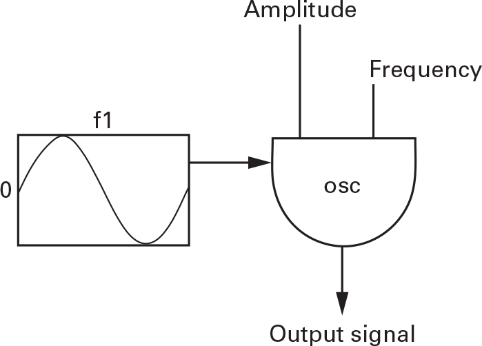

**图 7.1** 具有声音波形输入*f* 1 且幅度和频率参数固定的振荡器。

**Figure 7.1** Oscillator with sound waveform input *f* 1 and fixed parameters for amplitude and frequency.

## **在补丁中使用信封**

## **Using Envelopes in Patches**

如果我们为振荡器的振幅输入提供一个常数（例如 1.0），则输出波形的整体振幅在每个事件的持续时间内都是恒定的。相比之下，大多数有趣的声音都有一个随时间变化的振幅包络。通常，一个音符的振幅从 0 开始，逐渐上升到某个最大值（通常*标准化*为不大于 1.0），然后或多或少缓慢地下降到 0。（标准化的波已被缩放到标准范围内，例如振幅包络为 0 到 1，其他波为-1到+1。）包络的起始部分称为*起音*部分，包络的结束部分称为*释放部分。*

If we supply a constant number (for example, 1.0) to the amplitude input of an oscillator, then the overall amplitude of the output waveform is constant over the duration of each event. By contrast, most interesting sounds have an amplitude envelope that varies as a function of time. Typically, a note starts with an amplitude of 0, works its way up to some maximum value (usually *normalized* to be no greater than 1.0), and dies down again more or less slowly to 0. (A normalized wave has been scaled to fall within standard boundaries such as 0 to 1 for amplitude envelopes, or −1 to +1 for other waves.) The beginning part of the envelope is called the *attack* portion, and the end of the envelope is called the *release.*

许多合成器在以下四个阶段定义幅度包络：

Many synthesizers define amplitude envelopes in the following four stages:

- 攻击（从零开始增加到峰值）
- Attack (initial increase from zero to peak)
- 衰减（过渡到持续水平）
- Decay (transition down to a sustained level)
- 维持（恒定水平）
- Sustain (constant level)
- 释放（液位恢复到零所需的时间）。
- Release (time taken for level to return to zero).

这种四级包络的常用缩写是 ADSR（图 7.2）。ADSR 概念对于口头描述包络的整体形状很有用；例如，“使音头更锐利”。然而，对于指定音乐包络来说，四个阶段是有限制的。更灵活的包络编辑器允许音乐家描绘任意曲线。

The usual acronym for such a four-stage envelope is ADSR (figure 7.2). The ADSR concept is useful for describing verbally the overall shape of an envelope; for example, “Make the attack sharper.” However, for specifying a musical envelope, four stages is limiting. More flexible envelope editors allow musicians to trace arbitrary curves.

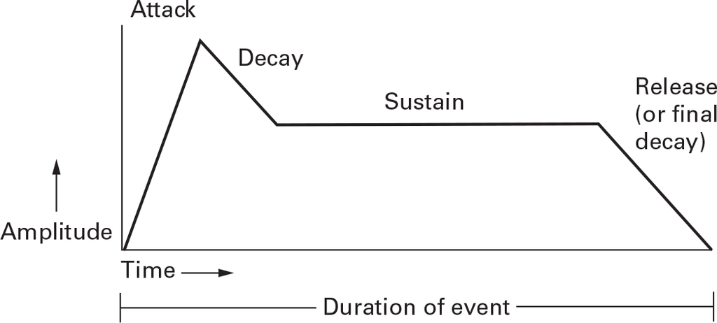

**图 7.2** 启动、衰减、维持、释放 (ADSR) 幅度包络。

**Figure 7.2** Attack, decay, sustain, release (ADSR) amplitude envelope.

图 7.1中的仪器可以很容易地通过将包络连接到振荡器的振幅输入端来产生随时间变化的振幅。现在，我们更接近于用音乐的方式控制振荡器了。如果我们设置包络的时长和曲线，那么包络就会控制每个音符的振幅。

The instrument of figure 7.1 can be easily adapted to generate a time-varying amplitude by hooking up an envelope to the amplitude input of the oscillator. We are now closer to controlling the oscillator in musical terms. If we set the duration and the curve of the envelope, then the envelope controls the amplitude of each note.

为乐曲中的每个事件设计一个包络非常繁琐。我们寻求的是一种简单的程序来生成一个能够根据不同事件的持续时间进行缩放的包络。图 7.3展示了一个*包络生成器 env_gen*。这个 UG env_gen 接收一个持续时间、一个峰值幅度和一个波表。它会读取指定持续时间内的波表*f* 1 ，并根据峰值幅度进行缩放。它可以适应任何持续时间的音调。在本例中，声音波形为*f* 2 。

Designing an envelope for every event in a composition is tedious. What we seek is a simple procedure for generating an envelope that can scale itself to the duration of diverse events. Figure 7.3 shows an *envelope generator, env_gen*. This UG env_gen takes in a duration, a peak amplitude, and a wavetable. It reads through the wavetable *f* 1 over the specified duration, scaling it by the peak amplitude. It is adaptable to tones of any duration. The sound waveform is *f* 2 in this case.

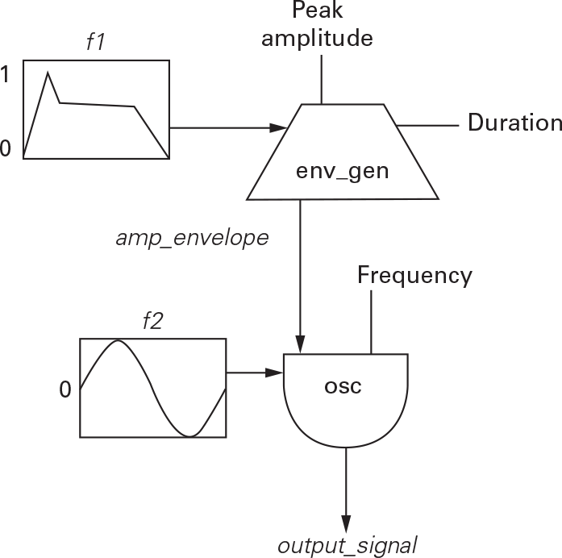

**图 7.3** 振幅包络为*f* 1 、声音波形为*f* 2 的振荡器。

**Figure 7.3** Oscillator with amplitude envelope *f* 1 and sound waveform *f* 2.

读者可能已经猜到了，我们也可以将包络发生器连接到 osc 的频率输入端，以获得诸如颤音或滑音之类的音高变化。事实上，我们可以通过多种方式连接包络、振荡器和其他单元发生器，以产生不同的声音。这就是声音合成的模块化方法。

As the reader might guess, we could also attach an envelope generator to the frequency input of osc to obtain a pitch change such as vibrato or glissando. Indeed, we can interconnect envelopes, oscillators, and other unit generators in a wide variety of ways in order to make different sounds. This is the modular approach to sound synthesis.

人类天生对波动敏感，因此，时变包络是产生有趣声音的关键也就不足为奇了。包络是姿态的轮廓。作为人体运动的类比，它们为原本毫无生气的电子信号注入了活力。

Human beings are naturally sensitive to undulation, so it is not surprising that time-varying envelopes are the key to interesting sounds. Envelopes are profiles of gestures. As analogies of human body movements, they infuse life into otherwise lifeless electronic signals.

# *8 软件综合*

# *8 Software Synthesis*

**什么是软件综合？**

**What Is Software Synthesis?**

**早期软件综合**

**Early Software Synthesis**

**软件合成器的类型**

**Types of Software Synthesizers**

**已关闭的应用程序**

**Closed Apps**

**可修补的应用程序**

**Patchable Apps**

**虚拟模块化合成器**

**Virtual Modular Synthesizers**

**图形乐器补丁编辑器**

**Graphical Instrument Patch Editors**

**文本合成语言**

**Textual Synthesis Languages**

**使用通用编程语言制作的自定义应用程序**

**Custom Apps Made Using General-Purpose Programming Languages**

**实时和非实时合成**

**Real-Time and Non-Real-Time Synthesis**

**非实时合成**

**Non-Real-Time Synthesis**

**声音文件**

**Sound Files**

**实时数字合成**

**Real-Time Digital Synthesis**

**音频编程**

**Audio Programming**

本章首先比较硬件合成和软件合成。我们简要回顾软件合成的历史，回顾各种类型的软件合成器，探讨实时和非实时合成，并介绍音频编程的资源。

This chapter begins by comparing hardware versus software synthesis. We briefly review the history of software synthesis, review various types of software synthesizers, look at real-time and non-real-time synthesis, and introduce resources for audio programming.

## **什么是软件综合？**

## **What Is Software Synthesis?**

在数字合成的早期，计算机速度太慢，无法实现*实时*操作。我们所说的*实时*是什么意思？在这种情况下，实时意味着我们可以在一个采样周期内完成样本的所有计算。如果一个系统需要十秒钟来计算一秒钟的声音，那么它必须以*非实时系统的方式运行。*这意味着必须将声音输出写入文件，以便稍后试听。早期的计算机音乐系统无法在有声音的情况下进行交互式播放——从音乐的角度来看，这是一个巨大的缺陷。

In the early days of digital synthesis, computers were too slow for *real-time* operation. What do we mean by *real time*? In this context, real time means that we can complete all calculations for a sample within the duration of one sample period. If a system takes ten seconds to compute one second of sound, it must operate as a *non-real-time system.* This means that the sound output must be written to a file to be auditioned later. Early computer music systems could not be played interactively in the presence of sound—a huge liability from a musical standpoint.

因此，人们强烈希望设计专门的数字硬件来实时合成声音（Markowitz 1989；Alonso 1973；Alles and Di Giugno 1977；Snell 1977a、1977b；Samson 1980、1985；Asta 等人 1980；Wallraff 1979a；Loy 2013a、2013b）。早期的硬件合成器稀有且昂贵。一个突破性的产品是 Yamaha DX7（1983 年），这是一款基于专用*调频*(FM) 合成芯片（第 16 章）的量产键盘乐器。售价不到 2,000 美元，销量超过 200,000 台。20 世纪 80 年代的许多流行音乐都融入了 Yamaha FM 声音。

Thus there was a strong motivation to design specialized digital hardware to synthesize sound in real time (Markowitz 1989; Alonso 1973; Alles and Di Giugno 1977; Snell 1977a, 1977b; Samson 1980, 1985; Asta, et al. 1980; Wallraff 1979a; Loy 2013a, 2013b). Early hardware synthesizers were rare and expensive. A breakthrough product was the Yamaha DX7 (1983), a mass-produced keyboard instrument based on specialized chips for *frequency modulation* (FM) synthesis (chapter 16). Selling for less than $2,000, over 200,000 units were sold. Much pop music of the 1980s was infused with the Yamaha FM sound.

专用硬件效率高，但灵活性有限。例如，DX7 中的芯片专为 FM 而设计，无法实现其他合成方法。因此，最灵活的声音生成方法是在计算机上运行*软件合成*程序。在软件合成中，所有与样本流计算相关的计算都由计算机完成，无需额外的硬件。

Specialized hardware can be efficient but is limited in its flexibility. For example, the chips in the DX7 were designed for FM; they could not realize other synthesis methods. Thus, the most flexible approach to sound generation is a *software synthesis* program running on a computer. In software synthesis, all the calculations involved in computing a stream of samples are carried out by a computer without additional hardware.

## **早期软件综合**

## **Early Software Synthesis**

软件合成的一个早期例子是历史悠久的Music V语言（Mathews 1969），如图8.1所示。为了创造声音，人们需要用Music V语言编写程序，然后执行该程序。这个非实时的过程可能需要数小时（Roads 2001a）。

An early example of software synthesis was the venerable Music V language (Mathews 1969), shown in figure 8.1. To create sound, one would write a program in the Music V language and then execute the program. This non-real-time process could take hours (Roads 2001a).

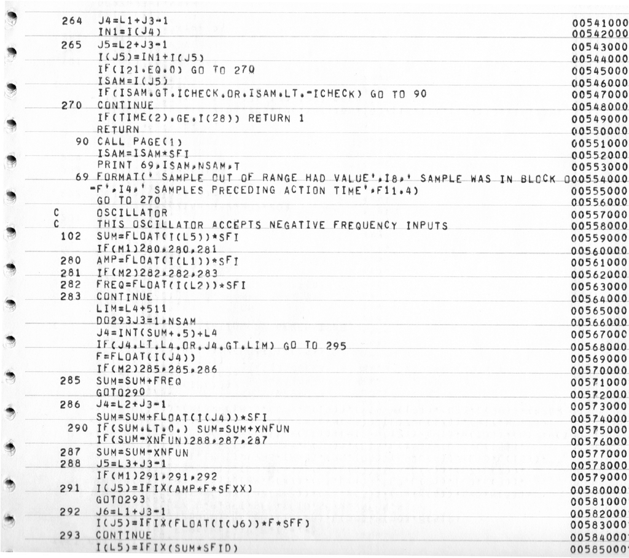

**图 8.1** 作者打印的 1974 年 Music V 源代码摘录。该代码是经典的 FORTRAN IV 语言，程序控制流由 GOTO 语句控制。前 16 行是 OUT 单元生成器的结尾。其余部分是 OSCIL 单元生成器的开头。适用于 GFortran 和 Linux 的更现代版本的 Music V 代码发表于 Boulanger 和 Lazzarini (2011)。GFortran 仍在维护中。

**Figure 8.1** Excerpt of the author’s printout of the source code of Music V from 1974. The code is classic FORTRAN IV, with program control flow by GOTO statements. The first 16 lines are the end of the OUT unit generator. The rest is the beginning of the OSCIL unit generator. The code for a more modern version of Music V for GFortran and Linux is printed in Boulanger and Lazzarini (2011). GFortran continues to be maintained.

图 8.2是一个简单的 Music V 程序示例。图 8.2(a)显示了待合成音符的常规乐谱。图 8.2(b)显示了这是一个用于演奏乐谱的简单乐器的音色包。它仅由一个振荡器和一个输出盒组成。振荡器有两个输入：输出的振幅由音符语句中的第五个元素（指定为 P5）设置。要演奏的波形由函数 F2 决定，如图8.2c所示。

Figure 8.2 is a simple example of a Music V program. Figure 8.2(a) shows a conventional score of the notes to be synthesized. Figure 8.2(b) shows the patch for a simple instrument that will play the score. It consists solely of an oscillator and an output box. The oscillator has two inputs: the amplitude of the output is set by the fifth element in the note statement, designated P5. The waveform to be played is determined by the function F2, which is sketched in figure 8.2c.

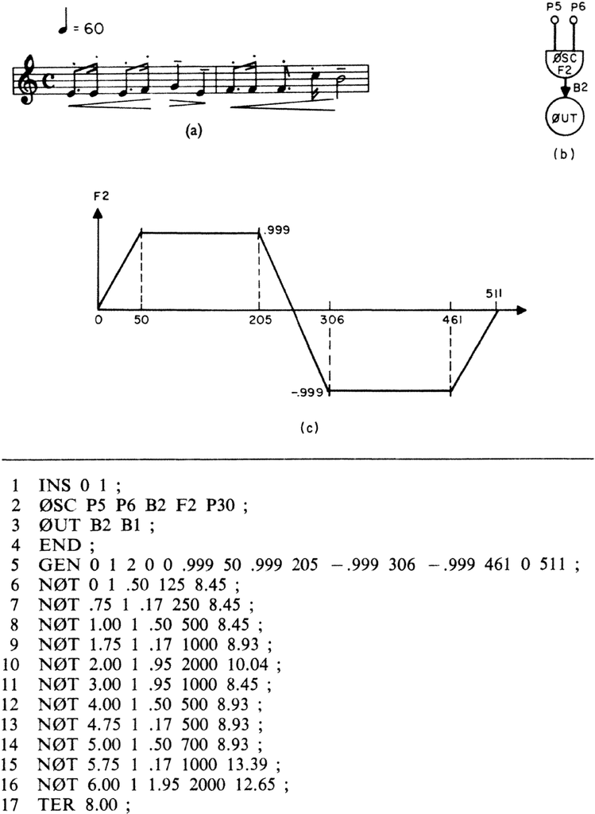

**图 8.2** Music V 中的简单管弦乐队和乐谱（Mathews 1969 年版）。为了简化解释，添加了行号 1-17。代码中的 1-4 行定义了 1 号乐器（一个振荡器和一个输出）。第 5 行生成函数 F2。第 6-16 行列出了定义乐谱的音符语句。每个音符语句都给出了起始时间、乐器编号、时值、振幅和音高（在本例中已编码）。第 17 行终止程序。

**Figure 8.2** A simple orchestra and score in Music V (after Mathews 1969). Line numbers 1–17 have been added to simplify the explanation. Lines 1–4 in the code define instrument number 1 (an oscillator and an output). Line 5 generates the function F2. Lines 6–16 list note statements defining the score. Each note statement gives starting time, instrument number, duration, amplitude, and pitch (encoded in this case). Line 17 terminates the program.

到了 20 世纪 70 年代中期，音乐合成语言已可在小型计算机上运行。大多数短期实验的合成作业等待时间缩短至几分钟，而合成涉及混响的整首乐曲等高强度任务则需要数小时。

By the mid-1970s, music synthesis languages could be run on minicomputers. Waiting times for synthesis jobs were reduced to minutes for most short-duration experiments and hours for intensive tasks like synthesizing entire pieces involving reverberation.

如今，市面上有众多实时软件合成器可供选择。例如，任何使用 Native Instruments REAKTOR 模块化系统的用户可以设计和发布合成器，仅此平台就有数千种合成器可用。

Today a multitude of real-time software synthesizers are available. To cite one example, any user of the Native Instruments REAKTOR modular system can design and publish a synthesizer, so that thousands of synthesizers are available for this platform alone.

## **软件合成器的类型**

## **Types of Software Synthesizers**

当代软件综合可分为六大类：

Contemporary software synthesis can be divided into six general categories:

- 关闭的应用程序
- Closed apps
- 可修补的应用程序
- Patchable apps
- 虚拟模块化合成器
- Virtual modular synthesizers
- 图形乐器补丁编辑器
- Graphical instrument patch editors
- 文本合成语言
- Textual synthesis languages
- 使用通用编程语言制作的定制应用程序
- Custom apps made using general-purpose programming languages

第 19 章介绍虚拟模块化合成器。第 47 章概述了图形乐器音色编辑器。第 48 章介绍文本合成语言。

Chapter 19 looks at virtual modular synthesizers. Chapter 47 surveys graphical instrument patch editors. Chapter 48 addresses textual synthesis languages.

### **已关闭的应用程序**

### **Closed Apps**

封闭式应用程序旨在出色地完成一项任务。它们经过优化，仅能实现一种合成技术或几种变体。它们的图形界面体现了这种专业化。它们无法自由地重新编程以实现任何合成技术。图 8.3展示了 Native Instruments FM8，它模拟了 Yamaha DX7 合成器。即使是像 FM8 这样的封闭式应用程序，在音色设置方面也提供了一定的灵活性。它的“专家”页面允许用户设计自己的 FM 音色。

Closed apps are designed to do one thing very well. They are optimized to realize a single synthesis technique or only a few variations. Their graphical interface reflects this specialization. They cannot be freely reprogrammed to realize any synthesis technique. Figure 8.3 shows the Native Instruments FM8, which emulates a Yamaha DX7 synthesizer. Even a closed app like FM8 provides some flexibility in patching. Its Expert page lets users design their own FM patches.

[figure not shown]

**图 8.3** Native Instruments FM8。该软件合成器针对频率调制合成进行了优化。

**Figure 8.3** Native Instruments FM8. This software synthesizer is optimized for frequency modulation synthesis.

许多商业软件合成器既可以*独立*运行（即无需运行其他应用程序），也可以作为*数字音频工作站*(DAW) 或声音编辑器的插件扩展*运行*。插件实现的优势在于，多个插件副本或*实例*可以同时运行，并且可以在播放时由 DAW 进行录制。

Many commercial software synthesizers can run either in *standalone* mode (i.e., with no other apps running), or as a *plug-in* extension to a *digital audio workstation* (DAW) or sound editor. The plug-in implementation has the advantage that multiple copies or *instances* of the plug-ins can run simultaneously, and they can be recorded by the DAW as they play.

### **可修补的应用程序**

### **Patchable Apps**

可修补应用程序提供了一组有限的模块，可以修补这些模块以实现不同的合成技术。

Patchable apps offer a limited set of modules with the possibility of patching the modules to realize different synthesis techniques.

一个可修补应用程序的例子是 Native Instruments Absynth，它采用*半模块化*设计，拥有 12 个模块插槽（图 8.4）。用户可以选择各种类型的振荡器、滤波器和调制器来填充这些空插槽。

An example of a patchable app is Native Instruments Absynth, which features a *semimodular* design with twelve module slots (figure 8.4). One can choose among various types of oscillators, filters, and modulators to fill in the open slots.

[figure not shown]

**图 8.4** Absynth 补丁窗口。

**Figure 8.4** Absynth patch window.

另一款是 Madrona Labs Aalto，这是一款自诩为西海岸风格的合成器，效仿已故的 Don Buchla。与 Buchla 系统类似，它将一个复杂的振荡器与一个低通门电路耦合在一起。它还配备了两个包络发生器、一个波导延迟器、一个滤波器和一个音序器。虽然它的模块集合是固定的，但它提供了二十多个用于模块互连的跳线点（图 8.5）。据开发者介绍，正是通过巧妙地利用这些互连点，才能创造出意想不到的声音（Jones 2020）。

Another is Madrona Labs Aalto, a self-styled West Coast synthesizer following the example of the late Don Buchla. Like a Buchla system, it couples a complex oscillator with a lowpass gate. It also features two envelope generators, a waveguide delay, a filter, and a sequencer. Although its collection of modules is fixed, it offers more than two dozen patch points for interconnecting the modules (figure 8.5). According to the developer, it is by playing with the interconnections that unexpected sounds emerge (Jones 2020).

[figure not shown]

**图 8.5** Madrona Labs Aalto，一款可修补的软件合成器。

**Figure 8.5** Madrona Labs Aalto, a patchable software synthesizer.

Unfiltered Audio 的多功能 LION 合成器（图 8.6）进一步提供了可扩展数量的虚拟调制源，可以通过修补来控制合成参数。

Unfiltered Audio’s versatile LION synthesizer (figure 8.6) goes further to offer an expandable number of virtual modulation sources that can be patched to control synthesis parameters.

[figure not shown]

**图 8.6** Unfiltered Audio LION，一个可修补的软件合成器。

**Figure 8.6** Unfiltered Audio LION, a patchable software synthesizer.

### **虚拟模块化合成器**

### **Virtual Modular Synthesizers**

第一波虚拟模块化软件合成器是对老式模拟合成器的模拟。Arturia 与 Robert Moog 合作，于 2003 年推出了 Modular V 合成器。此后，Arp、EMS 和 Buchla 等公司也陆续推出了对老式合成器的模拟。图 8.7展示了 Arturia 的 EMS Synthi V 软件合成器的屏幕。

The first wave of virtual modular software synthesizers were simulations of vintage analog synths. Arturia worked with Robert Moog to introduce the Modular V synthesizer in 2003. Since that time, emulations of vintage synths by Arp, EMS, and Buchla have appeared. Figure 8.7 shows the screen of Arturia’s EMS Synthi V software synthesizer.

[figure not shown]

**图 8.7** Arturia EMS Synthi V 软件合成器。

**Figure 8.7** Arturia EMS Synthi V software synthesizer.

新的虚拟模块化合成器包括 Native Instruments REAKTOR Blocks、VCV Rack、SoftTube Modular 和 Cherry Audio 的 Voltage Modular（参见第 19 章）。

New virtual modular synthesizers include Native Instruments REAKTOR Blocks, VCV Rack, SoftTube Modular, and Cherry Audio’s Voltage Modular (see chapter 19).

### **图形乐器补丁编辑器**

### **Graphical Instrument Patch Editors**

图形乐器编辑器（例如 Max、PureData (PD) 或 AudioMulch）允许用户通过在屏幕上连接图标来构建合成音色（图 8.8）。这些图标代表单元生成器。我们所说的可音色应用与图形乐器编辑器的区别在于，在编辑器中，用户可以将任意数量的模块添加到音色中。此外，在像 Max 这样的系统中，有数百个模块可供选择。编辑完成后，可以将结果编译成一个独立的应用程序。

A graphical instrument editor such as Max, PureData (PD), or AudioMulch lets one build synthesis patches by interconnecting icons on a screen (figure 8.8). The icons represent unit generators. The difference between what we have called a patchable app and a graphical instrument editor is that in the editor one can add any number of modules into a patch. Moreover, in a system like Max, there are hundreds of modules from which to choose. Once the editing is done, the result can be compiled to make a self-contained app.

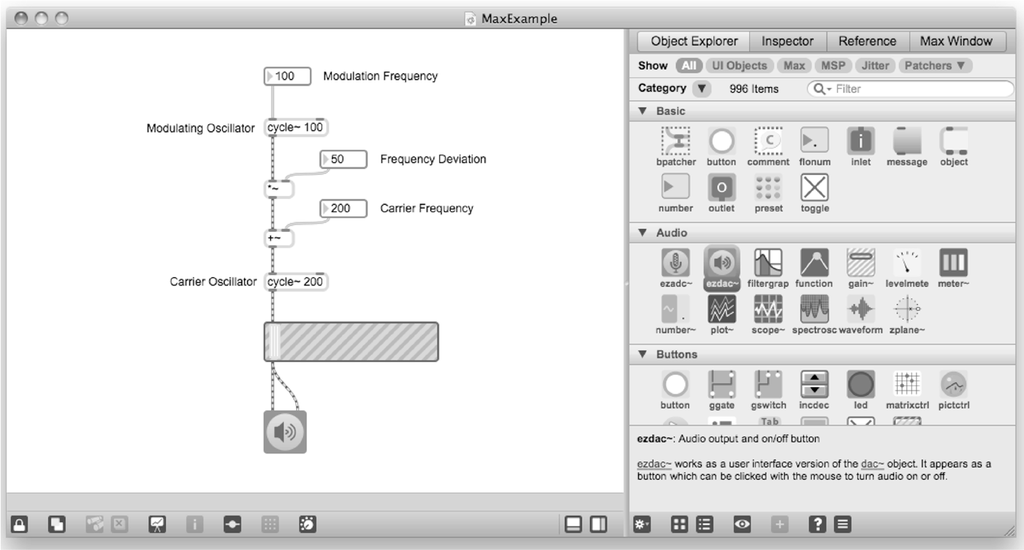

**图 8.8** 频率调制的最大补丁。

**Figure 8.8** Max patch for frequency modulation.

### **文本合成语言**

### **Textual Synthesis Languages**

使用专为合成而设计的语言，音乐家可以通过编写文本来指定声音，然后合成引擎会对其进行解释。这类语言的代表包括 Csound、Nyquist、ChucK、Faust 和 SuperCollider 等。图 8.9展示了一个用 SuperCollider 3 编写的简单 FM 合成器。

Using a language designed for synthesis, a musician can specify sounds by writing a text that is interpreted by a synthesis engine. This category is represented by languages such as Csound, Nyquist, ChucK, Faust, and SuperCollider. Figure 8.9 shows a simple FM synthesis instrument written in SuperCollider 3.

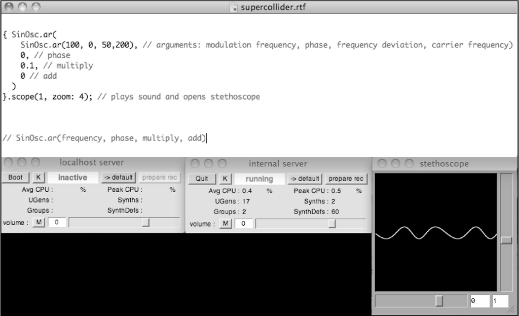

**图 8.9** 用于频率调制合成的 SuperCollider 代码。

**Figure 8.9** SuperCollider code for frequency modulation synthesis.

使用像 SuperCollider 这样的编程语言，可以编写功能齐全的新应用程序。例如，PulsarGenerator（Roads 2001a, 2001b）就是用 SuperCollider 编译的。我们的颗粒化应用程序 EmissionControl 最初是用 SuperCollider 和 C 语言（Thall 2005）组合编写的。

Using a programming language like SuperCollider, one can compile new fully-functioning apps. For example, PulsarGenerator (Roads 2001a, 2001b) was compiled in SuperCollider. Our granulation app EmissionControl was originally coded in a combination of SuperCollider and C (Thall 2005).

### **使用通用编程语言制作的自定义应用程序**

### **Custom Apps Made Using General-Purpose Programming Languages**

为了实现极致的定制化和效率，可以使用 C ++等通用语言进行编程。市场上的大多数软件合成器市场上的音频应用程序均采用 C ++编写。*代码库*对于音频应用程序编程至关重要，因为它们为这些应用程序中常见的许多基本任务提供了解决方案。代码库有助于图形用户界面 (GUI) 设计（例如 ImGui 和 JUCE）、音频输入和输出（例如 PortAudio 和 RtAudio）、MIDI 控制（例如 RtMidi）、信号处理算法（例如 Pedal 和 STK）以及使用机器学习的音乐信息检索（例如 FluCoMa 项目）。我们的 EmissionControl2 颗粒合成应用程序采用 C ++编写，使用了 Allolib 代码库，该库旨在支持沉浸式 3D 音频和视觉效果。

For the ultimate in customization and efficiency, one can program in a general-purpose language like C++. Most of the software synthesizers on the market are coded in C++. *Code libraries* are vital to programming audio applications because they provide solutions to many basic tasks that are common to these applications. Code libraries facilitate graphical user interface (GUI) design (e.g., ImGui and JUCE), audio input and output (e.g., PortAudio and RtAudio), MIDI control (e.g., RtMidi), signal processing algorithms (e.g., Pedal and STK), and music information retrieval using machine learning (e.g., FluCoMa Project). Our EmissionControl2 granular synthesis app was coded in C++ using the Allolib code library, which was designed to support immersive 3D audio and visuals.

## **实时和非实时合成**

## **Real-Time and Non-Real-Time Synthesis**

几十年来，摩尔定律（1965 年）预测晶体管密度每年将翻一番，并对时钟速度产生后续影响。到 2012 年，随着微处理器的时钟速度停滞在 4 GHz 以下，这条定律开始失去意义。芯片公司对此做出了回应，制造了*多核*处理器，使多个进程可以并行运行，理论上可以加快运行速度。然而，许多实时交互式音频算法并没有从*多线程*（并行）处理中获益。

For decades, Moore’s law (1965) predicted that transistor density would double each year, with a followup effect on clock speed. By 2012, this law began to lose relevance as the clock speed of microprocessors stalled at less than 4 GHz. Chip companies responded by manufacturing *multicore* processors, so that multiple processes could run in parallel, theoretically speeding up operations. However, many real-time interactive audio algorithms do not benefit from *multithreaded* (parallel) processing.

声音合成算法中的每一步都需要一定的时间才能完成，对于复杂的算法，计算机不可能在一个采样周期的间隔内完成一个样本所需的计算。此外，音频线程正在与其他操作系统进程竞争。

Every step in a sound synthesis algorithm takes a certain amount of time to execute. For a complicated algorithm, a computer cannot always complete the calculations necessary for a sample in the interval of one sample period. Moreover, the audio thread is competing with other operating system processes.

为了更具体地理解这一点，请考虑通过表查找合成方法计算一个声音样本所需的以下步骤：

To understand this point more concretely, consider the following steps required to calculate one sample of sound by the table-lookup method of synthesis:

- 1. 将增量添加到当前波表查找位置以获取新位置。
- 1. Add increment to current wavetable lookup location to obtain new location.
- 2. 如果新位置超出了波表的末尾，则减去波表的长度。（换句话说，执行模运算。）
- 2. If the new location is past the end of the wavetable, subtract the wavetable length. (In other words, perform a modulo operation.)
- 3. 存储新位置，用于计算下一个样本。（参见步骤 1）
- 3. Store the new location for use in calculating the next sample. (See step 1.)
- 4. 在新位置查找波表中的值
- 4. Look up the value in the wavetable at the new location
- 5. 将该值乘以幅度输入。
- 5. Multiply that value by the amplitude input.
- 6. 将产品送至输出端。
- 6. Send the product to the output.

这里重点在于，每一步都需要时间。例如，假设计算机执行上述列表中的六项计算需要一微秒（百万分之一秒）。（为了解释简单起见，我们故意把时间设得很慢；现代计算机的速度比这更快。）如果我们使用 50 kHz 的采样率，则每个样本的可用时间为五万分之一秒，即 20 微秒。这意味着在理想情况下，计算机可以实时完成大约二十个简单振荡器所需的计算。

The important point here is that each step takes time. For example, let us say it takes a computer one microsecond (one millionth of a second) to perform the six calculations in the preceding list. (This is intentionally slow in order to make the explanation simple; modern computers are faster than this.) If we use a sampling rate of 50 kHz, the time available per sample is 1 / 50,000th of a second or 20 microseconds. This means that in an ideal world, the computer could complete the calculations necessary for about twenty simple oscillators in real time.

在现实世界中，通过在查表时使用插值；提高采样率；添加滤波器、延迟、调制振荡器、随机函数、更多通道、混响和空间处理；更新图形用户界面；以及留出与音乐家互动所需的时间，这个过程会变得更加复杂。这时，计算可能无法实时实现。这属于非实时合成的领域。

In the real world, the process is made more complicated by using interpolation in the table lookup; increasing the sampling rate; adding filters, delays, modulating oscillators, random functions, more channels, reverberation, and spatial processing; updating the graphical user interface; and allowing the time needed to interact with a musician. Here the calculations can become impossible to realize in real time. This is the domain of non-real-time synthesis.

### **非实时合成**

### **Non-Real-Time Synthesis**

非实时操作意味着从开始计算声音到最终听到声音之间存在相当大的延迟。在计算机音乐发展的初期，非实时（或*离线）合成是唯一的选择。例如，JK Randall 的**《小提琴与计算机抒情变奏曲》*中一段两分钟的片段，于 1965 年至 1968 年间在普林斯顿大学 (Cardinal Records VCS 10057) 完成，耗时九个小时才完成。如果只需要进行微小的调整，就必须重复整个过程。尽管这是一个费力的过程，但一些专门的作曲家能够创作计算机合成的音乐作品（Tenney 1969；Von Foerster 和 Beauchamp 1969；Dodge 1985；Risset 1985a）。

Non-real-time operation means that there is a substantial delay between the time we start computing a sound and the time that we can listen to it. Non-real-time (or *offline*) synthesis was the only option in the primordial days of computer music. For example, a two-minute portion of J. K. Randall’s *Lyric Variations for Violin and Computer*, realized between 1965 and 1968 at Princeton University (Cardinal Records VCS 10057), took nine hours to compute. If a small adjustment was desired, the entire process would have to be repeated. Even though this was a laborious process, a handful of dedicated composers were able to create computer-synthesized works of music (Tenney 1969; Von Foerster and Beauchamp 1969; Dodge 1985; Risset 1985a).

举一个更现代的例子，第39章中描述的原子分解分析方法目前是一种非实时技术。然而，如果拥有强大的多核计算机，可以通过将其编程为多线程进程来显著提高该技术的速度。

For a more modern example, the method of atomic decomposition analysis, described in chapter 39, is currently a non-real-time technique. However, it is possible that someone with a powerful multicore computer could substantially increase the speed of this technique by programming it as a multithreaded process.

许多音频计算的速度比实时速度更快。例如，一段持续几分钟的复杂多轨混音，使用 Pro Tools、Logic 或 Ableton Live 等数字音频工作站，只需几秒钟就能渲染成声音文件。

Many audio computations operate faster than real time. For example, a complex multitrack mix of a piece lasting several minutes can be rendered to a sound file in seconds using a digital audio workstation like Pro Tools, Logic, or Ableton Live.

### **声音文件**

### **Sound Files**

无论计算每个样本所需的时间是否超过一个采样周期，软件合成程序都可以生成一个*声音文件*作为输出。常见的声音文件格式包括波形音频文件格式 (WAVE) 和音频交换文件格式 (AIFF) 等。声音文件只是存储在数字存储介质上的音频数据文件。声音文件包含文件*头文本*和代表声音样本的数字。文件头包含文件的名称以及文件中样本的相关信息（采样率、每个样本的位数、通道数等）。

Whether or not it takes longer than one sample period to compute each sample, software synthesis programs can generate a *sound file* as their output. Common sound file formats include Waveform Audio File Format (WAVE) and Audio Interchange File Format (AIFF), among many others. A sound file is simply an audio data file stored on a digital storage medium. A sound file contains a *header text* and numbers representing sound samples. The header contains the name of the file and relevant information about the samples in the file (sampling rate, number of bits per sample, number of channels, etc.).

与其他计算机应用程序一样，许多不同的音频文件格式共存。在计算机音乐工作室中，格式转换是日常生活中经常遇到的情况。声音编辑器和实用程序（例如 SoundHack (Erbe 1992)）可以执行这些转换。Lazzarini (2011c) 教授如何读写声音文件。

As in other computer applications, many different audio file formats coexist. The need to convert between formats is a practical fact of life in computer music studios. Sound editors and utilities like SoundHack (Erbe 1992) perform these conversions. Lazzarini (2011c) teaches how to read and write sound files.

### **实时数字合成**

### **Real-Time Digital Synthesis**

20 世纪 70 年代出现了第一批基于定制硬件的实时数字合成器（Markowitz 1989；Alonso 1973；Alles and Di Giugno 1977；Snell 1977a、1977b；Samson 1980、1985；Asta 等 1980；Wallraff 1979a；Loy 1981、2013a、2013b；Alles 1977；Buxton 等 1978；Strawn 1985c；Roads and Strawn 1985；Roads 1989）。

The 1970s saw the introduction of the first real-time digital synthesizers based on custom hardware (Markowitz 1989; Alonso 1973; Alles and Di Giugno 1977; Snell 1977a, 1977b; Samson 1980, 1985; Asta, et al. 1980; Wallraff 1979a; Loy 1981, 2013a, 2013b; Alles 1977; Buxton et al. 1978; Strawn 1985c; Roads and Strawn 1985; Roads 1989).

到了 20 世纪 80 年代，数字合成器内部的大型电路板逐渐被能够实时实现多声部合成算法的微型芯片所取代。这些芯片可以批量生产，并嵌入雅马哈等制造商生产的廉价合成器中。到了 20 世纪 90 年代，类似的芯片被嵌入到计算机的*声卡*中。随着处理器速度的提升，一度一度认为软件合成将永远占据主导地位。然而，Eurorack 现象出现了。硬件合成（模拟和数字）与软件合成一起回归。

By the 1980s, large circuit boards inside digital synthesizers were being replaced by tiny chips that could realize multivoice synthesis algorithms in real time. These chips could be fabricated en masse and embedded in inexpensive synthesizers made by manufacturers such as Yamaha. In the 1990s, similar chips were embedded in *sound cards* inserted into computers. As processors became faster, for a while it looked as if software synthesis would rule forever. Then the Eurorack phenomenon happened, and hardware synthesis (both analog and digital) made a return alongside software synthesis.

图 8.10展示了一个实时计算机音乐合成系统的概览。该系统有三种生成数字声音的方式：

Figure 8.10 shows an overview of a real-time computer music synthesis system. This system has three ways of generating digital sound:

- 1. 使用类似 Csound 的语言进行非实时软件合成。声音在计算机上计算并写入声音文件。
- 1. Non-real-time software synthesis using a language like Csound. The sounds are calculated on the computer and written to a sound file.
- 2. 在计算机上计算的实时软件合成（例如 Max），可能由使用 MIDI 或 OSC 的输入设备控制。
- 2. Real-time software synthesis calculated on the computer (e.g., Max), possibly controlled by an input device that speaks MIDI or OSC.
- 3. 使用由 MIDI 或 OSC 输入设备控制的合成器进行实时合成。
- 3. Real-time synthesis using a synthesizer controlled by an input device that speaks MIDI or OSC.

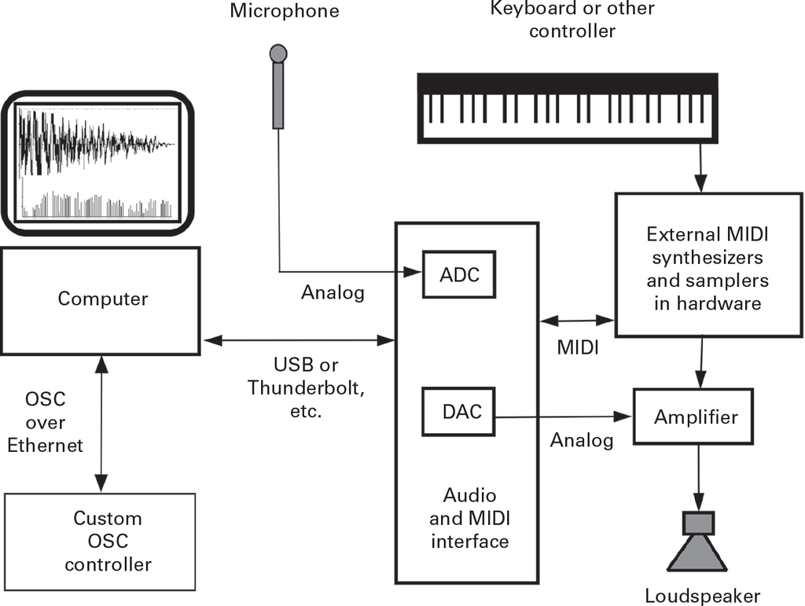

**图 8.10** 实时合成系统概览。

**Figure 8.10** Overview of a real-time synthesis system.

实时操作的显著优势在于，音乐家可以在听到声音的同时演奏音乐输入设备或控制器。手势控制可以提升演奏的表现力。此外，还可以快速探索和测试合成方法的参数空间。*音序器*和*乐谱编辑*器使录制和编辑演奏成为可能。第40章和第41章介绍了演奏控制器和演奏软件，第51章和第52章介绍了MIDI和OSC通信协议。

The obvious advantage of real-time operation is that musical input devices or controllers can be played by the musician as sound is heard. Gestural control leads to more expressive performances. Moreover, the parameter space of a synthesis method can be explored and tested rapidly. *Sequencers* and *score editors* make it possible to record and edit performances. Chapters 40 and 41 present performance controllers and performance software, and chapters 51 and 52 cover the MIDI and OSC communication protocols.

## **音频编程**

## **Audio Programming**

本节简要介绍音频编程。许多书籍都深入细致地介绍了音频编程。例如，*《音频编程手册》*（Boulanger 和 Lazzarini 2011）包含超过 3,000 页的文字和数千行代码。另有专门的书籍介绍每种音频编程语言（SuperCollider、Csound、Max、Pd、ChucK、FAUST 等）。Neukom 的教材（2013）使用了 Csound、Max、Mathematica、C/C ++和 Processing。另一个资源是 YouTube 上的“音频程序员”视频频道。

This section provides a brief orientation to audio programming. Many tomes address audio programming in depth and detail. For example, *The Audio Programming Book* (Boulanger and Lazzarini 2011) contains over 3,000 pages of text and thousands of lines of code. Specific books describe each audio programming language (SuperCollider, Csound, Max, Pd, ChucK, FAUST, etc.). Neukom’s text (2013) uses Csound, Max, Mathematica, C/C++, and Processing. Another resource is The Audio Programmer video channel on YouTube.

音频编程的一个关键要素是音频 I/O 的管理。像 SuperCollider 和 Max 这样的音乐专用环境可以自动处理这个问题。相比之下，在使用 C 或 C ++等语言编写代码时，程序员需要更多地负责确保音频样本的流畅传输，避免卡顿。幸运的是，libsndfile、Portaudio 和 JUCE 等音频库可以处理实时输入和输出的许多底层细节。在音频软件行业，ROLI 的 JUCE 受到许多专业开发人员的青睐（Jones 2020）。

A crucial element of audio programming is the management of audio I/O. Music-specific environments like SuperCollider and Max handle this automatically. By contrast, when coding in a language like C or C++, the programmer has more responsibility for ensuring the smooth stream of audio samples without stuttering. Fortunately, audio libraries such as libsndfile, Portaudio, and JUCE handle many of the low-level details of real-time input and output. In the audio software industry, ROLI’s JUCE is favored by many professional developers (Jones 2020).

实时合成每次生成一个样本*块*。典型的样本块大小范围从 32 个样本到 2,048 个样本。较大的缓冲区可以最大程度地防止故障，但会引入*延迟*：即从录制或合成声音到听到声音的延迟。实现低延迟音频的机制是*音频回调循环，*只要声音正在录制或合成，它就会重复执行。音频回调循环从合成器获取一个样本块，并将其放入内存缓冲区。通过将缓冲区的内容发送到实时输出，样本块即可播放。然而，合成或对样本块应用效果可能需要超过一个采样周期。此外，软件例程的处理速度并非恒定，因为它与可能随时启动的操作系统进程并发运行。因此，使用单输出缓冲区的方案容易出现音频丢失。因此，通常在音频回调循环中使用双*缓冲*或*四缓冲*方案。可以将一个包含 2,048 个样本的缓冲区分成两个或四个缓冲部分。一个缓冲区播放时，另一个缓冲区正在由合成算法填充新的样本。在某些情况下，缓冲可以由声音库自动管理。Maldonado（2011）将引导读者了解该过程的各个步骤。 AudioMulch 的开发者 Ross Bencina (2011) 警告了音频回调循环中存在的问题，并提供了避免音频故障的注意事项列表。图 8.11展示了一个用伪代码编写的音频回调循环示例。

Real-time synthesis generates a *block* of samples at a time. Typical block sizes range from 32 samples to 2,048 samples. Large buffers provide the most protection against glitches, but they introduce *latency*: a delay from the time that the sound is recorded or synthesized to the time that it is heard. The mechanism for implementing low-latency audio is the *audio callback loop,* which repeats as long as sound is being recorded or synthesized. The audio callback loop takes a block of samples from a synthesizer and puts them into a memory buffer. The block of samples plays by sending the contents of the buffer to the real-time output. However, synthesizing or applying effects to a block of samples may take longer than one sample period. Moreover, the processing speed of a software routine is not constant because it runs concurrently with operating system processes that can start at any time. Hence a scheme using a single output buffer is prone to audio dropouts. Thus it is common practice to use a *double-* or *quad-buffering* scheme in the audio callback loop. One might break a 2,048-sample buffer into two or four buffer sections. One buffer plays while the other buffer is being filled with new samples by the synthesis algorithm. In some cases buffering can be automatically managed by the sound library. Maldonado (2011) walks readers through the steps of the process. The developer of AudioMulch, Ross Bencina (2011) warns of problems in the audio callback loop and provides a list of do’s and don’ts to avoid audio glitches. Figure 8.11 shows an example of an audio callback loop written in pseudocode.

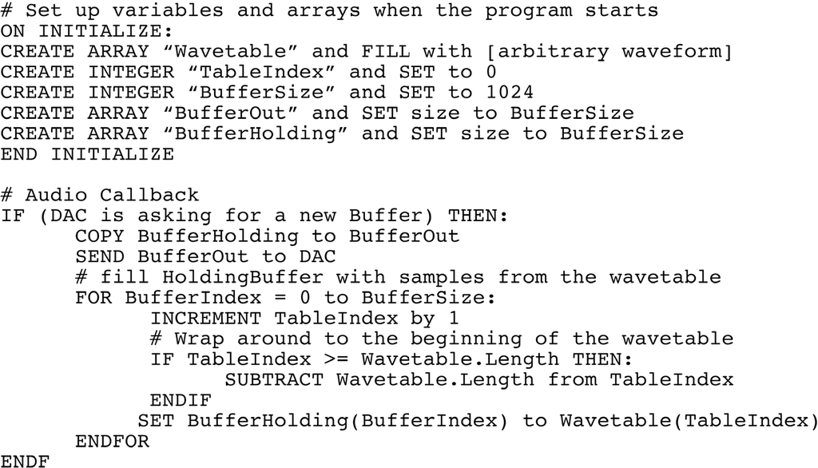

**图 8.11** 音频回调循环读取波表并将音频输出到 DAC。感谢 Rodney Duplessis 的贡献。

**Figure 8.11** Audio callback loop that reads a wavetable and outputs audio to the DAC. Credit to Rodney Duplessis.

Lazzarini (2011d) 展示了合成器引擎基本构建模块的C ++代码，包括插值振荡器、包络发生器、滤波器、延迟线、镶边器、卷积和音高转换器。该作者还编写了两卷本的《计算机乐器 I》和*《计算机乐器**II》*，其中包含 Python、Csound 和 Faust 的详细示例（Lazzarini 2017、2019）。

Lazzarini (2011d) presents the C++ code for the basic building blocks of a synthesizer engine: interpolating oscillators, envelope generators, filters, delay lines, flangers, convolution, and pitch shifters. The same author has written a two-volume set, *Computer Music Instruments I* and *II*, with detailed examples in Python, Csound, and Faust (Lazzarini 2017, 2019)

软件合成器的传播得益于插件标准。Steinberg 于 1996 年推出的虚拟工作室技术 (VST) 格式至今仍是广泛支持的协议。其他格式包括 Apple 的 Audio Units (AU) 和 Linux 的 LV2 等。有关开发音频插件的教程，请参阅 Goudard 和 Muller (2003)、Dobson (2011) 和 Pirkle (2019)。

The spread of software synthesizers has been fostered by plug-in standards. Steinberg’s Virtual Studio Technology (VST) format, introduced in 1996, continues as a broadly supported protocol. Other formats include Apple’s Audio Units (AU) and LV2 for Linux, among others. For tutorials on developing audio plugins, refer to Goudard and Muller (2003), Dobson (2011), and Pirkle (2019).